# Bibliometria aplicada à Agronomia com o pacote biblioIntegrator

Tutorial progressivo para doutorandos: da importação de bases à análise semântica com Python e LLM

Autor

Walter E. Pereira

Data de Publicação

22 de setembro de 2026

# 1 Apresentação

Este tutorial foi escrito para doutorandos em Agronomia que precisam transformar um acervo de publicações em evidência analisável. O problema de pesquisa típico é concreto: você tem uma pasta com exportações de Scopus, Web of Science e OpenAlex sobre silício e estresse salino, ou sobre carbono do solo e plantas de cobertura, e precisa dizer o que esse acervo mostra, com que confiança e com que rastro de auditoria. O `biblioIntegrator` organiza esse caminho em um objeto relacional único, ao qual se aplicam auditoria, deduplicação, estatística descritiva, inferência por permutação, redes, análise textual, armazenamento colunar, consultas por API, integração com Python e, opcionalmente, assistência por modelos de linguagem.

O percurso tem doze módulos. Cada um abre com um problema agronômico, apresenta os dados, executa o código comentado, mostra tabelas e figuras e fecha com a leitura dos resultados. Ao final de cada módulo há tarefas em três níveis, do reconhecimento à criação, e os gabaritos comentados aparecem em seção própria mais adiante. Duas convenções valem para todo o documento. A primeira é que nenhum número de resultado foi digitado no texto: todos são calculados no momento da renderização, de modo que, se você mudar a semente, o texto acompanha. A segunda é que as verdades plantadas nos dados simulados são verificadas pelo próprio documento, e não pressupostas.

# 2 Como usar este material

1. Instale o `biblioIntegrator` e carregue com `library(biblioIntegrator)`.
2. Execute os blocos na ordem. O bloco de preparação é obrigatório, porque cria os corpora usados em todos os módulos.
3. Em cada módulo, leia o contexto agronômico antes de rodar o código. A pergunta de pesquisa precede a função.
4. Resolva as tarefas do módulo antes de consultar o gabarito. Os gabaritos trazem código completo, leitura da saída, redação pronta para a seção de Resultados e os erros mais comuns.
5. O arquivo `exercicios-aluno.R` acompanha o tutorial com os códigos de simulação e os esqueletos das tarefas, sem respostas.
6. Os corpora usados são três: o didático do pacote, um simulado com defeitos e verdades plantadas, e um real obtido por API. O material indica sempre qual deles está em uso.

**NotaReprodutibilidade**

Todas as simulações usam a semente 2026. As chamadas de rede (OpenAlex e OpenCitations) são guardadas em `_cache/` na primeira execução, de modo que a segunda renderização do documento não depende de conexão.

# 3 Inventário do biblioIntegrator instalado

Antes de qualquer análise, vale saber exatamente com que instrumento se trabalha. O inventário abaixo é calculado no documento: ele confronta a lista de funções exportadas pela versão instalada com o mapa de módulos deste tutorial e acusa qualquer função que tenha ficado sem cobertura.

```r
plano_modulos <- list(
  "1. Arquitetura e importação"    = c("example_biblio", "as_biblio_project", "biblio_import", "backend_status"),
  "2. Qualidade e duplicatas"      = c("biblio_health", "deduplicate_biblio", "audit_biblio"),
  "3. Descritiva e impacto"        = c("describe_biblio", "biblio_metrics", "normalized_citations"),
  "4. Dinâmica temporal"           = c("temporal_growth", "citation_velocity", "citation_trajectory", "rpys", "disruption_index"),
  "5. Análise textual"             = c("term_frequency", "tfidf_terms", "trend_topics"),
  "6. Comparação de grupos"        = c("form_groups", "compare_groups", "association_residuals", "group_ca", "group_mca", "sensitivity_analysis", "compare_sources"),
  "7. Redes bibliográficas"        = c("bibliographic_network", "network_centrality", "network_communities", "network_stability", "export_vosviewer"),
  "8. Escala: Arrow e DuckDB"      = c("biblio_store", "biblio_load", "biblio_query"),
  "9. APIs abertas"                = c("fetch_openalex", "fetch_opencitations"),
  "10. Python e Biblium"           = c("python_backend_status", "biblium_backend_status", "enable_python_backend", "install_biblium_backend", "to_biblium", "biblium_compare_groups", "validate_biblium"),
  "11. Modelos de linguagem"       = c("llm_configure", "llm_get_config", "llm_status", "semantic_search", "llm_topic_discovery", "llm_summarize", "llm_gap_analysis", "llm_query_expand", "llm_classify", "llm_citation_context"),
  "12. Fluxo, relatório e app"     = c("form_plan", "validate_plan", "run_plan", "biblio_report", "biblio_app", "export_biblio", "to_bibliometrix")
)
funcoes_mapeadas <- unlist(plano_modulos, use.names = FALSE)
exportadas <- sort(getNamespaceExports("biblioIntegrator"))
inventario <- do.call(rbind, lapply(names(plano_modulos), function(m) {
  f <- plano_modulos[[m]]
  data.frame(modulo = m, funcao = f,
             argumentos = vapply(f, function(g)
               paste(names(formals(getExportedValue("biblioIntegrator", g))), collapse = ", "),
               character(1), USE.NAMES = FALSE),
             stringsAsFactors = FALSE)
}))
sem_modulo <- setdiff(exportadas, funcoes_mapeadas)
inexistentes <- setdiff(funcoes_mapeadas, exportadas)
knitr::kable(inventario, row.names = FALSE)
```

Tabela 1: Inventário das funções exportadas pelo biblioIntegrator instalado e o módulo do tutorial que as apresenta.

| modulo | funcao | argumentos |
| --- | --- | --- |
| 1. Arquitetura e importação | example_biblio |  |
| 1. Arquitetura e importação | as_biblio_project | x, source |
| 1. Arquitetura e importação | biblio_import | path, dbsource, format |
| 1. Arquitetura e importação | backend_status |  |
| 2. Qualidade e duplicatas | biblio_health | x |
| 2. Qualidade e duplicatas | deduplicate_biblio | x, method |
| 2. Qualidade e duplicatas | audit_biblio | x |
| 3. Descritiva e impacto | describe_biblio | x |
| 3. Descritiva e impacto | biblio_metrics | x |
| 3. Descritiva e impacto | normalized_citations | x, strata |
| 4. Dinâmica temporal | temporal_growth | x |
| 4. Dinâmica temporal | citation_velocity | x, current_year |
| 4. Dinâmica temporal | citation_trajectory | x, current_year |
| 4. Dinâmica temporal | rpys | reference_years, window |
| 4. Dinâmica temporal | disruption_index | focal_id, citation_edges, focal_references |
| 5. Análise textual | term_frequency | x, field, stopwords |
| 5. Análise textual | tfidf_terms | x, group, field |
| 5. Análise textual | trend_topics | x, min_total |
| 6. Comparação de grupos | form_groups | x, groups |
| 6. Comparação de grupos | compare_groups | x, groups, entity, permutations, bootstrap, seed, engine |
| 6. Comparação de grupos | association_residuals | x, min_abs |
| 6. Comparação de grupos | group_ca | x, ndim |
| 6. Comparação de grupos | group_mca | x, groups, entity, ncp |
| 6. Comparação de grupos | sensitivity_analysis | x, groups, thresholds, entity, permutations, seed |
| 6. Comparação de grupos | compare_sources | … |
| 7. Redes bibliográficas | bibliographic_network | x, type, engine, min_weight, counting |
| 7. Redes bibliográficas | network_centrality | graph |
| 7. Redes bibliográficas | network_communities | graph, method |
| 7. Redes bibliográficas | network_stability | x, type, B, fraction, seed |
| 7. Redes bibliográficas | export_vosviewer | graph, path |
| 8. Escala: Arrow e DuckDB | biblio_store | x, path, engine, overwrite |
| 8. Escala: Arrow e DuckDB | biblio_load | path, engine |
| 8. Escala: Arrow e DuckDB | biblio_query | path, sql |
| 9. APIs abertas | fetch_openalex | query, n, mailto |
| 9. APIs abertas | fetch_opencitations | identifier, direction |
| 10. Python e Biblium | python_backend_status | python |
| 10. Python e Biblium | biblium_backend_status | python |
| 10. Python e Biblium | enable_python_backend | python |
| 10. Python e Biblium | install_biblium_backend | envname, python, version |
| 10. Python e Biblium | to_biblium | x |
| 10. Python e Biblium | biblium_compare_groups | x, groups, entity, permutations, seed, python |
| 10. Python e Biblium | validate_biblium | x, groups, entity, permutations, seed |
| 11. Modelos de linguagem | llm_configure | provider, api_key, model, base_url, temperature, max_tokens |
| 11. Modelos de linguagem | llm_get_config |  |
| 11. Modelos de linguagem | llm_status | provider, verbose |
| 11. Modelos de linguagem | semantic_search | x, query, n, provider, model, api_key |
| 11. Modelos de linguagem | llm_topic_discovery | x, n_topics, provider, model |
| 11. Modelos de linguagem | llm_summarize | x, work_ids, style, provider, model |
| 11. Modelos de linguagem | llm_gap_analysis | x, focus, provider, model |
| 11. Modelos de linguagem | llm_query_expand | query, database, provider, model |
| 11. Modelos de linguagem | llm_classify | x, categories, provider, model |
| 11. Modelos de linguagem | llm_citation_context | x, text, provider, model |
| 12. Fluxo, relatório e app | form_plan | source, analyses, network, group, report, seed |
| 12. Fluxo, relatório e app | validate_plan | plan |
| 12. Fluxo, relatório e app | run_plan | plan, data |
| 12. Fluxo, relatório e app | biblio_report | x, output_file, format, title |
| 12. Fluxo, relatório e app | biblio_app | data |
| 12. Fluxo, relatório e app | export_biblio | x, path, format |
| 12. Fluxo, relatório e app | to_bibliometrix | x |

O inventário cobre 59 funções distribuídas em 12 módulos, contra 59 funções exportadas pela versão instalada. Funções exportadas ainda sem módulo: nenhuma. Nomes do mapa que não existem nesta versão: nenhum.

```r
vers <- data.frame(
  componente = c("R", "biblioIntegrator", "ggplot2", "igraph", "arrow", "duckdb",
                 "reticulate", "testthat"),
  versao = c(paste(R.version$major, R.version$minor, sep = "."),
             as.character(packageVersion("biblioIntegrator")),
             as.character(packageVersion("ggplot2")),
             as.character(packageVersion("igraph")),
             if (requireNamespace("arrow", quietly = TRUE)) as.character(packageVersion("arrow")) else "ausente",
             if (requireNamespace("duckdb", quietly = TRUE)) as.character(packageVersion("duckdb")) else "ausente",
             if (requireNamespace("reticulate", quietly = TRUE)) as.character(packageVersion("reticulate")) else "ausente",
             if (requireNamespace("testthat", quietly = TRUE)) as.character(packageVersion("testthat")) else "ausente"),
  stringsAsFactors = FALSE)
knitr::kable(vers, row.names = FALSE)
```

Tabela 2: Versões do ambiente e disponibilidade dos componentes opcionais.

| componente | versao |
| --- | --- |
| R | 4.6.0 |
| biblioIntegrator | 0.3.0 |
| ggplot2 | 4.0.3 |
| igraph | 2.3.3 |
| arrow | 25.0.1 |
| duckdb | 1.5.5 |
| reticulate | 1.47.0 |
| testthat | 3.3.2 |

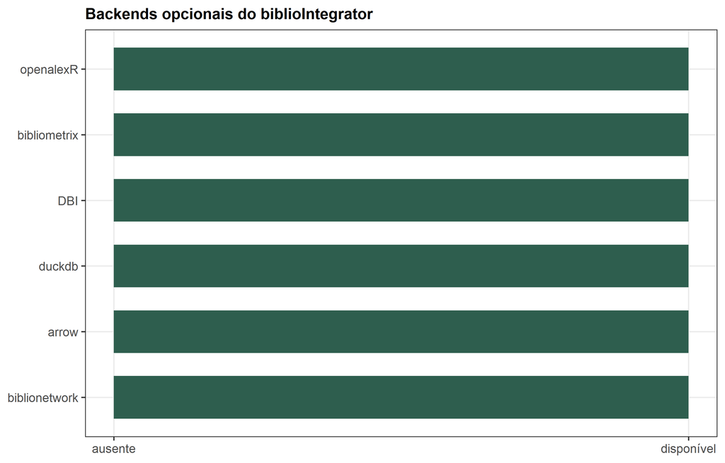

Figura 1: Disponibilidade dos backends opcionais detectados em tempo de execução.

```r
bs <- backend_status()
bs$backend <- factor(bs$backend, levels = bs$backend[order(bs$available)])
ggplot(bs, aes(x = backend, y = as.integer(available), fill = available)) +
  geom_col(width = .65) +
  scale_fill_manual(values = c(`TRUE` = pal_agri[1], `FALSE` = "#C0392B"),
                    guide = "none") +
  scale_y_continuous(breaks = c(0, 1), labels = c("ausente", "disponível")) +
  coord_flip() +
  labs(x = NULL, y = NULL, title = "Backends opcionais do biblioIntegrator")
```

A Figura 1 mostra o que está instalado nesta máquina. A leitura é operacional: cada backend ausente desliga um caminho do tutorial, nunca o documento inteiro, porque a arquitetura do pacote trata todo motor opcional como detectado em tempo de execução. Dos 6 backends verificados, 6 estão disponíveis.

# 4 Os três corpora do tutorial

## 4.1 Corpus A: acervo didático do pacote

O `example_biblio()` traz doze obras de agronomia com título, ano, DOI, autoria, palavras-chave, citações e fonte. É o acervo de partida: pequeno o bastante para inspecionar linha a linha e suficientemente realista para todas as funções.

## 4.2 Corpus B: acervo simulado com verdades plantadas

O acervo principal é simulado com semente fixa e comporta sete verdades que o tutorial verifica. Ele representa um levantamento sobre agricultura tropical entre 2010 e 2025, com 280 obras em três frentes de pesquisa: silício e estresse abiótico, carbono do solo e plantas de cobertura, e sensoriamento remoto com aprendizado de máquina.

| Verdade | O que foi plantado | Onde é verificada |
| --- | --- | --- |
| V1 | três temas latentes com pesos desiguais | Módulos 5 e 6 |
| V2 | duas fontes com bônus de 12 citações por obra | Módulo 3 |
| V3 | metade das obras com coautoria internacional | Módulos 3 e 7 |
| V4 | termos de aprendizado de máquina e VANT concentrados a partir de 2020 | Módulos 4 e 6 |
| V5 | um autor central que articula a rede | Módulo 7 |
| V6 | três duplicatas plantadas e defeitos de metadados | Módulo 2 |
| V7 | três laboratórios com padrão de coautoria próprio | Módulo 7 |

```r
set.seed(SEED)
nB <- 280L
temas <- list(
  silicio = list(tit = "Silício e tolerância a estresse abiótico",
                 kw = c("silicon","salinity","drought stress","rice","sorghum",
                        "nutrient uptake","abiotic stress","silicon fertilization")),
  carbono = list(tit = "Carbono do solo e plantas de cobertura",
                 kw = c("soil carbon","cover crops","no-till","soil organic matter",
                        "carbon sequestration","soil aggregation","crop rotation",
                        "green manure")),
  remoto  = list(tit = "Sensoriamento remoto e fenotipagem de culturas",
                 kw = c("remote sensing","UAV","machine learning","hyperspectral",
                        "yield prediction","vegetation index","phenotyping",
                        "deep learning")))
tema_lat <- sample(c("silicio","carbono","remoto"), nB, replace = TRUE,
                   prob = c(.45, .35, .20))
fontes_bonus <- c("Field Crops Research", "Soil Biology & Biochemistry")
fontes <- c(fontes_bonus, "Agronomy Journal", "Plant and Soil",
            "Precision Agriculture", "Pesquisa Agropecuária Brasileira",
            "Revista Brasileira de Ciência do Solo", "Scientia Agricola",
            "Soil & Tillage Research", "Remote Sensing")
int_lab <- c("Smith J","Chen L","Müller H","Rossi G")
lab_S <- c("Silva AP","Costa JR","Pereira WE","Martins LC")
lab_C <- c("Souza RM","Oliveira TN","Almeida FB")
lab_R <- c("Rocha MV","Lima DH","Barbosa KS","Nunes PR","Castro ES")
lab_de <- list(silicio = lab_S, carbono = lab_C, remoto = lab_R)
cultura <- c("arroz","milho","soja","sorgo","feijão","trigo","pastagem")
termos_ia <- c("machine learning","deep learning","UAV","hyperspectral")
ano <- sample(2010:2025, nB, replace = TRUE,
              prob = c(2,2,3,3,4,4,5,5,6,7,8,9,10,11,12,9))
fonte_i <- sample(fontes, nB, replace = TRUE,
                  prob = c(12,11,10,10,9,9,10,10,9,10)/100)
kw_list <- lapply(seq_len(nB), function(i) {
  base <- sample(temas[[tema_lat[i]]]$kw, 4L)
  if (ano[i] >= 2020 && runif(1) < .78) base <- c(base, sample(termos_ia, 1L))
  paste(unique(base), collapse = "; ")
})
authors_list <- lapply(seq_len(nB), function(i) {
  meu <- lab_de[[tema_lat[i]]]
  outros <- unlist(lab_de[setdiff(names(lab_de), tema_lat[i])])
  pool <- if (runif(1) < .88) meu else outros
  br <- sample(pool, min(length(pool), sample(1:3, 1)))
  if (i <= 40L || (tema_lat[i] == "silicio" && runif(1) < .60))
    br <- unique(c("Silva AP", br))
  if (runif(1) < .50) br <- c(br, sample(int_lab, sample(1:2, 1)))
  paste(br, collapse = "; ")
})
cit <- pmax(0L, round(exp(rnorm(nB, 1.9, .9)) - 1)) +
  ifelse(fonte_i %in% fontes_bonus, 12L, 0L)
dB <- data.frame(
  title = sprintf("%s em %s (estudo %03d)",
                  vapply(tema_lat, function(t) temas[[t]]$tit, character(1)),
                  sample(cultura, nB, replace = TRUE), seq_len(nB)),
  year = ano, doi = paste0("10.1016/j.agri.2024.", sprintf("%05d", seq_len(nB))),
  authors = unlist(authors_list), keywords = unlist(kw_list),
  citations = cit, source = fonte_i, stringsAsFactors = FALSE)
dB$doi[5] <- "  HTTPS://DOI.ORG/10.1016/j.agri.2024.00005  "
dB$doi[9] <- "doi:10.1016/j.agri.2024.00009"
dB$year[14] <- NA_integer_
dB$citations[21] <- -3L
dB$title[33] <- "   "
dB$doi[47] <- NA_character_
dB$tema <- tema_lat
dB <- rbind(dB, dB[1, ])
dB <- rbind(dB, transform(dB[2, ], doi = NA_character_))
dB <- rbind(dB, transform(dB[3, ], doi = "https://doi.org/10.1016/j.agri.2024.00003"))
x_bruto <- as_biblio_project(dB, source = "corpus B bruto")
x_limpo <- deduplicate_biblio(x_bruto, method = "doi_title_year")
# recorte analítico: parte do acervo JÁ deduplicado e exclui a obra sem ano,
# porque agrupamentos por período exigem ano conhecido (ver Módulo 2)
ids_ok <- x_limpo$works$work_id[!is.na(x_limpo$works$year)]
x_analise <- x_limpo
x_analise$works <- x_limpo$works[x_limpo$works$work_id %in% ids_ok, , drop = FALSE]
x_analise$authorships <- x_limpo$authorships[x_limpo$authorships$work_id %in% ids_ok, , drop = FALSE]
x_analise$keywords <- x_limpo$keywords[x_limpo$keywords$work_id %in% ids_ok, , drop = FALSE]
n_dup_auto <- nrow(x_bruto$works) - nrow(x_limpo$works)
n_sem_ano <- nrow(x_limpo$works) - nrow(x_analise$works)
# grupos prontos para os módulos 6 e 7. A coluna auxiliar `tema` do quadro plano
# não sobrevive à harmonização (as_biblio_project preserva apenas os campos
# canônicos), então o tema é derivado do título, como faria um usuário
tema_de_titulo <- function(t) {
  ifelse(grepl("^Silício", t), "silicio",
         ifelse(grepl("^Carbono", t), "carbono", "remoto"))
}
tema_B <- tema_de_titulo(x_analise$works$title)
per_B  <- ifelse(x_analise$works$year >= 2020, "2020-2025", "2010-2019")
g_per  <- form_groups(x_analise, per_B)
g_tema <- form_groups(x_analise, tema_B)
x_analise$works$periodo <- per_B
```

O acervo bruto tem 283 registros, porque as três duplicatas plantadas foram acrescentadas às 280 obras originais. A deduplicação automática removeu 2 delas e o recorte analítico excluiu ainda 1 obra sem ano, chegando a 280 obras. A duplicata que sobreviveu à rotina automática é justamente a que não tem DOI, e o Módulo 2 explica por quê.

## 4.3 Corpus C: acervo real obtido por API

O terceiro acervo é obtido em tempo de execução do OpenAlex, sobre um tema agronômico concreto. Ele mostra que o mesmo encadeamento analítico vale para dados que você não simulou.

```r
x_openalex <- cache_rds("openalex_silicio",
                        fetch_openalex("silicon salinity rice", n = 40L))
tem_C <- inherits(x_openalex, "biblio_project")
if (tem_C) {
  knitr::kable(head(x_openalex$works[, c("title","year","source","cited_by_count")], 5),
               caption = "Primeiras obras do acervo real do OpenAlex sobre silício e salinidade em arroz.")
} else {
  cat("Chamada de rede indisponível nesta renderização:", x_openalex, "\n")
}
```

Primeiras obras do acervo real do OpenAlex sobre silício e salinidade em arroz.

| title | year | source | cited_by_count |
| --- | --- | --- | --- |
| Silicon reduces sodium uptake in rice ( Oryza sativa L.) in saline conditions and this is accounted for by a reduction in the transpirational bypass flow | 1999 | Plant Cell & Environment | 398 |
| Silicon Application to Rice Root Zone Influenced the Phytohormonal and Antioxidant Responses Under Salinity Stress | 2013 | Journal of Plant Growth Regulation | 256 |
| Silicon decreases chloride transport in rice (Oryza sativa L.) in saline conditions | 2013 | Journal of Plant Physiology | 151 |
| The combined use of silicon and arbuscular mycorrhizas to mitigate salinity and drought stress in rice | 2022 | Environmental and Experimental Botany | 90 |
| Influence of Nano Silicon and Nano Selenium on Root Characters, Growth, Ion Selectivity, Yield, and Yield Components of Rice (Oryza sativa L.) under Salinity Conditions | 2021 | Plants | 179 |

# 5 Módulo 1. Arquitetura relacional e importação

## 5.1 O problema agronômico

Uma equipe de fertilidade do solo exporta 280 referências de três bases diferentes. Cada base nomeia as colunas de um jeito: uma chama o periódico de `source`, outra de `journal`, outra de `so_title`; uma grava o DOI com prefixo completo, outra só o sufixo. Se cada análise começar de um formato próprio, cada nova base exigirá reescrever todo o código. A solução do `biblioIntegrator` é harmonizar tudo em um objeto relacional único, o `biblio_project`, com seis tabelas ligadas por identificadores.

## 5.2 Do quadro plano ao objeto relacional

```r
x_did <- as_biblio_project(example_biblio(), source = "acervo didático")
estrutura <- data.frame(
  tabela = c("works","authorships","authors","keywords","references","provenance"),
  conteudo = c("uma linha por obra","ligação obra-autor","autores únicos",
               "palavras-chave normalizadas","arestas de citação","trilha de operações"),
  linhas_didatico = vapply(x_did, nrow, integer(1)),
  linhas_analitico = vapply(x_analise, nrow, integer(1)),
  stringsAsFactors = FALSE)
knitr::kable(estrutura, row.names = FALSE,
             caption = "As seis tabelas do biblio_project e o tamanho de cada uma nos dois acervos.")
```

Tabela 3: As seis tabelas do biblio_project e o tamanho de cada uma nos dois acervos.

| tabela | conteudo | linhas_didatico | linhas_analitico |
| --- | --- | --- | --- |
| works | uma linha por obra | 12 | 280 |
| authorships | ligação obra-autor | 24 | 853 |
| authors | autores únicos | 7 | 16 |
| keywords | palavras-chave normalizadas | 32 | 1228 |
| references | arestas de citação | 0 | 0 |
| provenance | trilha de operações | 1 | 2 |

A Tabela acima é a planta da casa. `works` guarda o documento; `authorships` liga documento e autor, o que permite contar produção por autor sem repetir linhas de documento; `keywords` normaliza os termos em minúsculas; `provenance` registra cada operação aplicada. A coluna `linhas_analitico` mostra que o acervo analítico tem 280 obras, 853 ligações de autoria e 1228 pares obra-termo.

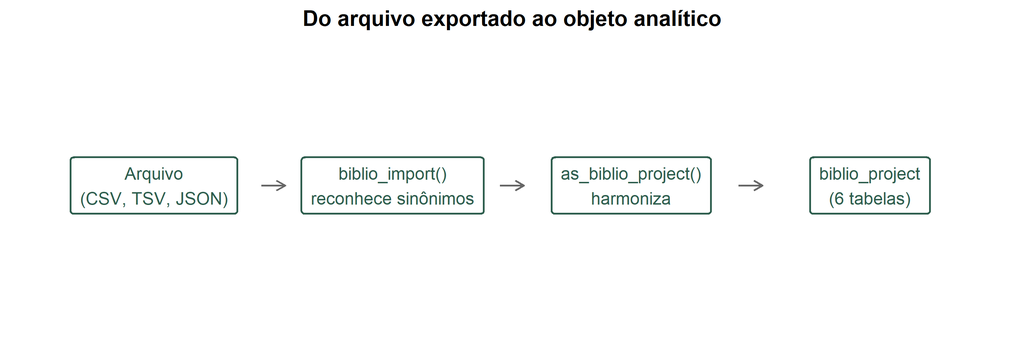

Figura 2: Caminho de importação: o quadro plano é lido, as colunas são reconhecidas por sinônimos e o resultado é o projeto relacional.

```r
csv_did <- file.path(tempdir(), "acervo_agronomia.csv")
write.csv(head(example_biblio(), 6L), csv_did, row.names = FALSE)
x_importado <- biblio_import(csv_did)
etapas <- c("Arquivo\n(CSV, TSV, JSON)", "biblio_import()\nreconhece sinônimos",
            "as_biblio_project()\nharmoniza", "biblio_project\n(6 tabelas)")
graf <- data.frame(etapa = factor(etapas, levels = etapas), x = 1:4)
ggplot(graf, aes(x = x, y = 1)) +
  geom_label(aes(label = etapa), fill = "white", colour = pal_agri[1],
             linewidth = .5, size = 3.1, label.padding = unit(.45, "lines")) +
  geom_segment(data = data.frame(x = 1:3, xe = 2:4),
               aes(x = x + .45, xend = xe - .45, y = 1, yend = 1),
               arrow = arrow(length = unit(.18, "cm")), colour = "grey40") +
  scale_x_continuous(limits = c(.55, 4.45)) + ylim(.85, 1.15) +
  labs(x = NULL, y = NULL, title = "Do arquivo exportado ao objeto analítico") +
  theme_void(base_size = 10) +
  theme(plot.title = element_text(face = "bold", hjust = .5, size = 11))
```

A Figura 2 resume o módulo inteiro. A leitura prática é que a etapa de harmonização é o único ponto em que nomes de coluna importam; a partir do `biblio_project`, todas as funções falam a mesma língua. O arquivo importado nesta execução produziu 6 obras, o mesmo número de linhas do CSV de entrada.

```r
knitr::kable(head(x_did$works[, c("work_id","title","year","doi","cited_by_count")], 4),
             caption = "As quatro primeiras linhas da tabela works do acervo didático.")
```

Tabela 4: As quatro primeiras linhas da tabela works do acervo didático.

| work_id | title | year | doi | cited_by_count |
| --- | --- | --- | --- | --- |
| W0001f7e3 | Silicon and salinity tolerance in rice | 2018 | 10.1000/agri.1 | 42 |
| W000160f5 | Soil carbon under cover crops | 2019 | 10.1000/agri.2 | 35 |
| W0001b6e0 | Remote sensing of soybean nitrogen | 2020 | 10.1000/agri.3 | 28 |
| W0001b6e2 | Silicon nutrition in maize drought | 2021 | 10.1000/agri.4 | 31 |

Os identificadores `work_id` são derivados do DOI quando ele existe e do título com ano quando não existe, o que garante chave estável mesmo com metadados incompletos. É essa chave que sustenta a deduplicação do módulo seguinte.

## 5.3 Tarefas do Módulo 1

**Tarefa 1.1 (aplicar).** Importe o arquivo `acervo_agronomia.csv` gerado acima com `biblio_import()`, harmonize com `as_biblio_project()` usando `source = "minha base"` e informe quantas obras, autores e termos o projeto tem.

**Tarefa 1.2 (analisar).** Rode `biblio_health()` sobre o acervo didático e explique, em duas frases, por que o diagnóstico não encontra problema algum mesmo com um acervo tão pequeno.

**DicaAntes de seguir**

Se você não sabe qual backend opcional está instalado na sua máquina, rode `backend_status()`. A saída é uma tabela com uma linha por backend e um indicador lógico de disponibilidade, sem interromper a sessão.

# 6 Módulo 2. Qualidade, duplicatas e proveniência

## 6.1 O problema agronômico

A busca sistemática da sua tese sobre silício e estresse salino em arroz rodou em três bases e voltou com 283 registros para um conjunto de estudos que você sabe ser menor. A diferença não é contabilidade: cada registro a mais conta duas vezes na produção anual, entra duas vezes no conjunto que alimenta a meta-análise do efeito do silício na condutividade elétrica do extrato saturado e infla o painel de autores que você vai defender na qualificação.

Bases bibliográficas exportam metadados que ninguém revisou antes de você. Um registro chega sem título porque a exportação cortou o campo, outro chega sem ano porque a base não resolveu a data, outro ainda traz contagem de citações negativa, resultado de correções internas aplicadas sobre um número já publicado. Nenhum desses defeitos salta aos olhos quando se abre o arquivo e se rola até o fim; todos aparecem quando se procura por eles com um critério explícito. O custo de não procurar é uma tabela de resultados que a banca refaz em dez minutos e não consegue reproduzir.

Este módulo cobre a etapa que precede qualquer análise. A pergunta que ele responde não é quantos registros existem, mas quais defeitos os metadados têm, quais deles uma rotina automática corrige sem julgamento e quais exigem uma decisão do pesquisador, registrada e defensável. A fronteira entre corrigir e decidir é o que separa um acervo auditável de uma planilha apenas organizada. O acervo de trabalho é o `x_bruto`, o corpus simulado de 283 registros que o documento montou a partir de 280 obras, com três duplicatas plantadas e defeitos de metadados distribuídos de propósito.

## 6.2 O diagnóstico antes da análise

```r
# diagnóstico dos dois estados do acervo: bruto e já deduplicado
h_bruto <- biblio_health(x_bruto)
h_limpo <- biblio_health(x_limpo)

# a tabela coloca os dois diagnósticos lado a lado e mede o que a rotina resolveu
diag <- data.frame(
  defeito   = h_bruto$check,
  bruto     = h_bruto$n,
  pos_dedup = h_limpo$n,
  stringsAsFactors = FALSE)
diag$resolvido <- diag$bruto - diag$pos_dedup
knitr::kable(
  diag, row.names = FALSE,
  col.names = c("defeito", "acervo bruto", "após deduplicação", "resolvido pela rotina"),
  caption = "Defeitos de metadados acusados pelo diagnóstico no acervo bruto e depois da deduplicação automática.")
```

Tabela 5: Defeitos de metadados acusados pelo diagnóstico no acervo bruto e depois da deduplicação automática.

Defeitos de metadados acusados pelo diagnóstico no acervo bruto e depois da deduplicação automática.

| defeito | acervo bruto | após deduplicação | resolvido pela rotina |
| --- | --- | --- | --- |
| missing_title | 1 | 1 | 0 |
| missing_year | 1 | 1 | 0 |
| missing_doi | 2 | 2 | 0 |
| duplicate_doi | 2 | 0 | 2 |
| duplicate_title_year | 3 | 1 | 2 |
| negative_citations | 1 | 1 | 0 |

A leitura dessa tabela é a chave do módulo, e ela tem três partes. A primeira é que o diagnóstico acusa 10 ocorrências de defeito, e nenhuma das seis verificações devolve zero: o defeito mais frequente é o par título-ano repetido, com 3 ocorrências. A segunda é que a rotina automática resolve 4 desses casos — apenas o que decorre da duplicação — e deixa intactos o título em branco, o ano ausente, os dois DOIs vazios e a citação negativa, porque nenhum deles é duplicação. A terceira é a mais importante: entre o diagnóstico e a rotina existe uma sobra. Depois de deduplicar, o acervo ainda tem 1 par de título e ano repetido, o que significa que os dois instrumentos discordam sobre o mesmo acervo. Localizar essa discordância é o objetivo do restante do módulo.

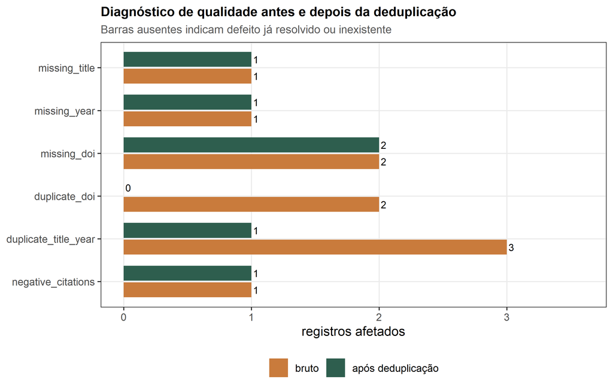

Figura 3: Registros afetados por tipo de defeito no acervo bruto e depois da deduplicação automática.

```r
# formato longo: uma linha por combinação de defeito e etapa, exigido pelo ggplot2
d_long <- rbind(
  data.frame(defeito = h_bruto$check, etapa = "bruto", n = h_bruto$n),
  data.frame(defeito = h_limpo$check, etapa = "após deduplicação", n = h_limpo$n))
d_long$defeito <- factor(d_long$defeito, levels = rev(h_bruto$check))
d_long$etapa <- factor(d_long$etapa, levels = c("bruto", "após deduplicação"))

ggplot(d_long, aes(x = defeito, y = n, fill = etapa)) +
  geom_col(position = position_dodge(width = .78), width = .7) +
  geom_text(aes(label = n), position = position_dodge(width = .78),
            hjust = -.3, size = 3) +
  scale_fill_manual(values = c("bruto" = pal_agri[2], "após deduplicação" = pal_agri[1])) +
  scale_y_continuous(limits = c(0, max(d_long$n) * 1.2)) +
  coord_flip() +
  labs(x = NULL, y = "registros afetados", fill = NULL,
       title = "Diagnóstico de qualidade antes e depois da deduplicação",
       subtitle = "Barras ausentes indicam defeito já resolvido ou inexistente")
```

A figura mostra quais barras desaparecem e quais permanecem. O que desaparece é exatamente o que a duplicação explicava: o DOI repetido cai de 2 para 0, e o par título-ano cai de 3 para 1. O que permanece são os defeitos de campo, que nenhuma deduplicação toca. A consequência prática é imediata: relatar apenas a queda do DOI repetido a zero, como se o acervo estivesse limpo, é uma leitura incorreta do próprio diagnóstico que você acabou de rodar. O acervo melhorou, mas não ficou íntegro, e a barra que não desapareceu é a que precisa de decisão humana.

## 6.3 A deduplicação automática e o que ela resolve

```r
# repetir a chamada aqui deixa a operação visível e confere que ela é determinística
x_dedup <- deduplicate_biblio(x_bruto, method = "doi_title_year")
m2_reproduz <- identical(x_dedup$works$work_id, x_limpo$works$work_id)

# o log de removidos fica preso ao objeto como atributo
log_rem <- attr(x_limpo, "dedup_log")
knitr::kable(
  log_rem, row.names = FALSE,
  caption = "Registros removidos pela deduplicação automática, com o identificador, o título e o DOI de cada um.")
```

Tabela 6: Registros removidos pela deduplicação automática, com o identificador, o título e o DOI de cada um.

Registros removidos pela deduplicação automática, com o identificador, o título e o DOI de cada um.

| work_id | title | doi |
| --- | --- | --- |
| W000474d7 | Carbono do solo e plantas de cobertura em milho (estudo 001) | 10.1016/j.agri.2024.00001 |
| W0004d133 | Silício e tolerância a estresse abiótico em trigo (estudo 003) | 10.1016/j.agri.2024.00003 |

O log de removidos é a peça que torna a operação auditável, e ele responde à pergunta que todo revisor faz: o que exatamente saiu? Saíram 2 registros, ambos com DOI preenchido, e os títulos das obras 001 e 003 aparecem duas vezes no bruto porque o mesmo trabalho foi exportado por bases diferentes. A chamada feita aqui reproduz o acervo do documento? TRUE. Essa reprodutibilidade importa para o artigo: se o revisor rodar o mesmo código na mesma versão do pacote, ele obtém a mesma lista de removidos, porque a chave de comparação é determinística e não depende da ordem das linhas nem de sorteio. O que a rotina não entrega, e não tem como entregar, é o julgamento sobre o que fazer quando dois registros descrevem a mesma obra sem compartilhar a mesma chave.

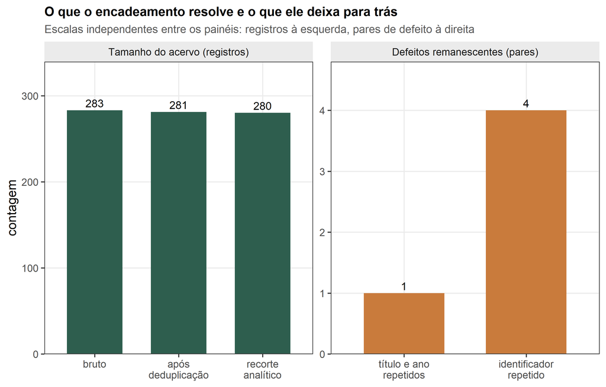

Figura 4: À esquerda, o tamanho do acervo em cada etapa do encadeamento; à direita, os defeitos que sobrevivem ao encadeamento, em número de pares.

```r
# painel 1: tamanho do acervo etapa por etapa, sempre por contagem de linhas
m2_painel1 <- data.frame(
  painel = "Tamanho do acervo (registros)",
  etapa  = c("bruto", "após\ndeduplicação", "recorte\nanalítico"),
  n      = c(nrow(x_bruto$works), nrow(x_limpo$works), nrow(x_analise$works)))

# painel 2: defeitos que o encadeamento acima não resolveu, contados em pares
m2_alvo <- paste(tolower(trimws(x_limpo$works$title)), x_limpo$works$year)
m2_painel2 <- data.frame(
  painel = "Defeitos remanescentes (pares)",
  etapa  = c("título e ano\nrepetidos", "identificador\nrepetido"),
  n      = c(sum(duplicated(m2_alvo)),
             sum(table(x_analise$works$work_id) > 1)))

m2_funil <- rbind(m2_painel1, m2_painel2)
m2_funil$etapa <- factor(m2_funil$etapa, levels = m2_funil$etapa)
m2_funil$painel <- factor(m2_funil$painel, levels = unique(m2_funil$painel))

ggplot(m2_funil, aes(x = etapa, y = n, fill = painel)) +
  geom_col(width = .66) +
  geom_text(aes(label = n), vjust = -.4, size = 3.3) +
  facet_wrap(~ painel, scales = "free", ncol = 2) +
  scale_fill_manual(values = pal_agri[c(1, 2)], guide = "none") +
  scale_y_continuous(expand = expansion(mult = c(0, .2))) +
  labs(x = NULL, y = "contagem",
       title = "O que o encadeamento resolve e o que ele deixa para trás",
       subtitle = "Escalas independentes entre os painéis: registros à esquerda, pares de defeito à direita")
```

A figura é o resumo operacional do módulo e precisa ser lida em dois tempos. O painel da esquerda é o funil: o acervo entra com 283 registros, perde 2 na deduplicação e perde mais 1 no recorte analítico, chegando a 280 obras com ano conhecido. O painel da direita é o que costuma ser omitido em relatos de bibliometria: mesmo depois de todo o encadeamento, permanecem um par de título e ano repetidos e 4 identificadores repetidos. Os dois painéis usam escalas independentes de propósito, porque comparar a contagem de registros com a contagem de pares de defeito no mesmo eixo tornaria o defeito invisível — e o defeito invisível é justamente o que volta como pergunta na defesa.

## 6.4 A terceira duplicata sobrevive à rotina

```r
# a chave de comparação da rotina, reproduzida aqui como está documentada no pacote
chave_dedup <- function(titulo, ano, doi) {
  ifelse(nzchar(doi),
         paste0("doi:", doi),
         paste0("ty:", tolower(gsub("[^[:alnum:]]", "", titulo)), ":", ano))
}

# o diagnóstico procura título igual no mesmo ano; aqui isolamos o par que restou
m2_w <- x_limpo$works
m2_alvo_w <- paste(tolower(trimws(m2_w$title)), m2_w$year)
m2_par <- m2_w[duplicated(m2_alvo_w) | duplicated(m2_alvo_w, fromLast = TRUE), ]
m2_par$chave <- chave_dedup(m2_par$title, m2_par$year, m2_par$doi)

knitr::kable(
  m2_par[, c("work_id", "title", "year", "doi", "chave", "cited_by_count")],
  row.names = FALSE,
  col.names = c("identificador", "título", "ano", "DOI", "chave usada na deduplicação", "citações"),
  caption = "O par que sobrevive à deduplicação automática: duas linhas com o mesmo título e o mesmo ano, uma com DOI e outra sem, e as chaves de comparação que a rotina usa.")
```

Tabela 7: O par que sobrevive à deduplicação automática: duas linhas com o mesmo título e o mesmo ano, uma com DOI e outra sem, e as chaves de comparação que a rotina usa.

O par que sobrevive à deduplicação automática: duas linhas com o mesmo título e o mesmo ano, uma com DOI e outra sem, e as chaves de comparação que a rotina usa.

| identificador | título | ano | DOI | chave usada na deduplicação | citações |
| --- | --- | --- | --- | --- | --- |
| W0004d050 | Carbono do solo e plantas de cobertura em pastagem (estudo 002) | 2016 | 10.1016/j.agri.2024.00002 | doi:10.1016/j.agri.2024.00002 | 3 |
| W0002f2ad | Carbono do solo e plantas de cobertura em pastagem (estudo 002) | 2016 |  | ty:carbonodosoloeplantasdecoberturaempastagemestudo002:2016 | 3 |

Esta tabela é o achado central do módulo, e ela explica uma discordância que parecia erro de contagem. As duas linhas descrevem o mesmo trabalho: mesmo título, mesmo ano, mesma fonte, mesmo 3 citações. A rotina automática não as uniu porque a chave que ela constrói não é o título, e sim uma cadeia que muda de forma conforme o DOI existe: quando há DOI, a chave é `doi:` seguido do identificador; quando não há, a chave é `ty:` seguido do título sem pontuação e do ano. As duas chaves da tabela nunca coincidem, e chaves diferentes significam registros diferentes para qualquer rotina baseada em chave. Note ainda que o diagnóstico não errou ao acusar o par: ele usa o critério título mais ano, que é o critério correto do ponto de vista do conteúdo. Ele acusa mais do que a rotina automática resolve, e essa assimetria é uma propriedade do desenho do diagnóstico, não um defeito dele.

A consequência prática é que a última palavra não é do software. Restam três caminhos defensáveis, e você precisa escolher um e dizer qual escolheu. O primeiro é voltar à base de origem e recuperar o DOI do registro órfão: se a exportação tiver omitido o campo, o próprio Scopus ou OpenAlex devolve o identificador, e a partir daí a chave volta a coincidir e a rotina resolve o par sozinha. O segundo é excluir a linha sem DOI manualmente e registrar a decisão, o que é legítimo desde que documentado, porque a obra já está representada pela linha que tem DOI. O terceiro é manter as duas linhas e explicar por que, o que só se sustenta quando há dúvida real sobre serem o mesmo trabalho — situação em que título e ano coincidem por acaso, algo comum em títulos genéricos como “Efeito da adubação nitrogenada na produtividade do milho”. O erro que invalida os três caminhos é não fazer nenhum e seguir para a análise com a duplicata dentro do acervo, porque aí o número de obras do artigo passa a depender de sorte de exportação.

## 6.5 O que o diagnóstico não vê: identificadores repetidos

```r
# identificadores que aparecem em mais de uma linha do recorte analítico
m2_w_ana <- x_analise$works
m2_ids_rep <- names(which(table(m2_w_ana$work_id) > 1))

# rótulo curto para a tabela: número do estudo e ano
m2_rot <- function(t, y) sprintf("estudo %s (%d)", sub("^.*\\(estudo ([0-9]+)\\).*$", "\\1", t), y)

m2_colisoes <- do.call(rbind, lapply(m2_ids_rep, function(i) {
  d <- m2_w_ana[m2_w_ana$work_id == i, ]
  data.frame(identificador = i,
             obra_1 = m2_rot(d$title[1], d$year[1]),
             obra_2 = m2_rot(d$title[2], d$year[2]),
             stringsAsFactors = FALSE)
}))

# efeito no encadeamento: a junção por identificador repete os vínculos de autoria
m2_vinculos <- nrow(x_analise$authorships)
m2_vinculos_merge <- nrow(merge(x_analise$authorships,
                                m2_w_ana[, "work_id", drop = FALSE], by = "work_id"))

knitr::kable(
  m2_colisoes, row.names = FALSE,
  col.names = c("identificador", "primeira obra", "segunda obra"),
  caption = "Identificadores compartilhados por obras distintas no recorte analítico, com o rótulo de cada obra em conflito.")
```

Tabela 8: Identificadores compartilhados por obras distintas no recorte analítico, com o rótulo de cada obra em conflito.

Identificadores compartilhados por obras distintas no recorte analítico, com o rótulo de cada obra em conflito.

| identificador | primeira obra | segunda obra |
| --- | --- | --- |
| W00047d60 | estudo 246 (2016) | estudo 269 (2016) |
| W0004b7a9 | estudo 085 (2019) | estudo 166 (2019) |
| W0004d3cf | estudo 020 (2025) | estudo 028 (2022) |
| W0004d6c3 | estudo 126 (2024) | estudo 250 (2025) |

Este é um defeito de outra natureza, e vale conhecê-lo antes de publicar painel por autor. O recorte analítico tem 280 linhas mas apenas 276 identificadores distintos: em 4 casos, duas obras diferentes receberam o mesmo identificador. A causa está na construção do identificador, que é uma função resumida do texto formado por título, ano e DOI — um resumo, por definição, descarta informação, e textos distintos podem produzir o mesmo resumo. Nenhuma linha da tabela é duplicata: os títulos, os anos e as obras são diferentes, e é por isso que o diagnóstico do início do módulo não acusa nada aqui, porque ele procura título e ano repetidos e não identificador repetido.

A consequência é silenciosa e aparece longe daqui. Toda junção por identificador cresce quando a chave se repete: a tabela de vínculos de autoria do recorte tem 853 linhas e passa a 871 depois de uma junção apenas com a coluna de identificador das obras — 18 vínculos inventados, que existem porque cada linha das obras em conflito encontrou as autorias da obra errada. Qualquer painel de produção por autor construído sobre essa junção herda o excesso, e a distorção não se anuncia: os totais continuam “coerentes”, apenas maiores. A correção é atribuir identificador único na importação, o que se faz com uma linha de código, declarando a coluna `work_id` no quadro plano antes de chamar `as_biblio_project()`, que então respeita o identificador fornecido em vez de calculá-lo. A lição de método é mais ampla: identificador gerado por resumo do conteúdo não substitui chave de base, e em acervo que vai virar tabela de autores vale declarar a chave na entrada.

## 6.6 A trilha de proveniência

```r
# a trilha do bruto tem uma linha; a do deduplicado acumula a segunda
m2_trilha_bruto <- audit_biblio(x_bruto)
m2_trilha <- audit_biblio(x_limpo)
knitr::kable(
  m2_trilha, row.names = FALSE,
  col.names = c("carimbo de tempo", "operação", "detalhes"),
  caption = "Trilha de proveniência do acervo deduplicado, com o carimbo de tempo, a operação e os detalhes de cada passo.")
```

Tabela 9: Trilha de proveniência do acervo deduplicado, com o carimbo de tempo, a operação e os detalhes de cada passo.

Trilha de proveniência do acervo deduplicado, com o carimbo de tempo, a operação e os detalhes de cada passo.

| carimbo de tempo | operação | detalhes |
| --- | --- | --- |
| 2026-09-22 01:29:31.153036 | as_biblio_project | source=corpus B bruto; n=283 |
| 2026-09-22 01:29:31.158413 | deduplicate_biblio | removed=2 |

A trilha responde, em duas linhas, à pergunta que nenhuma tabela de resultados responde: de onde veio o número que está no artigo. A primeira linha registra a importação e traz source=corpus B bruto; n=283, ou seja, quantos registros entraram e de qual fonte. A segunda registra removed=2, o que fecha a conta do funil: 283 menos 2 é 281. A leitura é que a proveniência se acumula a cada operação sobre o objeto, sem que você precise manter um diário paralelo, e que o carimbo de tempo é o que permite amarrar a análise à versão da base consultada — relevante quando o revisor pede a data exata do levantamento. O que a trilha não guarda é o julgamento: ela registra que dois registros foram removidos, não que a decisão sobre a terceira duplicata foi recuperar o DOI na base de origem. Essa parte continua sendo sua, e o lugar dela é a seção de Métodos.

**AvisoA armadilha do diagnóstico em objeto errado**

`biblio_health()` não verifica se o argumento é um `biblio_project`. Se você passar o quadro plano (`dB`) em vez do projeto, a função procura a tabela `works` dentro de um data frame, não encontra, e devolve todos os defeitos iguais a zero — um atestado de limpeza para um acervo que ainda tem duplicata, título em branco e citação negativa. `audit_biblio()`, na mesma situação, para com `inherits(x, "biblio_project") is not TRUE`; `deduplicate_biblio()` para com `$ operator is invalid for atomic vectors`. Ou seja: das três funções do módulo, duas falham alto e uma falha em silêncio. Harmonize com `as_biblio_project()` antes de diagnosticar.

## 6.7 Tarefas do Módulo 2

**Tarefa 2.1 (aplicar).** Rode o encadeamento completo — diagnóstico, deduplicação e auditoria — em dois acervos diferentes: o acervo didático do pacote (`x_did`, doze obras, sem defeito plantado) e um recorte do acervo bruto limitado às obras de 2020 em diante. Para cada um, informe quantos registros entram, quantos saem da deduplicação, quais defeitos o diagnóstico acusa em cada estado e quantas linhas a trilha de proveniência acumula. Ao final, diga em que acervo a deduplicação automática foi suficiente e em que acervo ela não foi.

**Tarefa 2.2 (analisar e criar).** Decida o destino da duplicata remanescente e documente a decisão. Escreva uma função `relatar_pendencias(x)` que receba um `biblio_project` e devolva somente os defeitos que a rotina automática **não** resolve — o par de título e ano repetido, os identificadores compartilhados por obras distintas, os campos obrigatórios vazios e a contagem de citações negativa — com uma coluna indicando a ação esperada do pesquisador. Rode-a sobre `x_limpo` e sobre `x_analise`, compare as duas saídas e escreva, em um parágrafo, qual das três decisões discutidas no módulo você adotaria para a linha sem DOI e por quê.

# 7 Módulo 3. Análise descritiva e impacto

## 7.1 O problema agronômico

O acervo está limpo, deduplicado e auditado. Falta a parte que a banca lê primeiro: o retrato do conjunto. Quantos estudos, publicados quando, em que periódicos, por quais grupos e com que citação. Para um doutorando em Agronomia, esse retrato não é enfeite de seção de Resultados: é o que sustenta a afirmação de que a frente de pesquisa sobre silício e estresse salino amadureceu, que o tema migrou de periódicos nacionais para internacionais, ou que um laboratório concentra a produção da área. Sem os números descritivos, cada uma dessas frases vira impressão pessoal.

A dificuldade é que citação bruta não é medida de impacto comparável. Uma obra publicada no início do período teve mais de uma década para acumular citações; uma publicada no último ano teve meses. Um artigo em periódico de prestígio recebe citações que decorrem da visibilidade da revista, não do mérito do trabalho. Comparar os dois números diretamente mistura três efeitos que precisam ser separados: idade da obra, prestígio do veículo e mérito próprio. O erro mais comum em bibliometria de tese é ranquear por citação bruta e chamar o resultado de “os trabalhos mais influentes da área”, quando na prática se ranqueou “os trabalhos mais antigos e mais bem publicados”.

## 7.2 O retrato do acervo

```r
m3_w <- x_analise$works
m3_res <- describe_biblio(x_analise)

# formatação de tabela: inteiro sem casa decimal, quebrado com duas casas
m3_num <- function(x, d = 2) {
  ifelse(x == round(x), format(round(x)), formatC(x, format = "f", digits = d))
}

m3_resumo <- data.frame(
  indicador = c("obras no recorte analítico", "identificadores distintos de obra",
                "primeiro ano", "último ano", "citações acumuladas",
                "citações por obra (média)", "citações por obra (mediana)",
                "obra mais citada", "obras sem nenhuma citação",
                "fontes distintas", "autores distintos",
                "vínculos obra-autor", "pares obra-termo"),
  valor = m3_num(c(m3_res$n_documents, length(unique(m3_w$work_id)),
                   m3_res$years[1], m3_res$years[2], m3_res$total_citations,
                   mean(m3_w$cited_by_count), median(m3_w$cited_by_count),
                   max(m3_w$cited_by_count), sum(m3_w$cited_by_count == 0),
                   length(unique(m3_w$source)), nrow(x_analise$authors),
                   nrow(x_analise$authorships), nrow(x_analise$keywords))),
  stringsAsFactors = FALSE)

knitr::kable(m3_resumo, row.names = FALSE,
             caption = "Retrato do acervo analítico: tamanho, período, citações, veículos e autoria.")
```

Tabela 10: Retrato do acervo analítico: tamanho, período, citações, veículos e autoria.

Retrato do acervo analítico: tamanho, período, citações, veículos e autoria.

| indicador | valor |
| --- | --- |
| obras no recorte analítico | 280 |
| identificadores distintos de obra | 276 |
| primeiro ano | 2010 |
| último ano | 2025 |
| citações acumuladas | 3215 |
| citações por obra (média) | 11.48 |
| citações por obra (mediana) | 8 |
| obra mais citada | 83 |
| obras sem nenhuma citação | 10 |
| fontes distintas | 10 |
| autores distintos | 16 |
| vínculos obra-autor | 853 |
| pares obra-termo | 1228 |

A primeira leitura é de escala e de assimetria. O acervo tem 280 obras distribuídas em 10 periódicos e 16 autores, e acumula 3215 citações. A média é de 11.48 citações por obra, mas a mediana é 8: como a média é 1.4 vezes a mediana, a distribuição é assimétrica à direita, com muitas obras pouco citadas e poucas obras muito citadas, uma delas com 83 citações. A consequência prática é que citar a média sem a mediana esconde o padrão real do acervo, e que qualquer ranking por citação bruta será dominado por um punhado de obras. Vale registrar também as 10 obras sem nenhuma citação e a única com contagem negativa, que permaneceu no acervo porque o recorte analítico não a remove — o defeito é de campo e foi discutido no Módulo 2. Do lado da estrutura relacional, as 280 obras geram 853 vínculos de autoria e 1228 pares obra-termo, o que mostra o ganho do modelo: um autor que assina dez obras entra uma vez na tabela de autores e dez vezes na de vínculos, sem repetir a linha da obra.

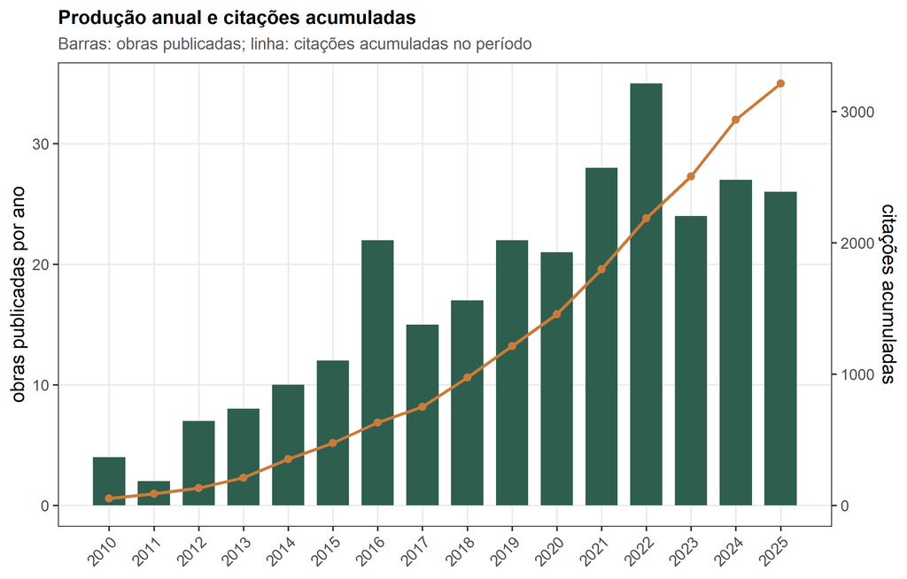

Figura 5: Produção anual do acervo, em número de obras, e citações acumuladas no período.

```r
# série anual que o próprio describe_biblio devolve
m3_an <- describe_biblio(x_analise)$annual
m3_an$acumulado <- cumsum(m3_an$citations)
# fator de escala entre o eixo das barras e o eixo da linha
m3_escala <- max(m3_an$acumulado)/max(m3_an$documents)

ggplot(m3_an, aes(x = year)) +
  geom_col(aes(y = documents), fill = pal_agri[1], width = .72) +
  geom_line(aes(y = acumulado/m3_escala), colour = pal_agri[2], linewidth = .9) +
  geom_point(aes(y = acumulado/m3_escala), colour = pal_agri[2], size = 1.7) +
  scale_x_continuous(breaks = m3_an$year) +
  scale_y_continuous(
    name = "obras publicadas por ano",
    sec.axis = sec_axis(~ . * m3_escala, name = "citações acumuladas")) +
  labs(x = NULL, title = "Produção anual e citações acumuladas",
       subtitle = "Barras: obras publicadas; linha: citações acumuladas no período") +
  theme(axis.text.x = element_text(angle = 45, hjust = 1))
```

A figura combina duas leituras que respondem a perguntas diferentes. As barras mostram que a produção não cresce de forma constante: o acervo passa de 4 obras em 2010 para 26 em 2025, atinge o pico em 2022, quando entram 35 obras, e recua nos anos seguintes, com 24 obras em 2023 e 26 em 2025. A linha mostra o estoque de citações, que sobe sem interrupção até 3215 porque citação é acumulada por natureza e não cai quando a produção cai. A leitura conjunta é o que evita a armadilha: um ano de retração na produção não significa queda de impacto, e a distância entre a barra do último ano e a linha acumulada é a medida da desvantagem temporal de quem publicou recentemente. É por causa dessa desvantagem que a normalização da última seção do módulo existe.

Quanto ao conteúdo, os termos mais frequentes do acervo, contados sobre as palavras-chave normalizadas por `describe_biblio()`, são nutrient uptake (77 ocorrências), drought stress (76) e silicon fertilization (76). O ranking dos veículos começa por Scientia Agricola, com 37 obras, seguido de Soil Biology & Biochemistry, com 34. Note que a contagem de obras por veículo não diz nada sobre impacto: a fonte que mais publica no acervo não está entre as primeiras em citação média, como a seção sobre veículos mostra. Confundir volume com impacto é o segundo erro clássico de quem descreve acervo, e a correção exige a mesma tabela em duas colunas diferentes.

## 7.3 Quem publica: produção, citação e índices por autor

```r
# as métricas por autor vêm em um data frame com a coluna author
m3_bm <- biblio_metrics(x_analise)

# a coluna author já traz o nome de exibição nesta versão; a junção com a tabela
# de autores acrescenta o identificador e serve de conferência
m3_autores <- merge(m3_bm, x_analise$authors, by.x = "author", by.y = "display_name")
m3_autores <- m3_autores[order(-m3_autores$h_index, -m3_autores$citations), ]
m3_top10 <- head(m3_autores[, c("author", "author_id", "documents", "citations",
                                "h_index", "g_index", "m_index")], 10)
# as métricas somam 871 produções para 853 vínculos: o excesso vem da chave repetida
m3_soma_doc <- sum(m3_bm$documents)
m3_vinculos <- nrow(x_analise$authorships)
# a conferência de nomes: a coluna de métricas usa o mesmo nome de exibição da tabela de autores
m3_nomes_ok <- setequal(m3_bm$author, x_analise$authors$display_name)

knitr::kable(
  data.frame(autor = m3_top10$author, identificador = m3_top10$author_id,
             producao = m3_num(m3_top10$documents), citacoes = m3_num(m3_top10$citations),
             h = m3_num(m3_top10$h_index), g = m3_num(m3_top10$g_index),
             m = m3_num(m3_top10$m_index, 3)),
  row.names = FALSE,
  col.names = c("autor", "identificador", "produção", "citações", "índice h",
                "índice g", "índice m"),
  caption = "Dez autores mais produtivos por índice h no acervo analítico, com produção, citações e índices.")
```

Tabela 11: Dez autores mais produtivos por índice h no acervo analítico, com produção, citações e índices.

Dez autores mais produtivos por índice h no acervo analítico, com produção, citações e índices.

| autor | identificador | produção | citações | índice h | índice g | índice m |
| --- | --- | --- | --- | --- | --- | --- |
| Silva AP | A00000b2d | 145 | 1766 | 21 | 31 | 1.312 |
| Pereira WE | A00001225 | 76 | 836 | 18 | 23 | 1.125 |
| Oliveira TN | A00001691 | 76 | 788 | 18 | 22 | 1.125 |
| Almeida FB | A0000110a | 57 | 692 | 18 | 22 | 1.125 |
| Martins LC | A00001245 | 72 | 966 | 17 | 25 | 1.062 |
| Costa JR | A00000b85 | 66 | 741 | 17 | 24 | 1.062 |
| Chen L | A00000662 | 51 | 723 | 17 | 24 | 1.062 |
| Smith J | A00000906 | 60 | 731 | 16 | 22 | 1 |
| Rossi G | A00000913 | 56 | 646 | 16 | 22 | 1 |
| Souza RM | A00000bc3 | 55 | 635 | 16 | 21 | 1 |

Esta tabela precisa de três avisos, e os três são de método. O primeiro é sobre a nomenclatura dos índices: `documents` é o número de vínculos de autoria do autor no acervo, `citations` é a soma das citações dessas obras, `h_index` é o maior número h tal que o autor tem h obras com pelo menos h citações cada, `g_index` avança o mesmo raciocínio sobre a soma acumulada, e `m_index` divide o índice h pela extensão da carreira no acervo, o que favorece quem publica cedo e por muitos anos. O segundo é que o topo é dominado por um autor: Silva AP assina 145 dos 280 registros do acervo, ou 51.8 por cento deles, com 1766 citações e índice h 21. Em um levantamento real isso indica um grupo de pesquisa que domina a frente, e a consequência é que qualquer inferência sobre a área carrega a marca desse grupo; em um acervo simulado, é a verdade plantada V5 aparecendo. O terceiro aviso é que o índice h premia longevidade e volume, não impacto por obra, e por isso ele não substitui a medida normalizada que fecha o módulo. Cabe ainda uma observação sobre a junção feita no código: a coluna `author` das métricas já contém o nome de exibição nesta versão do pacote, e não o identificador, de modo que a junção com a tabela de autores funciona como conferência e como enriquecimento — a comparação entre os dois conjuntos de nomes devolve TRUE. Se a sua versão trouxer identificadores nessa coluna, a mesma junção continua correta, apenas trocando a chave de ligação.

Há ainda um detalhe de infraestrutura que a tabela não mostra e que vale conferir. A soma da coluna `documents` dá 871, mas o acervo tem 853 vínculos de autoria: a diferença de 18 não é erro de arredondamento, é o efeito dos identificadores repetidos discutidos no Módulo 2, que fazem a junção entre vínculos e obras repetir linhas. A verificação é direta e vale a pena incluir no seu código sempre que o painel por autor for para o artigo.

```r
# reconstrução do mesmo acervo com identificador único declarado na entrada
m3_dR <- dB
m3_dR$work_id <- sprintf("WB%04d", seq_len(nrow(m3_dR)))
m3_xR <- deduplicate_biblio(as_biblio_project(m3_dR, source = "corpus B reparado"),
                            method = "doi_title_year")
m3_manter <- !is.na(m3_xR$works$year)
m3_xR$works <- m3_xR$works[m3_manter, , drop = FALSE]
m3_xR$authorships <- m3_xR$authorships[m3_xR$authorships$work_id %in% m3_xR$works$work_id, , drop = FALSE]
m3_xR$keywords <- m3_xR$keywords[m3_xR$keywords$work_id %in% m3_xR$works$work_id, , drop = FALSE]
m3_bmR <- biblio_metrics(m3_xR)

m3_cmp <- merge(m3_bm, m3_bmR, by = "author", suffixes = c("_calculado", "_declarado"))
m3_cmp <- m3_cmp[m3_cmp$documents_calculado != m3_cmp$documents_declarado |
                 m3_cmp$citations_calculado != m3_cmp$citations_declarado, ]
m3_cmp <- m3_cmp[order(-m3_cmp$citations_calculado + m3_cmp$citations_declarado), ]

knitr::kable(
  data.frame(autor = m3_cmp$author,
             prod_calc = m3_num(m3_cmp$documents_calculado),
             prod_decl = m3_num(m3_cmp$documents_declarado),
             cit_calc = m3_num(m3_cmp$citations_calculado),
             cit_decl = m3_num(m3_cmp$citations_declarado),
             h_calc = m3_num(m3_cmp$h_index_calculado),
             h_decl = m3_num(m3_cmp$h_index_declarado)),
  row.names = FALSE,
  col.names = c("autor", "produção (chave calculada)", "produção (chave declarada)",
                "citações (chave calculada)", "citações (chave declarada)",
                "índice h (calculada)", "índice h (declarada)"),
  caption = "Autores afetados pelos identificadores repetidos: produção e citações com a chave calculada pelo pacote e com chave única declarada na importação.")
```

Tabela 12: Autores afetados pelos identificadores repetidos: produção e citações com a chave calculada pelo pacote e com chave única declarada na importação.

Autores afetados pelos identificadores repetidos: produção e citações com a chave calculada pelo pacote e com chave única declarada na importação.

| autor | produção (chave calculada) | produção (chave declarada) | citações (chave calculada) | citações (chave declarada) | índice h (calculada) | índice h (declarada) |
| --- | --- | --- | --- | --- | --- | --- |
| Martins LC | 72 | 70 | 966 | 950 | 17 | 17 |
| Costa JR | 66 | 64 | 741 | 731 | 17 | 17 |
| Rossi G | 56 | 54 | 646 | 639 | 16 | 16 |
| Pereira WE | 76 | 75 | 836 | 830 | 18 | 18 |
| Oliveira TN | 76 | 75 | 788 | 784 | 18 | 18 |
| Almeida FB | 57 | 56 | 692 | 691 | 18 | 18 |
| Chen L | 51 | 50 | 723 | 722 | 17 | 17 |
| Smith J | 60 | 59 | 731 | 730 | 16 | 16 |
| Souza RM | 55 | 54 | 635 | 634 | 16 | 16 |

A tabela mede o tamanho do problema e também o limite dele. São 9 autores afetados, e o maior desvio de produção é de 2 obras, enquanto o maior desvio de citações chega a 16 citações — concentrado em Martins LC. O que a tabela mostra com igual clareza é que as colunas de índice h são idênticas nas duas versões: o índice h é robusto a esse tipo de inflação, porque acrescentar uma obra duplicada ao conjunto de um autor desloca a contagem de títulos, mas raramente muda o ponto em que h obras têm h citações. A conclusão prática é fina: o ranqueamento por índice h do acervo não muda, o painel de produção e de citações sim. Se o seu artigo apresenta média de citações por autor ou produtividade por grupo, declare `work_id` na importação; se apresenta apenas índice h, a distorção não alcança a conclusão, embora continue valendo corrigi-la.

## 7.4 Onde se publica: o efeito do veículo

```r
# desempenho por fonte, com as medidas de posição e de dispersão
m3_fontes <- do.call(data.frame, aggregate(
  cited_by_count ~ source, data = m3_w,
  FUN = function(z) c(n = length(z), total = sum(z), media = mean(z),
                      mediana = median(z), dp = sd(z))))
names(m3_fontes) <- c("fonte", "obras", "citacoes", "media", "mediana", "dp")
m3_fontes <- m3_fontes[order(-m3_fontes$media), ]
m3_fontes$posicao <- seq_len(nrow(m3_fontes))

# as duas fontes que receberam 12 citações extras por obra no corpus simulado
m3_bonus <- c("Field Crops Research", "Soil Biology & Biochemistry")
m3_fontes$bonus <- m3_fontes$fonte %in% m3_bonus
m3_fontes$media_ajustada <- m3_fontes$media - 12 * m3_fontes$bonus
m3_fontes$posicao_ajustada <- rank(-m3_fontes$media_ajustada, ties.method = "min")

knitr::kable(
  data.frame(fonte = m3_fontes$fonte, obras = m3_num(m3_fontes$obras),
             citacoes = m3_num(m3_fontes$citacoes), media = m3_num(m3_fontes$media),
             mediana = m3_num(m3_fontes$mediana), dp = m3_num(m3_fontes$dp),
             posicao = m3_num(m3_fontes$posicao),
             media_ajustada = m3_num(m3_fontes$media_ajustada),
             posicao_ajustada = m3_num(m3_fontes$posicao_ajustada)),
  row.names = FALSE,
  col.names = c("fonte", "obras", "citações", "média", "mediana", "desvio-padrão",
                "posição", "média sem o bônus", "posição sem o bônus"),
  caption = "Desempenho por periódico: obras publicadas, citações totais e por obra, e a posição no ranking com e sem o bônus plantado nas duas fontes de maior impacto.")
```

Tabela 13: Desempenho por periódico: obras publicadas, citações totais e por obra, e a posição no ranking com e sem o bônus plantado nas duas fontes de maior impacto.

Desempenho por periódico: obras publicadas, citações totais e por obra, e a posição no ranking com e sem o bônus plantado nas duas fontes de maior impacto.

| fonte | obras | citações | média | mediana | desvio-padrão | posição | média sem o bônus | posição sem o bônus |
| --- | --- | --- | --- | --- | --- | --- | --- | --- |
| Field Crops Research | 32 | 668 | 20.88 | 19.50 | 5.49 | 1 | 8.88 | 5 |
| Soil Biology & Biochemistry | 34 | 591 | 17.38 | 17 | 4.55 | 2 | 5.38 | 10 |
| Pesquisa Agropecuária Brasileira | 22 | 282 | 12.82 | 10.50 | 10.22 | 3 | 12.82 | 1 |
| Revista Brasileira de Ciência do Solo | 26 | 282 | 10.85 | 4 | 17.60 | 4 | 10.85 | 2 |
| Remote Sensing | 24 | 256 | 10.67 | 6 | 13.22 | 5 | 10.67 | 3 |
| Precision Agriculture | 28 | 274 | 9.79 | 3.50 | 19.13 | 6 | 9.79 | 4 |
| Agronomy Journal | 23 | 196 | 8.52 | 5 | 12.07 | 7 | 8.52 | 6 |
| Scientia Agricola | 37 | 287 | 7.76 | 6 | 6.53 | 8 | 7.76 | 7 |
| Soil & Tillage Research | 25 | 181 | 7.24 | 5 | 6.12 | 9 | 7.24 | 8 |
| Plant and Soil | 29 | 198 | 6.83 | 6 | 6.02 | 10 | 6.83 | 9 |

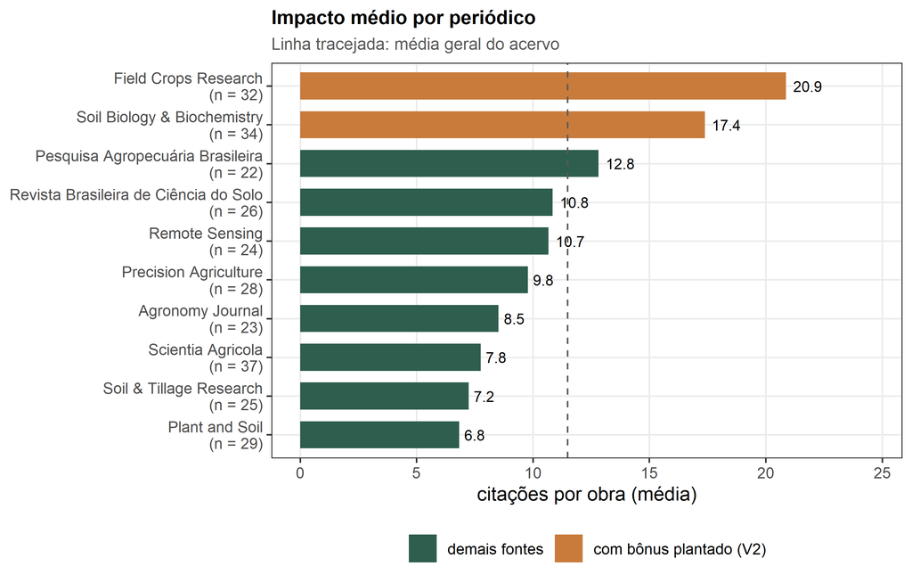

Figura 6: Periódicos ordenados por citação média por obra, com o número de obras anotado e as duas fontes do bônus plantado destacadas.

```r
m3_fontes$rotulo <- sprintf("%s\n(n = %d)", m3_fontes$fonte, m3_fontes$obras)
m3_fontes$rotulo <- factor(m3_fontes$rotulo, levels = rev(m3_fontes$rotulo))

ggplot(m3_fontes, aes(x = rotulo, y = media, fill = bonus)) +
  geom_col(width = .7) +
  geom_text(aes(label = sprintf("%.1f", media)), hjust = -.25, size = 3) +
  geom_hline(yintercept = mean(m3_w$cited_by_count), linetype = 2, colour = "grey35") +
  scale_fill_manual(values = c(`TRUE` = pal_agri[2], `FALSE` = pal_agri[1]),
                    labels = c(`TRUE` = "com bônus plantado (V2)", `FALSE` = "demais fontes"),
                    name = NULL) +
  scale_y_continuous(limits = c(0, max(m3_fontes$media) * 1.18)) +
  coord_flip() +
  labs(x = NULL, y = "citações por obra (média)",
       title = "Impacto médio por periódico",
       subtitle = "Linha tracejada: média geral do acervo")
```

A figura ordena os veículos por citação média e anota o tamanho de cada um, o que permite ler as duas dimensões ao mesmo tempo. As duas barras coloridas são as fontes do bônus plantado, e a distância entre elas e o resto do grupo é o efeito do acréscimo constante. A linha tracejada marca a média geral do acervo, 11.48: 3 dos 10 veículos ficam acima dela, e o último fica em 6.83 citações por obra. O número de obras anotado mostra que volume e média não caminham juntos — o veículo com mais obras do acervo tem 37 delas e média de 7.76 —, e essa dissociação é o argumento que sustenta a escolha da média por obra no lugar da contagem absoluta quando a pergunta é onde a área publica o que é mais citado. Cuidado com uma leitura indevida: diferença de média entre periódicos não é evidência de que o periódico causa citação, porque autores melhores escolhem periódicos melhores, e os dois efeitos não se separam sem dados de qualidade do manuscrito.

## 7.5 Coautoria internacional e impacto

```r
# as quatro assinaturas estrangeiras plantadas no corpus simulado
m3_int <- c("Smith J", "Chen L", "Müller H", "Rossi G")
m3_nome <- setNames(x_analise$authors$display_name, x_analise$authors$author_id)
m3_aut <- x_analise$authorships
m3_aut$nome <- unname(m3_nome[m3_aut$author_id])

# uma obra tem coautoria internacional quando ao menos um desses autores assina
m3_por_obra <- split(m3_aut$nome, m3_aut$work_id)
m3_ids_int <- names(m3_por_obra)[vapply(m3_por_obra,
                                        function(z) any(z %in% m3_int), logical(1))]
m3_w$internacional <- ifelse(m3_w$work_id %in% m3_ids_int,
                             "com coautoria internacional", "sem coautoria internacional")
m3_w$internacional <- factor(m3_w$internacional,
                             levels = c("com coautoria internacional", "sem coautoria internacional"))

m3_grupos <- do.call(data.frame, aggregate(
  cited_by_count ~ internacional, data = m3_w,
  FUN = function(z) c(n = length(z), media = mean(z), mediana = median(z), dp = sd(z))))
names(m3_grupos) <- c("grupo", "obras", "media", "mediana", "dp")
m3_grupos$percentual <- round(100 * m3_grupos$obras/sum(m3_grupos$obras), 1)

m3_teste <- suppressWarnings(wilcox.test(cited_by_count ~ internacional, data = m3_w))
m3_ttest <- t.test(cited_by_count ~ internacional, data = m3_w)

knitr::kable(
  data.frame(grupo = m3_grupos$grupo, obras = m3_num(m3_grupos$obras),
             media = m3_num(m3_grupos$media), mediana = m3_num(m3_grupos$mediana),
             dp = m3_num(m3_grupos$dp),
             percentual = m3_num(m3_grupos$percentual, 1)),
  row.names = FALSE,
  col.names = c("grupo", "obras", "citações médias", "mediana",
                "desvio-padrão", "percentual do acervo"),
  caption = "Citações por obra em obras com e sem coautoria internacional, com proporção, medidas de posição e teste de Wilcoxon.")
```

| grupo | obras | citações médias | mediana | desvio-padrão | percentual do acervo |
| --- | --- | --- | --- | --- | --- |
| com coautoria internacional | 144 | 12.40 | 10 | 12.29 | 51.4 |
| sem coautoria internacional | 136 | 10.51 | 7.50 | 10.96 | 48.6 |

A verdade plantada V3 é sobre a proporção, e a proporção medida é 51.4 por cento das obras com pelo menos uma assinatura estrangeira — 144 de 280 registros, perto da metade prevista, mas não exatamente metade, o que é a razão de medir em vez de afirmar. O efeito no impacto existe na direção esperada: as obras com coautoria internacional somam 12.40 citações em média contra 10.51 das demais, uma razão de 1.18. O teste de Wilcoxon devolve p igual a 0.158 e o teste t de Welch 0.177, e os dois concordam: com este tamanho de acervo, uma diferença dessa ordem é compatível com flutuação amostral. A leitura correta para o artigo é que a coautoria internacional está associada a citações ligeiramente maiores, mas o acervo não separa essa diferença do ruído, e transformar o número em afirmação de causalidade seria sobre-interpretação. O mesmo cuidado vale para a atribuição do grupo: como a tabela de vínculos carrega apenas o identificador da obra, os registros que compartilham identificador herdam o mesmo conjunto de autores, e 8 registros ficam com atribuição ambígua de coautoria — mais uma razão para declarar chave única na importação.

## 7.6 A distribuição das citações

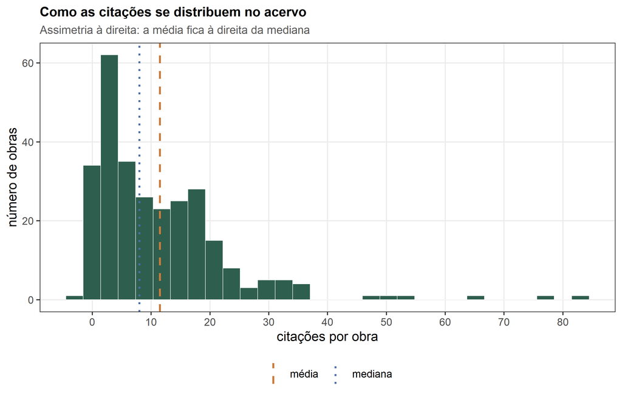

Figura 7: Distribuição das citações por obra no acervo analítico, com média e mediana marcadas.

```r
m3_dist <- data.frame(citacoes = m3_w$cited_by_count)
m3_ref <- data.frame(x = c(mean(m3_w$cited_by_count), median(m3_w$cited_by_count)),
                     medida = c("média", "mediana"))

ggplot(m3_dist, aes(x = citacoes)) +
  geom_histogram(bins = 30, fill = pal_agri[1], colour = "white", linewidth = .2) +
  geom_vline(data = m3_ref, aes(xintercept = x, colour = medida, linetype = medida),
             linewidth = .8) +
  scale_colour_manual(values = c("média" = pal_agri[2], "mediana" = pal_agri[3]), name = NULL) +
  scale_linetype_manual(values = c("média" = "dashed", "mediana" = "dotted"), name = NULL) +
  scale_x_continuous(breaks = seq(-10, 90, 10)) +
  labs(x = "citações por obra", y = "número de obras",
       title = "Como as citações se distribuem no acervo",
       subtitle = "Assimetria à direita: a média fica à direita da mediana")
```

A figura é o argumento visual para não resumir o acervo pela média. A massa concentra-se entre zero e vinte citações, com a mediana em 8 e a média em 11.48, e a cauda se estende até 83. Há ainda um ponto isolado à esquerda, a obra com contagem negativa, que aparece no primeiro intervalo — ele é um artefato de correção da base de dados, não um dado de impacto, e a decisão sobre mantê-lo está registrada no Módulo 2. A consequência prática é dupla: primeiro, qualquer comparação entre grupos feita por média precisa vir acompanhada de mediana, porque a média é sensível a poucas obras muito citadas e a mediana não; segundo, o formato da distribuição justifica o uso de teste não paramétrico nas comparações entre grupos, que foi o que a seção anterior fez ao reportar Wilcoxon ao lado do teste t. Vale notar que as 10 obras sem nenhuma citação não são um defeito de dados: em um recorte que inclui os anos recentes, ausência de citação é o resultado esperado para parte do acervo.

## 7.7 Impacto relativo ao ano e ao periódico

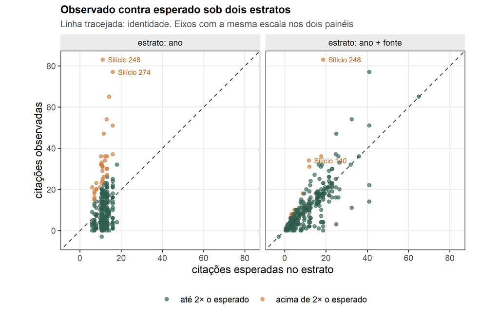

Figura 8: Citações observadas contra citações esperadas sob dois estratos: apenas o ano de publicação e o par ano e periódico. A linha tracejada é a identidade, e os eixos usam a mesma escala nos dois painéis.

```r
m3_ncy <- normalized_citations(x_analise, strata = "year")
m3_ncf <- normalized_citations(x_analise, strata = c("year", "source"))
# rótulo curto: tema de pesquisa e número do estudo, para identificar os extremos
m3_curto <- function(t) paste0(sub("^([^ ]+).*", "\\1", t), " ",
                               sprintf("%03d", as.integer(sub(".*estudo ([0-9]+).*", "\\1", t))))
m3_curto_w <- m3_curto(m3_w$title)

m3_nc <- rbind(
  data.frame(estrato = "estrato: ano", m3_ncy, curto = m3_curto_w, fonte = m3_w$source),
  data.frame(estrato = "estrato: ano + fonte", m3_ncf, curto = m3_curto_w, fonte = m3_w$source))
m3_nc$estrato <- factor(m3_nc$estrato, levels = c("estrato: ano", "estrato: ano + fonte"))
m3_nc$extremo <- !is.na(m3_nc$normalized) & m3_nc$normalized > 2

# os dois extremos de cada estrato recebem rótulo para leitura direta
m3_rot <- do.call(rbind, lapply(split(m3_nc, m3_nc$estrato), function(d)
  head(d[order(-d$normalized), c("estrato", "expected", "citations", "curto")], 2)))
m3_limite <- max(m3_nc$citations)

# resumo numérico por estrato, usado na leitura abaixo
m3_por_estrato <- do.call(rbind, lapply(split(m3_nc, m3_nc$estrato), function(d)
  data.frame(estrato = d$estrato[1],
             correlacao = round(cor(d$citations, d$expected), 3),
             mediana = round(median(d$normalized, na.rm = TRUE), 3),
             iqr = round(IQR(d$normalized, na.rm = TRUE), 3),
             acima_de_2 = sum(d$normalized > 2, na.rm = TRUE))))

# média do normalizado por grupo de fonte, para mostrar onde o prestígio se esconde
m3_nc$grupo_fonte <- ifelse(m3_nc$fonte %in% m3_bonus, "fontes com bônus", "demais fontes")
m3_grupo_estrato <- do.call(rbind, lapply(split(m3_nc, m3_nc$estrato), function(d)
  data.frame(estrato = d$estrato[1],
             bonus = round(mean(d$normalized[d$grupo_fonte == "fontes com bônus"], na.rm = TRUE), 2),
             demais = round(mean(d$normalized[d$grupo_fonte == "demais fontes"], na.rm = TRUE), 2))))

ggplot(m3_nc, aes(x = expected, y = citations)) +
  geom_point(aes(colour = extremo), alpha = .65, size = 1.5) +
  geom_abline(slope = 1, intercept = 0, linetype = 2, colour = "grey25") +
  geom_text(data = m3_rot, aes(label = curto), size = 2.6,
            nudge_x = 2.5, hjust = 0, colour = pal_agri[6]) +
  facet_wrap(~ estrato, ncol = 2) +
  coord_fixed(ratio = 1, xlim = c(-5, m3_limite), ylim = c(-5, m3_limite)) +
  scale_colour_manual(values = c(`TRUE` = pal_agri[2], `FALSE` = pal_agri[1]),
                      labels = c(`TRUE` = "acima de 2× o esperado", `FALSE` = "até 2× o esperado"),
                      name = NULL) +
  labs(x = "citações esperadas no estrato", y = "citações observadas",
       title = "Observado contra esperado sob dois estratos",
       subtitle = "Linha tracejada: identidade. Eixos com a mesma escala nos dois painéis")
```

A figura é a comparação central do módulo, e cada painel conta uma história diferente. Os dois eixos usam a mesma escala, de modo que a linha tracejada é realmente a diagonal e um ponto acima dela está acima do esperado, sem ilusão de inclinação. No painel da esquerda, o esperado é a média de citações do ano de publicação, e a nuvem de pontos afasta-se da linha de identidade de forma sistemática: a correlação entre observado e esperado é de apenas 0.214, e a mediana da razão fica em 0.73. O motivo é que o prestígio do periódico permaneceu no resíduo. A prova está na comparação entre grupos de fonte da seção anterior: sob o estrato do ano, as obras das duas fontes com bônus têm razão média de 1.68 contra 0.79 das demais, uma diferença de mais de duas vezes que nada tem a ver com a idade da obra. No painel da direita, o esperado passa a ser a média do par ano e periódico: as médias de razão dos dois grupos de fonte convergem para 1 e 1, ou seja, o bônus do veículo deixa de aparecer no resíduo; a nuvem encosta na diagonal, a correlação sobe para 0.762 e as obras com razão acima de duas vezes o esperado caem de 34 para 10. A leitura é que normalizar por ano e fonte corrige os dois efeitos ao mesmo tempo — a idade e o prestígio do veículo — e que o que sobrevive ao ajuste é o que a obra tem de próprio. Os pontos destacados em laranja são os que superam duas vezes o esperado no seu estrato, e os rótulos nomeiam os dois maiores de cada painel: são eles que a tabela seguinte detalha.

O preço do ajuste duplo também aparece na figura e precisa ser dito. Com 280 obras distribuídas em 121 estratos de ano e fonte, muitos estratos ficam com poucas obras: 32 estratos têm uma única obra, e nesses casos a citação esperada passa a ser a citação da própria obra, o que força a razão a valer exatamente um. A dispersão encolhe — o intervalo interquartílico cai de 1.152 para 0.56 —, e a mediana da razão passa a 1 por construção, não por mérito do acervo. A consequência prática é escolher o estrato de acordo com o tamanho da amostra: em acervo de algumas centenas de obras, o par ano e fonte é defensável e informativo; em acervo pequeno, o estrato duplo devolve quase tudo igual a um e não discrimina nada. Muitos dos pontos sobre a linha de identidade não são obras medianas, são obras sozinhas no seu estrato.

```r
m3_ncf$curto <- m3_curto_w
m3_ncf$ano <- m3_w$year
m3_ncf$fonte <- m3_w$source
m3_top_norm <- head(m3_ncf[order(-m3_ncf$normalized),
                           c("curto", "ano", "fonte", "citations", "expected", "normalized")], 10)

knitr::kable(
  data.frame(obra = m3_top_norm$curto, ano = m3_num(m3_top_norm$ano),
             periodico = m3_top_norm$fonte,
             observadas = m3_num(m3_top_norm$citations),
             esperadas = m3_num(m3_top_norm$expected),
             razao = m3_num(m3_top_norm$normalized)),
  row.names = FALSE,
  col.names = c("obra", "ano", "periódico", "citações observadas",
                "citações esperadas", "razão"),
  caption = "Dez obras com maior citação normalizada no estrato de ano e periódico, com o esperado do estrato e a fonte de publicação.")
```

Tabela 15: Dez obras com maior citação normalizada no estrato de ano e periódico, com o esperado do estrato e a fonte de publicação.

Dez obras com maior citação normalizada no estrato de ano e periódico, com o esperado do estrato e a fonte de publicação.

| obra | ano | periódico | citações observadas | citações esperadas | razão |
| --- | --- | --- | --- | --- | --- |
| Silício 248 | 2022 | Precision Agriculture | 83 | 18.60 | 4.46 |
| Silício 140 | 2021 | Agronomy Journal | 34 | 11.75 | 2.89 |
| Sensoriamento 082 | 2022 | Scientia Agricola | 31 | 12 | 2.58 |
| Sensoriamento 241 | 2019 | Precision Agriculture | 8 | 3.33 | 2.40 |
| Silício 181 | 2021 | Scientia Agricola | 6 | 2.60 | 2.31 |
| Sensoriamento 112 | 2017 | Precision Agriculture | 8 | 3.50 | 2.29 |
| Silício 037 | 2025 | Plant and Soil | 10 | 4.75 | 2.11 |
| Silício 113 | 2022 | Plant and Soil | 7 | 3.33 | 2.10 |
| Sensoriamento 086 | 2023 | Soil & Tillage Research | 18 | 8.80 | 2.05 |
| Carbono 124 | 2023 | Remote Sensing | 36 | 17.67 | 2.04 |

A tabela traduz o painel da direita em nomes, e é ela que entra no artigo. O rótulo de cada obra combina o primeiro termo do tema com o número do estudo, para que a tabela caiba na página sem perder a identificação. A primeira colocada é Silício 248, de 2022, publicada em Precision Agriculture: com 83 citações contra 18.60 esperadas para o seu estrato de ano e veículo, ela recebeu 4.46 vezes o esperado. O que chama atenção na lista é a procedência: nenhuma das obras do topo pertence às duas fontes com bônus plantado, e várias vêm de periódicos de média modesta, o que é exatamente o comportamento esperado de uma medida relativa — ela premia quem supera os pares do próprio estrato, não quem publicou no veículo de maior prestígio. A última colocada da lista tem razão 2.04, o que dá a ordem de grandeza do que conta como destaque neste acervo. A leitura para o artigo é que a razão normalizada responde a uma pergunta diferente da citação bruta: a citação bruta mede reconhecimento acumulado, a razão mede desempenho relativo às condições de publicação, e as duas devem ser reportadas juntas quando o acervo cobre quinze anos de produção.

## 7.8 Tarefas do Módulo 3

**Tarefa 3.1 (aplicar).** Refaça o retrato descritivo e o painel de impacto sobre o recorte de 2020 a 2025, usando o vetor `per_B` para selecionar as obras (lembre que o recorte precisa valer também para as tabelas de autoria e de palavras-chave). Rode `describe_biblio()`, `biblio_metrics()` e a tabela de fontes por citação média, e compare com o acervo completo: quantas obras entram, como muda a média de citações por obra, quais fontes lideram por citação média, e o que acontece com o topo do ranking de autores quando o período é restringido.

**Tarefa 3.2 (analisar e criar).** Escreva uma função `impacto_relativo(x, strata, fun)` que devolva, para cada obra, a razão entre as citações observadas e uma medida de referência calculada dentro do estrato indicado, aceitando `fun = mean` ou `fun = median`. Verifique que a versão com média reproduz exatamente `normalized_citations()` com os mesmos estratos, rode as duas versões sobre `x_analise` e discuta: quantas obras ultrapassam duas vezes a referência em cada caso, o que muda no topo da lista e qual das duas medidas você adotaria em um acervo com muitos estratos de duas obras, justificando a escolha em termos da variabilidade que cada uma introduz.

# 8 Módulo 4. Dinâmica temporal e disrupção

## 8.1 O problema agronômico

Quem trabalha com fertilidade do solo e estresse abiótico enfrenta hoje uma pergunta de política científica antes de qualquer pergunta de campo: a frente de pesquisa sobre silício e salinidade está crescendo, estagnada ou apenas diversificando o vocabulário? A resposta muda o que se recomenda a um orientando. Se a frente cresce em volume, há espaço para uma tese experimental; se o que cresce é apenas o número de revisões sobre o mesmo corpo de evidências, o espaço está na síntese, não no experimento. Separar produção de consolidação é exatamente o que as cinco funções deste módulo fazem.

O segundo problema é de composição. Um acervo pode dobrar de tamanho e continuar dizendo a mesma coisa, ou pode manter o tamanho e mudar de assunto. No material que usamos aqui, a frente agronômica de silício e salinidade convive com duas vizinhas: carbono do solo com plantas de cobertura e sensoriamento remoto com aprendizado de máquina. A pergunta prática do doutorando é onde a novidade se concentra, porque é ali que a revisão de literatura precisa ser mais recente.

O terceiro problema é o mais delicado e o menos ensinado. Quando um artigo propõe um mecanismo novo, ele é *disruptivo*: os trabalhos seguintes discutem a proposta dele sem se apoiarem no que ele citou. Quando um artigo apenas organiza o que já se sabia, ele é *consolidativo*: quem o cita cita também as mesmas referências anteriores. As duas situações produzem contagens de citação parecidas, e a contagem de citação sozinha não as distingue. O módulo termina com o índice que faz essa separação a partir da própria rede de citações, e com a demonstração de como uma tabela de arestas mal nomeada é recusada pelo pacote.

## 8.2 Crescimento anual da produção

O primeiro recorte é o mais simples e o que mais aparece em artigo: quantos documentos por ano e quantas citações esses documentos acumularam. A função `temporal_growth()` faz a agregação por ano e acrescenta a taxa de crescimento percentual em relação ao ano imediatamente anterior. Como não existe ano anterior ao primeiro, a taxa do primeiro ano é ausente por construção, e não por defeito do dado.

```r
# 4.1 Agregação anual: documentos, citações e variação percentual
cresc <- temporal_growth(x_analise)

# 4.2 Primeiras e últimas linhas: início do crescimento e anos recentes
# a linha de NA separa os dois blocos e marca a taxa ausente do primeiro ano
cresc_faixas <- rbind(
  head(cresc, 3L),
  data.frame(year = NA_integer_, documents = NA_integer_,
             citations = NA_integer_, growth_pct = NA_real_),
  tail(cresc, 3L))

knitr::kable(cresc_faixas, row.names = FALSE,
  digits = 1, caption = "Crescimento anual do acervo analítico: taxa percentual em relação ao ano anterior e citações acumuladas por coorte. A linha de ausentes separa o início da série do fim, e a taxa do primeiro ano é ausente porque não existe ano anterior.")
```

Tabela 16: Crescimento anual do acervo analítico: taxa percentual em relação ao ano anterior e citações acumuladas por coorte.

Crescimento anual do acervo analítico: taxa percentual em relação ao ano anterior e citações acumuladas por coorte. A linha de ausentes separa o início da série do fim, e a taxa do primeiro ano é ausente porque não existe ano anterior.

| year | documents | citations | growth_pct |
| --- | --- | --- | --- |
| 2010 | 4 | 53 | NA |
| 2011 | 2 | 36 | -50.0 |
| 2012 | 7 | 42 | 250.0 |
| NA | NA | NA | NA |
| 2023 | 24 | 319 | -31.4 |
| 2024 | 27 | 432 | 12.5 |
| 2025 | 26 | 276 | -3.7 |

Aqui está a primeira assinatura temporal do acervo. O período cobre 16 anos, de 2010 a 2025, e o primeiro deles tem 4 obras: um começo magro, o que é típico de recorte por janela temporal em base bibliográfica. A taxa média de crescimento de 2011 a 2025 é de 25.6 por cento ao ano, mas essa média esconde o que interessa, porque ela mistura duas fases. A taxa média entre 2011 e 2019 é de 39.3 por cento ao ano, enquanto de 2020 a 2025 ela cai para 5.2 por cento ao ano.

A leitura ingênua dessa queda seria “a frente está morrendo”. A leitura correta vem da comparação entre as duas colunas. A coorte de 2020 a 2025 reúne 161 obras, contra 119 obras na década anterior; o ano de maior produção do acervo é 2022, com 35 obras. O que desacelerou foi a *taxa*, não o volume: com o acervo já grande, cada ano novo precisa acrescentar um número absoluto maior para manter a mesma taxa percentual. Além disso, as citações por obra sobem de 10.2 na década anterior para 12.43 no período recente. Volume maior com impacto por obra maior não é cenário de declínio; é cenário de frente madura que continua atraindo atenção.

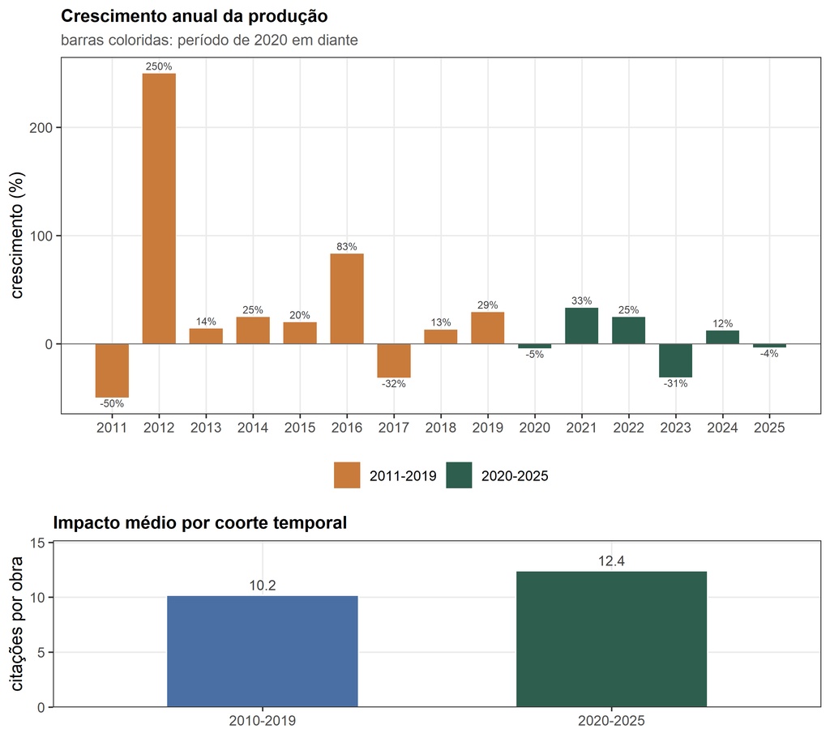

Figura 9: Taxa de crescimento anual da produção do acervo analítico. O painel superior isola o crescimento percentual dos anos recentes; o inferior mostra as citações por obra de cada período.

```r
# 4.3 Taxa de crescimento com destaque do período recente
d_g <- cresc[!is.na(cresc$growth_pct) & cresc$year >= min(cresc$year) + 1L, ]
d_g$fase <- ifelse(d_g$year >= 2020L, "2020-2025", "2011-2019")
d_g$rotulo <- paste0(sprintf("%.0f", d_g$growth_pct), "%")

p_g <- ggplot(d_g, aes(x = year, y = growth_pct, fill = fase)) +
  geom_col(width = .72, colour = "white", linewidth = .2) +
  geom_hline(yintercept = 0, colour = "grey40", linewidth = .3) +
  geom_text(aes(label = rotulo), vjust = ifelse(d_g$growth_pct >= 0, -.45, 1.15),
            size = 2.3, colour = "grey25") +
  scale_fill_manual(values = c("2011-2019" = pal_agri[2], "2020-2025" = pal_agri[1])) +
  scale_x_continuous(breaks = sort(unique(d_g$year))) +
  labs(x = NULL, y = "crescimento (%)", fill = NULL,
       title = "Crescimento anual da produção",
       subtitle = "barras coloridas: período de 2020 em diante")

# 4.4 Citações por obra em cada período, calculadas a partir da mesma tabela
d_p <- data.frame(
  periodo = c("2010-2019", "2020-2025"),
  obras = c(sum(cresc$documents[cresc$year < 2020L]),
            sum(cresc$documents[cresc$year >= 2020L])),
  citacoes = c(sum(cresc$citations[cresc$year < 2020L]),
               sum(cresc$citations[cresc$year >= 2020L])))
d_p$por_obra <- d_p$citacoes / d_p$obras

p_p <- ggplot(d_p, aes(x = periodo, y = por_obra, fill = periodo)) +
  geom_col(width = .55, colour = "white") +
  geom_text(aes(label = sprintf("%.1f", por_obra)), vjust = -.5,
            size = 3.1, colour = "grey25") +
  scale_y_continuous(expand = expansion(mult = c(0, .22))) +
  scale_fill_manual(values = c("2010-2019" = pal_agri[3], "2020-2025" = pal_agri[1]),
                    guide = "none") +
  labs(x = NULL, y = "citações por obra",
       title = "Impacto médio por coorte temporal")

gridExtra::grid.arrange(p_g, p_p, ncol = 1, heights = c(2.2, 1))
```

## 8.3 Velocidade de citação e o efeito da idade

Citações acumuladas não são comparáveis entre obras de idades diferentes. Uma obra de 2010 teve 17 anos para acumular; uma de 2025 teve 2. A função `citation_velocity()` normaliza esse acúmulo pela idade da obra, contada a partir do ano corrente, e `citation_trajectory()` acrescenta essa idade e o título à mesma tabela.

```r
# 4.5 Velocidade normalizada pela idade e trajetória com idade e título
vel <- citation_velocity(x_analise)
traj <- citation_trajectory(x_analise)

# 4.6 As cinco obras mais rápidas, com o total acumulado ao lado
vel_top <- head(traj[order(-traj$velocity), ], 5L)
cit_top <- head(traj[order(-traj$citations), ], 5L)
n_vel_no_top_cit <- sum(vel_top$work_id %in% cit_top$work_id)   # coincidência entre rankings
knitr::kable(
  vel_top[, c("title", "year", "age", "citations", "velocity")],
  row.names = FALSE, digits = 2,
  caption = "Obras com maior velocidade de citação, com idade contada a partir do ano corrente e total acumulado.")
```

Tabela 17: Obras com maior velocidade de citação, com idade contada a partir do ano corrente e total acumulado.

Obras com maior velocidade de citação, com idade contada a partir do ano corrente e total acumulado.

| title | year | age | citations | velocity |
| --- | --- | --- | --- | --- |
| Silício e tolerância a estresse abiótico em trigo (estudo 274) | 2024 | 3 | 77 | 25.67 |
| Silício e tolerância a estresse abiótico em trigo (estudo 098) | 2024 | 3 | 51 | 17.00 |
| Silício e tolerância a estresse abiótico em pastagem (estudo 248) | 2022 | 5 | 83 | 16.60 |
| Carbono do solo e plantas de cobertura em trigo (estudo 176) | 2025 | 2 | 33 | 16.50 |
| Sensoriamento remoto e fenotipagem de culturas em trigo (estudo 247) | 2025 | 2 | 32 | 16.00 |

A Tabela é o argumento a favor da normalização. As obras do topo têm 2, 3, 5 anos de idade, contra uma idade máxima de 17 anos no acervo. Se a seleção tivesse sido feita pela coluna de citações acumuladas, a lista seria praticamente outra: as duas listas de cinco obras coincidem em 3 posições, e as demais 2 posições do ranking por velocidade só aparecem quando o tempo de exposição entra no denominador. O que a velocidade mede é a intensidade de recepção por unidade de tempo, e ela responde a uma pergunta diferente daquela que a contagem bruta responde.

A correlação entre citações acumuladas e idade no acervo é de -0.09, praticamente nula. Esse é um resultado sobre o gerador de dados, e vale lê-lo pelo que ele significa: aqui o acúmulo de citações não foi simulado em função do tempo de exposição, de modo que idade e total não competem entre si. Em acervo real a correlação costuma ser positiva e forte, e por isso mesmo a velocidade continua sendo a métrica comparável, porque ela não depende do calendário da coleta.

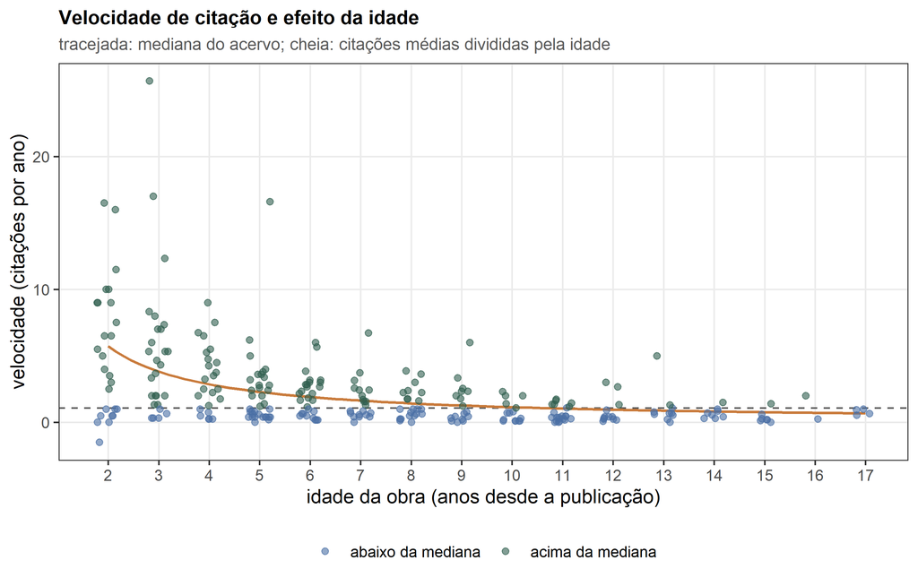

Figura 10: Velocidade de citação em função da idade da obra. A linha tracejada é a mediana do acervo e a linha cheia é a razão citações por idade.

```r
# 4.7 Dispersão idade por velocidade com mediana e reta de referência
d_v <- traj
d_v$acima <- ifelse(d_v$velocity >= median(d_v$velocity), "acima da mediana", "abaixo da mediana")
idade_max <- max(d_v$age)

g_vel <- ggplot(d_v, aes(x = age, y = velocity)) +
  geom_hline(yintercept = median(d_v$velocity), linetype = "dashed",
             colour = "grey35", linewidth = .45) +
  stat_function(fun = function(a) mean(d_v$citations) / a, colour = pal_agri[2],
                linewidth = .7, linetype = "solid") +
  geom_jitter(aes(colour = acima), width = .22, height = 0, alpha = .6, size = 1.5) +
  scale_colour_manual(values = c("acima da mediana" = pal_agri[1],
                                 "abaixo da mediana" = pal_agri[3]), name = NULL) +
  scale_x_continuous(breaks = sort(unique(d_v$age))) +
  labs(x = "idade da obra (anos desde a publicação)",
       y = "velocidade (citações por ano)",
       title = "Velocidade de citação e efeito da idade",
       subtitle = "tracejada: mediana do acervo; cheia: citações médias divididas pela idade")

sup_med <- sum(d_v$velocity >= median(d_v$velocity))
g_vel
```

A Figura tem três leituras. A primeira é que a mediana separa o acervo em 140 obras acima e 140 abaixo, e a fronteira é convencional: metade do acervo fica de cada lado por definição, e um artigo que destaque apenas a metade superior estará destacando metade da literatura. A segunda é que a velocidade cai com a idade, com coeficiente de correlação de -0.43, porque cada ano adicional no denominador reduz a razão enquanto as citações não acompanham. A terceira é a reta cheia, que é a velocidade *esperada* de uma obra com o número médio de citações do acervo: tudo o que fica acima dela recebeu mais do que o padrão da frente, e é essa a lista que serve para montar um estado da arte. O acervo sintético é generoso com obras recentes porque as citações foram sorteadas sem memória temporal; em acervo real, a cauda recente é sempre mais curta.

## 8.4 Mudança de composição temática

A produção que cresce em volume pode estar crescendo em qualquer direção. Para saber em qual, é preciso olhar o conteúdo e não só o número de documentos. A tabela de palavras-chave normalizadas do acervo permite contar menções por bloco temático e por período, e o resultado é a segunda assinatura temporal deste módulo.

```r
# 4.8 Blocos temáticos derivados das palavras-chave normalizadas
kw <- x_analise$keywords
kw$ano <- x_analise$works$year[match(kw$work_id, x_analise$works$work_id)]
kw$periodo <- ifelse(kw$ano >= 2020L, "2020-2025", "2010-2019")

blocos_tema <- list(
  "Silicio"  = c("silicon", "silicon fertilization", "salinity", "sorghum", "rice",
                 "nutrient uptake", "abiotic stress", "drought stress"),
  "Carbono"  = c("soil carbon", "cover crops", "no-till", "soil organic matter",
                 "carbon sequestration", "soil aggregation", "crop rotation",
                 "green manure"),
  "Automacao" = c("machine learning", "deep learning", "uav", "hyperspectral",
                  "remote sensing", "yield prediction", "vegetation index",
                  "phenotyping"))
kw$bloco <- NA_character_
for (b in names(blocos_tema)) kw$bloco[kw$keyword %in% blocos_tema[[b]]] <- b
stopifnot(!any(is.na(kw$bloco)))       # todo termo do acervo pertence a um bloco

# 4.9 Menções por bloco em cada período, normalizadas pelo número de obras
cont_bloco <- as.data.frame(table(kw$bloco, kw$periodo), stringsAsFactors = FALSE)
names(cont_bloco) <- c("bloco", "periodo", "mencoes")
obras_per <- table(kw$periodo[!duplicated(kw$work_id)])
cont_bloco$obras <- as.integer(obras_per[cont_bloco$periodo])
cont_bloco$por_obra <- cont_bloco$mencoes / cont_bloco$obras

comp <- reshape(cont_bloco[, c("bloco", "periodo", "por_obra")],
                idvar = "bloco", timevar = "periodo", direction = "wide")
names(comp) <- c("bloco", "antes", "recente")
comp$variacao <- 100 * (comp$recente / comp$antes - 1)
comp$antes <- round(comp$antes, 2); comp$recente <- round(comp$recente, 2)
comp$variacao <- round(comp$variacao, 1)
comp <- comp[order(-comp$variacao), ]

knitr::kable(comp, row.names = FALSE,
  caption = "Composição temática do acervo por período: menções de palavras-chave por obra em cada bloco temático.")
```

Tabela 18: Composição temática do acervo por período: menções de palavras-chave por obra em cada bloco temático.

Composição temática do acervo por período: menções de palavras-chave por obra em cada bloco temático.

| bloco | antes | recente | variacao |
| --- | --- | --- | --- |
| Automacao | 0.72 | 1.36 | 90.1 |
| Carbono | 1.26 | 1.43 | 14.1 |
| Silicio | 2.08 | 1.94 | -6.4 |

A Tabela é a evidência da verdade plantada V4 do acervo simulado. O bloco de automação passa de 0.72 para 1.36 menções por obra, uma variação de 90.1 por cento, enquanto os dois blocos agronômicos variam 14.1 e -6.4 por cento. Traduzindo: das 280 menções acrescentadas pelo período recente, 47.5 por cento vêm do bloco de automação. É por isso que a curva de produção do acervo cresce e, ao mesmo tempo, muda de assunto: o crescimento recente não é uma repetição ampliada do que já havia.

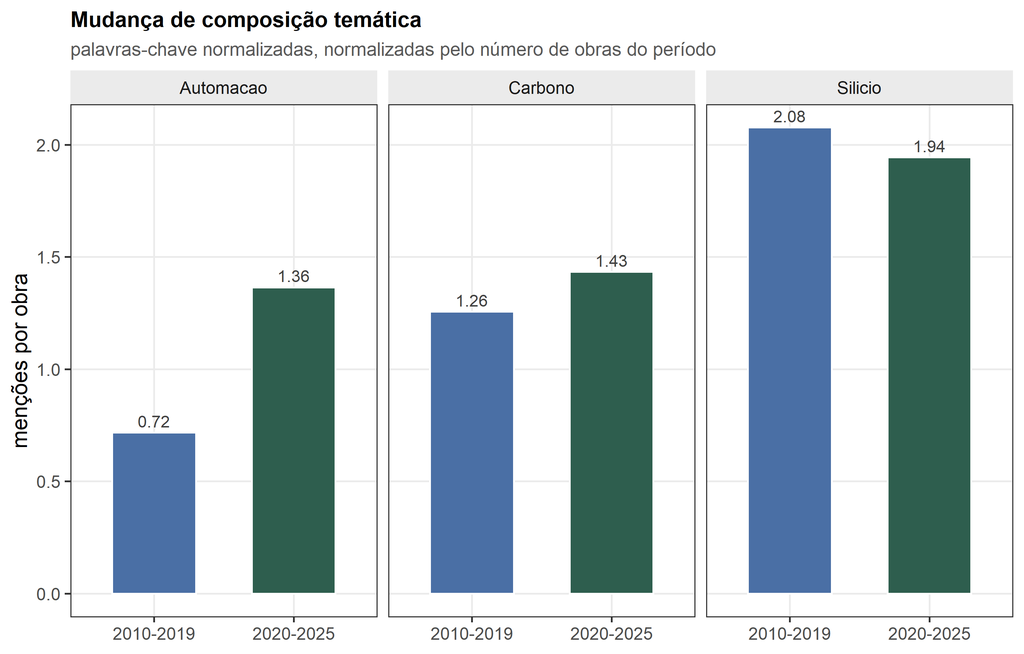

Figura 11: Menções de palavras-chave por obra em cada bloco temático, por período. A ordem dos blocos é a da variação entre os dois períodos.

```r
# 4.10 Composição temática por período, com o bloco ordenado pela variação
cont_bloco$bloco <- factor(cont_bloco$bloco, levels = comp$bloco)
cont_bloco$periodo <- factor(cont_bloco$periodo, levels = c("2010-2019", "2020-2025"))

ggplot(cont_bloco, aes(x = periodo, y = por_obra, fill = periodo)) +
  geom_col(width = .6, colour = "white") +
  geom_text(aes(label = sprintf("%.2f", por_obra)), vjust = -.45,
            size = 2.9, colour = "grey25") +
  facet_wrap(~ bloco, nrow = 1) +
  scale_fill_manual(values = c("2010-2019" = pal_agri[3], "2020-2025" = pal_agri[1]),
                    guide = "none") +
  labs(x = NULL, y = "menções por obra", title = "Mudança de composição temática",
       subtitle = "palavras-chave normalizadas, normalizadas pelo número de obras do período")
```

## 8.5 RPYS: quais anos de referência fundam a frente

Até aqui contamos obras publicadas. O RPYS faz a pergunta invertida: olhando às referências citadas pelo acervo, quais *anos* aparecem com frequência desproporcional? Um pico nesse espectro é a assinatura de uma obra fundadora, porque dezenas de trabalhos independentes decidiram citar algo publicado naquele mesmo ano.

A primeira coisa a saber sobre a função é a forma do argumento. `rpys()` recebe um **vetor de anos**, não um projeto bibliométrico: ela não tem como ler as referências citadas de dentro do `biblio_project`, porque o objeto guarda as arestas de citação entre as obras do próprio acervo, e não a lista de referências de cada obra. Esses anos vêm do campo de referências citadas da exportação, e tanto Web of Science quanto Scopus e OpenAlex o fornecem. Este acervo simulado não traz esse campo, então a seção constrói um vetor declaradamente simulado.

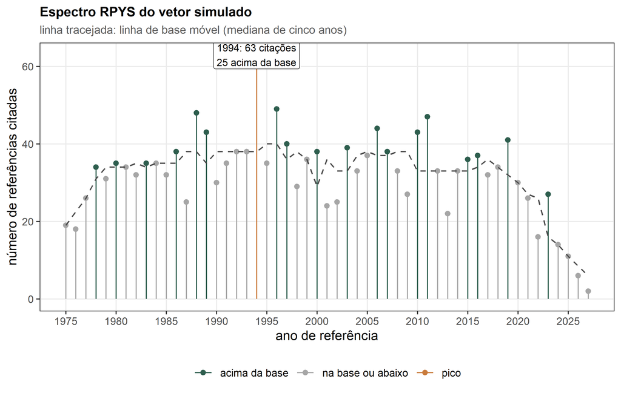

Figura 12: Espectro de anos de referência (RPYS) do vetor de citações simulado: contagem observada por ano, linha de base móvel e o ano de maior desvio positivo em destaque.

```r
# 4.11 Vetor SIMULADO de anos de referência: para cada obra, seis referências
#      sorteadas na janela de 45 anos anteriores, mais um ano seminal plantado.
set.seed(SEED)
ref_sim <- unlist(lapply(x_analise$works$year, function(a) {
  sample(seq(max(1975L, a - 45L), a + 2L), 6L, replace = TRUE)
}))
ref_sim <- c(ref_sim, rep(1994L, 26L))     # ano seminal plantado nesta simulação

rp <- rpys(reference_years = ref_sim, window = 2)
pico <- rp[which.max(rp$deviation), ]
rp$acima <- ifelse(rp$deviation > 0, "acima da base", "na base ou abaixo")
rp$acima[rp$year == pico$year] <- "pico"

ggplot(rp, aes(x = year, y = n, colour = acima)) +
  geom_segment(aes(xend = year, y = 0, yend = n), linewidth = .45) +
  geom_point(size = 1.7) +
  geom_line(aes(x = year, y = baseline), colour = "grey30",
            linetype = "dashed", linewidth = .55) +
  annotate("label", x = pico$year, y = pico$n, size = 3,
           label = sprintf("%d: %d citações\n%d acima da base", pico$year,
                           pico$n, pico$deviation)) +
  scale_colour_manual(values = c("acima da base" = pal_agri[1],
                                 "na base ou abaixo" = "grey65",
                                 "pico" = pal_agri[2]), name = NULL) +
  scale_x_continuous(breaks = seq(min(rp$year), max(rp$year), by = 5)) +
  labs(x = "ano de referência", y = "número de referências citadas",
       title = "Espectro RPYS do vetor simulado",
       subtitle = "linha tracejada: linha de base móvel (mediana de cinco anos)")
```

O espectro tem a forma esperada. A linha de base é uma mediana móvel de cinco anos e serve de piso local, não de média global: a função mede o desvio contra a vizinhança, e não contra o acervo inteiro. O ano de 1994 reúne 63 referências contra uma base de 38, um desvio de 25. Os anos seguintes em desvio são 2011 (desvio 14) e 2023 (desvio 11). O pico é o que foi plantado: 26 referências foram atribuídas ao ano 1994 de propósito, e a função o recupera sem que ninguém tenha dito a ela onde olhar. Esta é uma **simulação declarada**: o campo de referências citadas não existe no objeto, e um RPYS sobre dados reais exige o vetor extraído da exportação.

```r
# 4.12 Anos de maior desvio positivo do espectro
rp_top <- head(rp[order(-rp$deviation), c("year", "n", "baseline", "deviation")], 5L)
knitr::kable(rp_top, row.names = FALSE, digits = 1,
  caption = "Anos de maior desvio positivo do espectro RPYS: contagem observada, linha de base móvel e desvio.")
```

Tabela 19: Anos de maior desvio positivo do espectro RPYS: contagem observada, linha de base móvel e desvio.

Anos de maior desvio positivo do espectro RPYS: contagem observada, linha de base móvel e desvio.

| year | n | baseline | deviation |
| --- | --- | --- | --- |
| 1994 | 63 | 38 | 25 |
| 2011 | 47 | 33 | 14 |
| 2023 | 27 | 16 | 11 |
| 1988 | 48 | 38 | 10 |
| 2010 | 43 | 33 | 10 |

Duas armadilhas acompanham esse resultado. A primeira é confundir pico de referência com pico de publicação. O espectro não conta quantos artigos foram publicados em 1994; conta quantas referências do acervo apontam para algo publicado naquele ano. Um ano de intensa produção científica produz muitos candidatos, mas só gera pico de RPYS se as obras daquele ano continuarem sendo citadas por este acervo específico, o que depende da frente e não do calendário. Para deixar a distinção concreta: `temporal_growth()` conta 10 obras publicadas em 2014 neste acervo, e isso nada diz sobre quantas referências do acervo apontam para 2014; são duas contagens sobre objetos diferentes.

A segunda armadilha é o valor de `window`. Ele controla a largura da mediana móvel e, portanto, quão local é a comparação. Testar valores diferentes é parte da análise, e o resultado aqui é informativo: com `window` de 1, 2, 3, 5 o topo do espectro continua sendo 1994, com o mesmo desvio de 25. Um pico que sobrevive à mudança da largura da janela é um achado robusto; um pico que aparece só numa largura é artefato da suavização. Vale rodar sempre mais de um valor antes de eleger o ano fundador de uma frente.

## 8.6 Disrupção: separar inovação de consolidação

A última função do módulo troca a pergunta de novo. Em vez de “quantas vezes este trabalho foi citado”, ela pergunta “quem o citou deixou de citar o que ele citava?”. A resposta vem de uma decomposição em três contagens a partir de uma tabela de arestas de citação.

O pacote exige que a tabela tenha exatamente as colunas `citing_id` e `cited_id`, e para com mensagem clara quando elas não existem. Isso é validação de entrada, e vale ver funcionando, porque é o tipo de erro que consome uma tarde de quem trabalha com exportação de base: cada base nomeia as colunas de citação de um jeito, e o nome errado não produz número errado, produz parada.

```r
# 4.13 Exemplo numérico controlado: F é o focal, R1 e R2 são suas referências
arestas <- data.frame(
  citing_id = c("C1", "C2", "C3", "C4", "C5", "C6", "C7"),
  cited_id  = c("F", "F", "F", "R1", "R1", "R2", "F"), stringsAsFactors = FALSE)

di_focal <- disruption_index("F", arestas, c("R1", "R2"))          # 4 citantes de F
di_cons  <- disruption_index(                                       # C4 também cita F
  "F", rbind(arestas, data.frame(citing_id = "C4", cited_id = "F")), c("R1", "R2"))
di_ausente <- disruption_index("ZZZ", arestas, c("R1", "R2"))       # focal inexistente
di_semref  <- disruption_index("F", arestas, character(0))          # sem referências

di_tab <- rbind(
  cbind(cenario = "4 citantes, nenhum consolidador", di_focal),
  cbind(cenario = "C4 passa a citar também as referências", di_cons),
  cbind(cenario = "focal sem nenhum citante no acervo", di_ausente),
  cbind(cenario = "focal sem referências declaradas", di_semref))
knitr::kable(di_tab[, c("cenario", "focal_id", "N_i", "N_j", "N_k", "disruption")],
  row.names = FALSE, digits = 2,
  caption = "Exemplo numérico do índice de disrupção em quatro cenários de arestas de citação, com a decomposição em N_i, N_j e N_k.")
```

Tabela 20: Exemplo numérico do índice de disrupção em quatro cenários de arestas de citação, com a decomposição em N_i, N_j e N_k.

Exemplo numérico do índice de disrupção em quatro cenários de arestas de citação, com a decomposição em N_i, N_j e N_k.

| cenario | focal_id | N_i | N_j | N_k | disruption |
| --- | --- | --- | --- | --- | --- |
| 4 citantes, nenhum consolidador | F | 4 | 0 | 3 | 0.57 |
| C4 passa a citar também as referências | F | 4 | 1 | 2 | 0.43 |
| focal sem nenhum citante no acervo | ZZZ | 0 | 0 | 3 | 0.00 |
| focal sem referências declaradas | F | 4 | 0 | 0 | 1.00 |

A validação de entrada funciona como prometido, e vale conferir com os próprios olhos, porque uma função que devolvesse `NA` em silêncio produziria uma tabela de aparência normal com um número inventado. O bloco seguinte repete a chamada com uma tabela de arestas nomeada como o `export_biblio()` a exporta, com `from` e `to`, e captura a mensagem com `tryCatch()`.

```r
# 4.14 O mesmo cálculo com uma tabela de arestas mal nomeada
arestas_erradas <- data.frame(from = c("C1", "C2"), to = c("F", "R1"),
                              stringsAsFactors = FALSE)
msg_colunas <- tryCatch(
  disruption_index("F", arestas_erradas, c("R1", "R2")),
  error = function(e) conditionMessage(e))
msg_colunas_limpa <- sub("[.]$", "", msg_colunas)   # a mensagem já traz ponto final

knitr::kable(
  data.frame(entrada = "data.frame(from, to)",
             colunas_esperadas = "citing_id, cited_id",
             resposta_do_pacote = msg_colunas),
  row.names = FALSE,
  caption = "Mensagem devolvida pelo pacote quando a tabela de arestas não tem as colunas citing_id e cited_id.")
```

Tabela 21: Mensagem devolvida pelo pacote quando a tabela de arestas não tem as colunas citing_id e cited_id.

Mensagem devolvida pelo pacote quando a tabela de arestas não tem as colunas citing_id e cited_id.

| entrada | colunas_esperadas | resposta_do_pacote |
| --- | --- | --- |
| data.frame(from, to) | citing_id, cited_id | citation_edges must have columns ‘citing_id’ and ‘cited_id’. |

A mensagem devolvida é citation_edges must have columns ‘citing_id’ and ‘cited_id’. Ela é útil por três motivos: diz qual argumento está errado, diz quais colunas eram esperadas e não sugere que o problema esteja nos dados. Compare com o comportamento de uma função que apenas devolvesse zero: o zero entraria no seu ranking de disrupção como uma obra perfeitamente consolidada. Renomeie as colunas da sua exportação antes da análise, e não depois de olhar o resultado.

A fórmula é `(N_i - N_j) / (N_i + N_j + N_k)`, e cada contagem tem um significado preciso. `N_i` são os citantes que **não** citam nenhuma referência do focal: frente citante que ignorou o passado que o focal invocou, ou seja, disrupção. `N_j` são os citantes que citam o focal **e** as referências dele: seguiram a trilha inteira, ou seja, consolidação. `N_k` são os citantes que citam as referências do focal mas não citam o focal: trabalham o mesmo passado sem passar por ele. O índice vai de -1 a 1, e o zero é o ponto de equilíbrio.

Os dois últimos cenários são avisos de leitura. Um identificador que não existe no acervo devolve `N_i` igual a 0 e índice 0, e esse zero **não significa equilíbrio**: significa ausência de dado, e um zero por ausência entra em média e em ranking como se fosse medição. Declarar as referências do focal é o que separa disrupção de consolidação, e quando a lista vem vazia o índice devolve 1, o valor máximo, porque toda citação sem trilha declarada é contada como rompimento. Antes de publicar qualquer índice de disrupção, confira quantas obras do acervo têm referências declaradas.

```r
# 4.15 Perfil de citação das referências declaradas do acervo
refs_x <- x_analise$references
obras_com_ref <- length(unique(refs_x$citing_id))
txt_pares <- sprintf("%d par%s obra-referência", nrow(refs_x),
                     if (nrow(refs_x) == 1L) "" else "es")
resumo_ref <- data.frame(
  item = c("obras no acervo", "obras com referências declaradas",
           "pares obra-referência declarados"),
  valor = c(nrow(x_analise$works), obras_com_ref, nrow(refs_x)))

knitr::kable(resumo_ref, row.names = FALSE,
  caption = "Cobertura das referências declaradas no acervo analítico, condição necessária para interpretar o índice de disrupção.")
```

Tabela 22: Cobertura das referências declaradas no acervo analítico, condição necessária para interpretar o índice de disrupção.

Cobertura das referências declaradas no acervo analítico, condição necessária para interpretar o índice de disrupção.

| item | valor |
| --- | --- |
| obras no acervo | 280 |
| obras com referências declaradas | 0 |
| pares obra-referência declarados | 0 |

A Tabela fecha a condição de uso do índice. Das 280 obras do acervo, 0 têm referências declaradas, e a tabela de citações reúne 0 pares obra-referência. Sem essa cobertura, o índice de disrupção não é calculável para o acervo inteiro, e qualquer média publicada seria calculada sobre um subconjunto não declarado. É por isso que a função exige as referências do focal como argumento explícito, em vez de tentar adivinhá-las: ela prefere devolver um resultado que você pode auditar a devolver um número que ninguém sabe de onde veio.

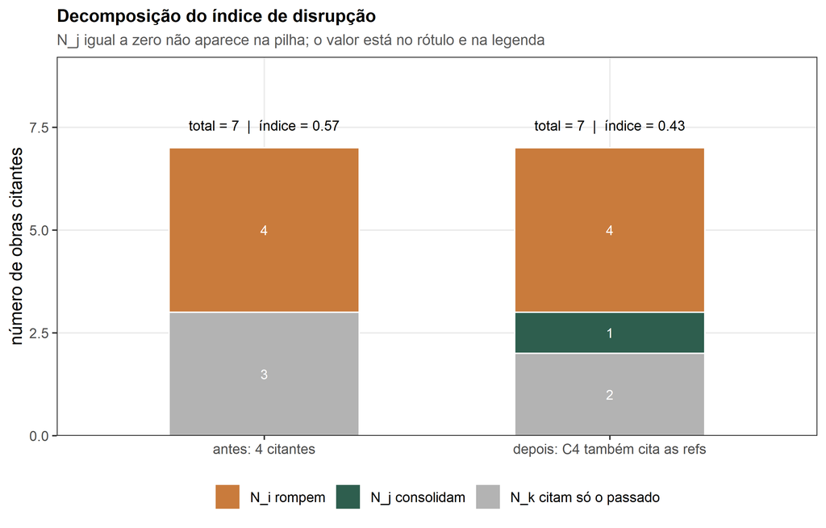

Figura 13: Decomposição do índice de disrupção nos três grupos de citantes, para os dois cenários em que o focal existe no acervo. O total de citantes é o mesmo nos dois cenários, e apenas a composição muda.

```r
# 4.16 Decomposição dos dois cenários com focal presente, em barras empilhadas
d_di <- data.frame(
  cenario = factor(rep(c("antes: 4 citantes", "depois: C4 também cita as refs"),
                       each = 3L),
                   levels = c("antes: 4 citantes", "depois: C4 também cita as refs")),
  grupo = rep(c("N_i rompem", "N_j consolidam", "N_k citam só o passado"), 2L),
  n = c(di_focal$N_i, di_focal$N_j, di_focal$N_k,
        di_cons$N_i, di_cons$N_j, di_cons$N_k),
  indice = rep(c(di_focal$disruption, di_cons$disruption), each = 3L),
  total = rep(c(di_focal$N_i + di_focal$N_j + di_focal$N_k,
                di_cons$N_i + di_cons$N_j + di_cons$N_k), each = 3L))

ggplot(d_di, aes(x = cenario, y = n, fill = grupo)) +
  geom_col(width = .55, colour = "white") +
  # rótulo só nas fatias com altura suficiente para receber texto
  geom_text(aes(label = ifelse(n >= 1L, n, "")),
            position = position_stack(vjust = .5), size = 3, colour = "white") +
  # o total e o índice de cada cenário, acima da barra
  geom_text(data = d_di[!duplicated(d_di$cenario), ],
            aes(x = cenario, y = total + .55,
                label = paste0("total = ", total, "  |  índice = ",
                               sprintf("%.2f", indice))),
            inherit.aes = FALSE, size = 3.1) +
  scale_fill_manual(values = c("N_i rompem" = pal_agri[2],
                               "N_j consolidam" = pal_agri[1],
                               "N_k citam só o passado" = "grey70"), name = NULL) +
  scale_y_continuous(expand = expansion(mult = c(0, .22))) +
  labs(x = NULL, y = "número de obras citantes",
       title = "Decomposição do índice de disrupção",
       subtitle = "N_j igual a zero não aparece na pilha; o valor está no rótulo e na legenda")
```

Um detalhe de implementação que vale registrar, porque volta a aparecer em qualquer gráfico de composição: uma fatia de altura zero não é desenhada, de modo que `N_j` igual a 0 no primeiro cenário não tem barra verde. O número está no rótulo e na contagem do texto, e a alternativa de inflar a fatia para torná-la visível seria pior, porque apresentaria um valor falso. Em uma figura de artigo, a solução é a mesma: declarar na legenda que o valor nulo está omitido por construção. A consequência prática, para o doutorando em Agronomia, é que o índice de disrupção complementa e não substitui a contagem de citações: a contagem mede atenção recebida, o índice mede como essa atenção se posicionou em relação ao que o trabalho propôs.

## 8.7 Tarefas do Módulo 4

**Tarefa 4.1 (aplicar).** Use `citation_velocity()` sobre o acervo real do OpenAlex, que está no objeto `x_openalex`, e compare a mediana da velocidade com a do acervo simulado. Depois rode `disruption_index()` sobre uma tabela de arestas construída por você, com as colunas `citing_id` e `cited_id`, e mostre o índice resultante. Se a chamada ao OpenAlex falhou nesta máquina, rode a tarefa sobre `x_analise` e diga por quê.

**Tarefa 4.2 (analisar).** Construa um vetor de anos de referência com um ano seminal plantado por você, diferente de 1994, rode `rpys()` com dois valores de `window` e responda: o pico que você plantou aparece nas duas configurações? O que a resposta diz sobre a robustez do achado? Em seguida, explique em um parágrafo por que um pico de RPYS não pode ser lido como pico de produção científica daquele ano.

**DicaAntes de seguir**

O argumento `window` de `rpys()` e a lista de referências de `disruption_index()` são os dois pontos em que este módulo depende de decisão do analista, e não do pacote. Registre os dois valores no seu script: daqui a seis meses, o número no artigo não será reproduzível sem eles.

# 9 Módulo 5. Análise textual e tópicos

## 9.1 O problema agronômico

Depois de importar, limpar e descrever o acervo, o doutorando em Agronomia chega à pergunta que motivou a revisão: sobre o que esses trabalhos falam, e o que mudou no vocabulário deles ao longo do tempo? A resposta não sai da contagem de documentos, porque um acervo que dobra de tamanho pode continuar usando as mesmas palavras. Ela sai do texto. Título e palavras-chave são os dois campos textuais que toda exportação bibliográfica traz preenchidos, e é sobre eles que este módulo trabalha.

Há uma armadilha imediata nesse caminho, e ela não é conceitual: é administrativa. Toda base exportada carrega ruído que não tem significado científico algum — códigos de amostra, numeração de ensaio, identificadores de lote, prefixos de projeto. Esse ruído é frequente justamente porque é sistemático, e um contador de termos o colocará no topo da lista, acima de qualquer conceito agronômico. Quem não faz a limpeza publica uma tabela de códigos e chama aquilo de análise temática.

O terceiro problema é de interpretação, e é onde a maioria dos artigos escorrega. Existem dois números diferentes em jogo: a frequência de um termo no acervo e o poder discriminante de um termo entre estratos. Um termo pode ser o mais frequente de todos e não distinguir nada, porque aparece igualmente em todos os anos; e um termo pode ser raro e ser exatamente o que separa um estrato do outro. Este módulo mostra os dois números, a fórmula que os combina e a leitura correta de cada um.

## 9.2 Frequência de termos e a etapa de limpeza

A função `term_frequency()` tokeniza o campo textual, converte para minúsculas, descarta tokens com até dois caracteres e remove uma lista de palavras vazias. O argumento `field` aceita apenas `"title"` ou `"abstract"`. O acervo simulado tem os dois campos, mas o campo de resumo está vazio em todas as obras, de modo que a análise sobre resumo devolve zero linhas — e é importante que isso apareça como resultado vazio, e não como erro, para que ninguém conclua que a função falhou.

```r
# 5.1 Frequência bruta no campo de títulos
tf_bruto <- term_frequency(x_analise, field = "title")

# 5.2 Limpeza: termo administrativo declarado como palavra vazia e tokens numéricos
tf_filt <- term_frequency(x_analise, field = "title", stopwords = c("estudo"))
tf_limpo <- tf_filt[!grepl("^[0-9]+$", tf_filt$term), ]

# 5.3 Quantificação da limpeza
limpeza <- data.frame(
  metrica = c("termos distintos na saída bruta",
              "termos distintos após a limpeza",
              "ocorrências totais na saída bruta",
              "ocorrências totais após a limpeza",
              "tokens puramente numéricos descartados",
              "ocorrências do termo administrativo"),
  valor = c(nrow(tf_bruto), nrow(tf_limpo),
            sum(tf_bruto$n), sum(tf_limpo$n),
            sum(grepl("^[0-9]+$", tf_bruto$term)),
            tf_bruto$n[tf_bruto$term == "estudo"]))

# 5.4 Top 15 dos dois estados, lado a lado
top_bruto <- head(tf_bruto, 15L)
cmp <- data.frame(termo = top_bruto$term, n_bruto = top_bruto$n)
cmp$n_limpo <- tf_limpo$n[match(cmp$termo, tf_limpo$term)]

knitr::kable(cmp, row.names = FALSE,
  caption = "Top 15 termos do campo de títulos antes e depois da limpeza. A célula ausente na coluna de depois é o termo que a limpeza removeu por completo, e a coluna de antes é sempre a contagem da saída bruta.")
```

Tabela 23: Top 15 termos do campo de títulos antes e depois da limpeza. A coluna ‘depois’ é a contagem do termo no acervo já filtrado.

Top 15 termos do campo de títulos antes e depois da limpeza. A célula ausente na coluna de depois é o termo que a limpeza removeu por completo, e a coluna de antes é sempre a contagem da saída bruta.

| termo | n_bruto | n_limpo |
| --- | --- | --- |
| estudo | 279 | NA |
| abiótico | 139 | 139 |
| estresse | 139 | 139 |
| silício | 139 | 139 |
| tolerância | 139 | 139 |
| carbono | 93 | 93 |
| cobertura | 93 | 93 |
| plantas | 93 | 93 |
| solo | 93 | 93 |
| arroz | 47 | 47 |
| culturas | 47 | 47 |
| fenotipagem | 47 | 47 |
| remoto | 47 | 47 |
| sensoriamento | 47 | 47 |
| soja | 42 | 42 |

A comparação entre as duas colunas é o conteúdo da tabela. Na saída bruta, o termo mais frequente é estudo, com 279 ocorrências, seguido de abiótico e estresse, com 139 cada. Nenhum dos três é conceito agronômico: o primeiro é vocabulário administrativo, porque cada título do acervo termina com o sufixo `(estudo NNN)`, e os outros dois são palavras do próprio objeto de estudo. Os tokens puramente numéricos são 278 termos distintos, cada um aparecendo no máximo 2 vez, o que os deixa baixos na tabela e ainda assim responsáveis por 14.3 por cento de todas as ocorrências. Ruído administrativo não precisa estar no topo para contaminar a análise; basta existir em quantidade.

A estatística que justifica a limpeza está nas contagens agregadas: a saída bruta tem 1953 ocorrências em 298 termos distintos, e o termo administrativo mais os códigos numéricos respondem por 558 ocorrências, ou 28.6 por cento do total. Depois da limpeza, os termos distintos caem para 19 e as ocorrências para 1395, de modo que 71.4 por cento do volume original sobrevive. Esse é o ponto que a limpeza precisa justificar: ela não pode jogar fora sinal junto com ruído, e aqui ela descarta 28.6 por cento do volume para manter a lista inteiramente composta de termos agronômicos.

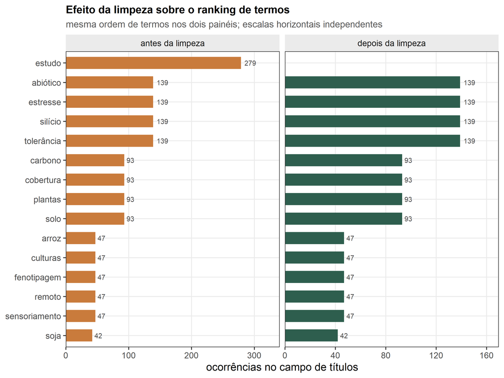

Figura 14: Top 15 termos do campo de títulos antes e depois da limpeza, em dois painéis com a mesma ordem de termos.

```r
# 5.5 Dois painéis: antes e depois da limpeza, na mesma ordem de termos
n_painel <- min(15L, nrow(top_bruto), nrow(tf_limpo))
d_tf <- rbind(
  data.frame(termo = top_bruto$term[seq_len(n_painel)],
             estado = "antes da limpeza", n = top_bruto$n[seq_len(n_painel)]),
  data.frame(termo = tf_limpo$term[seq_len(n_painel)],
             estado = "depois da limpeza", n = tf_limpo$n[seq_len(n_painel)]))
# a ordem dos termos é a do topo bruto, e é a mesma nos dois painéis
d_tf$termo <- factor(d_tf$termo, levels = rev(top_bruto$term[seq_len(n_painel)]))
# termos que só aparecem na saída bruta ficam sem nível e saem do gráfico
d_tf <- d_tf[!is.na(d_tf$termo), ]
stopifnot(all(!is.na(d_tf$termo)))
d_tf$estado <- factor(d_tf$estado, levels = c("antes da limpeza", "depois da limpeza"))

ggplot(d_tf, aes(x = n, y = termo, fill = estado)) +
  geom_col(width = .62) +
  geom_text(aes(label = n), hjust = -.3, size = 2.5, colour = "grey30") +
  facet_wrap(~ estado, ncol = 2, scales = "free_x") +
  scale_fill_manual(values = c("antes da limpeza" = pal_agri[2],
                               "depois da limpeza" = pal_agri[1]), guide = "none") +
  scale_x_continuous(expand = expansion(mult = c(0, .22))) +
  labs(x = "ocorrências no campo de títulos", y = NULL,
       title = "Efeito da limpeza sobre o ranking de termos",
       subtitle = "mesma ordem de termos nos dois painéis; escalas horizontais independentes")
```

A Figura mostra o efeito completo da limpeza em dois painéis com a mesma ordem de termos, de modo que a comparação é linha a linha. No painel da esquerda, o acervo como exportado, e a linha de estudo salta aos olhos: as barras laranja registram 279 ocorrências desse termo. No painel da direita, o acervo depois do filtro, e essa linha simplesmente não existe, porque o termo saiu da análise. Os termos agronômicos sobem para o topo da lista, e abiótico lidera com 139 ocorrências, seguido de estresse e silício, com 139 cada. Nenhum termo da lista depurada tem dígito no nome, o que confirma que o filtro numérico e a lista de palavras vazias atacaram exatamente o alvo.

Vale um aviso sobre o argumento de palavras vazias, porque ele é uma fonte de surpresa. O valor de `stopwords` **substitui** a lista padrão, e não a complementa. Nos títulos deste acervo nada muda, porque são portugueses e não contêm as palavras vazias inglesas do padrão, mas em um acervo com títulos em inglês passar apenas `c("estudo")` faria “the”, “of” e “and” voltarem ao topo. Se você precisa das duas listas, escreva as duas juntas no argumento.

```r
# 5.6 O campo abstract existe, mas está vazio em todas as obras
tem_abstract <- sum(!is.na(x_analise$works$abstract) &
                    nzchar(trimws(x_analise$works$abstract)))
tf_abstract <- term_frequency(x_analise, field = "abstract")
campo_invalido <- tryCatch(term_frequency(x_analise, field = "journal"),
                           error = function(e) conditionMessage(e))

estado_abstract <- data.frame(
  situacao = c("obras com resumo preenchido",
               "linhas devolvidas por field = 'abstract'",
               "resposta a um campo inexistente"),
  resultado = c(tem_abstract, nrow(tf_abstract), campo_invalido))

knitr::kable(estado_abstract, row.names = FALSE,
  caption = "Tentativas de análise sobre o campo de resumo: o acervo simulado não tem resumos preenchidos e a função devolve zero linhas.")
```

Tabela 24: Tentativas de análise sobre o campo de resumo: o acervo simulado não tem resumos preenchidos e a função devolve zero linhas.

Tentativas de análise sobre o campo de resumo: o acervo simulado não tem resumos preenchidos e a função devolve zero linhas.

| situacao | resultado |
| --- | --- |
| obras com resumo preenchido | 0 |
| linhas devolvidas por field = ‘abstract’ | 0 |
| resposta a um campo inexistente | ‘arg’ should be one of “title”, “abstract” |

Esse pequeno quadro merece atenção porque separa dois comportamentos que parecem iguais e não são. Pedir um campo válido e vazio devolve um quadro de zero linhas, sem aviso: é um resultado, e o resultado diz que não há texto naquele campo. Pedir um campo que não existe para como erro, com a mensagem ‘arg’ should be one of “title”, “abstract”. Um pipeline que trate os dois casos como “deu problema” vai ou parar onde deveria seguir, ou seguir onde deveria parar. Aqui, o campo de resumo existe em `x_analise$works` mas está vazio nas 280 obras, de modo que toda a análise textual deste módulo usa títulos e, adiante, a tabela de palavras-chave.

## 9.3 Frequência direta das palavras-chave

Título é texto livre, e o vocabulário dele depende de estilo de redação. A tabela de palavras-chave do acervo é outra coisa: são conceitos que os autores declararam, já normalizados em minúsculas pelo pacote. Para medir temas, essa tabela é o caminho mais curto, e `term_frequency()` não a alcança, porque só lê título e resumo.

```r
# 5.7 Frequência direta da tabela de palavras-chave normalizadas
kw <- x_analise$keywords
kw$ano <- x_analise$works$year[match(kw$work_id, x_analise$works$work_id)]
kw$periodo <- ifelse(kw$ano >= 2020L, "2020-2025", "2010-2019")
kw <- kw[!is.na(kw$keyword) & nzchar(kw$keyword), ]

freq_kw <- as.data.frame(table(kw$keyword, kw$periodo), stringsAsFactors = FALSE)
names(freq_kw) <- c("keyword", "periodo", "n")

# 5.8 Menções por termo e período, normalizadas pelo número de obras do período
obras_per <- table(kw$periodo[!duplicated(kw$work_id)])
freq_kw$por_obra <- freq_kw$n / as.integer(obras_per[freq_kw$periodo])

# 5.9 Taxa por obra em cada período: separa crescimento do acervo de adoção do termo
taxa_kw <- reshape(freq_kw[, c("keyword", "periodo", "por_obra")],
                   idvar = "keyword", timevar = "periodo", direction = "wide")
names(taxa_kw) <- c("keyword", "taxa_antes", "taxa_recente")
taxa_kw$razao <- taxa_kw$taxa_recente / pmax(taxa_kw$taxa_antes, 1e-9)

freq_wide <- reshape(freq_kw[, c("keyword", "periodo", "n")],
                     idvar = "keyword", timevar = "periodo", direction = "wide")
names(freq_wide) <- c("keyword", "antes", "recente")
freq_wide$antes[is.na(freq_wide$antes)] <- 0L
freq_wide$recente[is.na(freq_wide$recente)] <- 0L
freq_wide$total <- freq_wide$antes + freq_wide$recente
freq_wide$variacao <- round(100 * (freq_wide$recente / pmax(freq_wide$antes, 1L) - 1), 1)
kw_top <- head(freq_wide[order(-freq_wide$total), ], 12L)

# 5.10 Quantos dos doze termos da figura ganham densidade por obra
no_top <- taxa_kw$keyword %in% kw_top$keyword
n_sobe <- sum(taxa_kw$razao[no_top] > 1)
n_desce <- sum(taxa_kw$razao[no_top] <= 1)

knitr::kable(kw_top, row.names = FALSE,
  caption = "Frequência das palavras-chave normalizadas em cada período, com a variação percentual entre os dois períodos.")
```

Tabela 25: Frequência das palavras-chave normalizadas em cada período, com a variação percentual entre os dois períodos.

Frequência das palavras-chave normalizadas em cada período, com a variação percentual entre os dois períodos.

| keyword | antes | recente | total | variacao |
| --- | --- | --- | --- | --- |
| nutrient uptake | 35 | 42 | 77 | 20.0 |
| drought stress | 36 | 40 | 76 | 11.1 |
| silicon fertilization | 30 | 46 | 76 | 53.3 |
| silicon | 33 | 36 | 69 | 9.1 |
| rice | 28 | 37 | 65 | 32.1 |
| abiotic stress | 28 | 36 | 64 | 28.6 |
| sorghum | 27 | 37 | 64 | 37.0 |
| salinity | 26 | 35 | 61 | 34.6 |
| green manure | 24 | 32 | 56 | 33.3 |
| deep learning | 11 | 41 | 52 | 272.7 |
| no-till | 20 | 32 | 52 | 60.0 |
| machine learning | 8 | 43 | 51 | 437.5 |

[figure not shown]

```r
# 5.10 Contagens absolutas e taxa por obra na mesma figura
freq_kw$keyword <- factor(freq_kw$keyword, levels = rev(kw_top$keyword))

ggplot(freq_kw[!is.na(freq_kw$keyword), ], aes(x = n, y = keyword, fill = periodo)) +
  geom_col(position = position_dodge(width = .74), width = .7) +
  geom_point(aes(x = por_obra * mean(freq_kw$n), colour = periodo),
             position = position_dodge(width = .74), size = 1.8, show.legend = FALSE) +
  scale_fill_manual(values = c("2010-2019" = pal_agri[3], "2020-2025" = pal_agri[1]),
                    name = NULL) +
  scale_colour_manual(values = c("2010-2019" = pal_agri[3], "2020-2025" = pal_agri[1])) +
  labs(x = "menções no acervo", y = NULL,
       title = "Palavras-chave por período",
       subtitle = "barras: menções absolutas; pontos: menções por obra do período, na mesma escala")
```

Esta é a lição central do módulo, e ela cabe em uma frase: em um acervo que cresce, contagem absoluta cresce com ele e não informa nada sobre adoção. O que mede adoção é a taxa por obra, e é ela que sustenta a afirmação sobre mudança de vocabulário. Um artigo que apresente apenas as barras dirá que todos os temas cresceram, quando o dado mostra que 7 dos doze termos perderam densidade e 5 ganharam.

## 9.4 TF-IDF: o que distingue um estrato

Frequência mede presença no acervo inteiro. TF-IDF mede presença em um estrato relativamente ao resto. A função `tfidf_terms()` calcula, para cada termo e cada grupo, o número de documentos que contêm o termo no grupo multiplicado pelo logaritmo da razão entre o número de grupos e o número de grupos em que o termo aparece. O argumento `group` só aceita nomes de coluna de `x$works`, e dois deles são os que fazem sentido: `"year"` e `"source"`.

```r
# 5.9 TF-IDF por ano e limpeza do mesmo ruído administrativo
ti_bruto <- tfidf_terms(x_analise, group = "year")
ti <- ti_bruto[!grepl("^[0-9]+$", ti_bruto$term) & !ti_bruto$term %in% c("estudo"), ]
ti_top <- head(ti[order(-ti$tfidf), c("term", "group", "n", "df", "tfidf")], 10L)

knitr::kable(ti_top, row.names = FALSE, digits = 3,
  caption = "Top 10 termos por TF-IDF no agrupamento por ano, com a frequência no estrato, o número de anos em que o termo ocorre e o valor do índice.")
```

Tabela 26: Top 10 termos por TF-IDF no agrupamento por ano, com a frequência no estrato, o número de anos em que o termo ocorre e o valor do índice.

Top 10 termos por TF-IDF no agrupamento por ano, com a frequência no estrato, o número de anos em que o termo ocorre e o valor do índice.

| term | group | n | df | tfidf |
| --- | --- | --- | --- | --- |
| pastagem | 2016 | 6 | 11 | 2.248 |
| pastagem | 2024 | 6 | 11 | 2.248 |
| pastagem | 2021 | 5 | 11 | 1.873 |
| pastagem | 2022 | 5 | 11 | 1.873 |
| trigo | 2021 | 6 | 12 | 1.726 |
| trigo | 2024 | 6 | 12 | 1.726 |
| pastagem | 2025 | 4 | 11 | 1.499 |
| trigo | 2022 | 5 | 12 | 1.438 |
| feijão | 2022 | 6 | 13 | 1.246 |
| trigo | 2018 | 4 | 12 | 1.151 |

Aqui está o resultado que organiza a interpretação de todo índice de discriminação. O termo com o maior TF-IDF é pastagem, com índice 2.248, frequência de 6 no estrato 2016 e ocorrência em 11 anos de um total de 16. O termo mais frequente do acervo, abiótico, tem TF-IDF de 0 — e o índice é zero justamente porque o termo aparece em **todos** os anos. O logaritmo de um dividido por um é zero, e essa é a propriedade que dá sentido ao índice: um termo onipresente não distingue estrato algum, por mais frequente que seja.

Traduzindo para a prática da escrita científica: TF-IDF alto com `df` baixo é assinatura de um termo que caracteriza um recorte específico do acervo. No material analisado, os termos com índice acima de 1 são feijão, pastagem, trigo, e nenhum deles é vocabulário de tema: são palavras de cultura e de sistema de manejo, que distinguem um trabalho dos demais pelo objeto cultivado e não pela frente de pesquisa. Se a sua pergunta é temática, esse resultado é ruído útil: ele mostra que o acervo é heterogêneo em cultura e homogêneo em tema, o que é uma informação sobre o desenho da amostra e sobre o cuidado necessário ao ler uma nuvem de palavras construída sobre títulos.

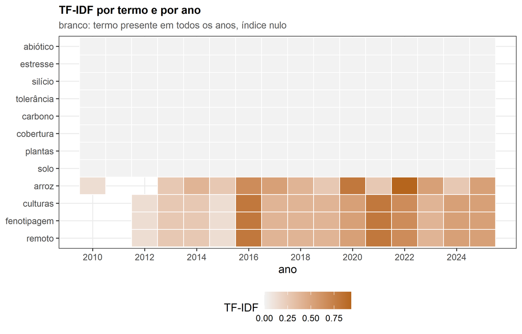

Figura 16: Mapa de calor do TF-IDF dos doze termos mais frequentes do acervo ao longo dos anos. A escala vai do branco, para índice nulo, ao laranja, e os anos não cobertos pelo termo ficam sem célula.

```r
# 5.10 Mapa de calor do TF-IDF por termo e por ano
termos_topo <- head(tf_limpo$term, 12L)
d_hm <- ti[ti$term %in% termos_topo, ]
d_hm$term <- factor(d_hm$term, levels = rev(termos_topo))
d_hm$ano <- as.integer(d_hm$group)

ggplot(d_hm, aes(x = ano, y = term, fill = tfidf)) +
  geom_tile(colour = "white", linewidth = .35) +
  scale_fill_gradient(low = "#F2F2F2", high = pal_agri[6], na.value = "#F2F2F2",
                      name = "TF-IDF") +
  scale_x_continuous(breaks = seq(min(d_hm$ano), max(d_hm$ano), by = 2)) +
  labs(x = "ano", y = NULL,
       title = "TF-IDF por termo e por ano",
       subtitle = "branco: termo presente em todos os anos, índice nulo")
```

## 9.5 Evolução dos tópicos e chegada do vocabulário de automação

A terceira função do módulo trabalha diretamente sobre a tabela de palavras-chave e responde à pergunta de evolução. `trend_topics()` conta, para cada ano e cada palavra-chave, quantas obras a declararam, e devolve as colunas `year`, `keyword` e `n`. O único argumento opcional é `min_total`, que descarta termos com menos de um número mínimo de menções no acervo inteiro.

```r
# 5.11 Tendência por ano e por termo
tr <- trend_topics(x_analise)
tot_termo <- sort(tapply(tr$n, tr$keyword, sum), decreasing = TRUE)
top5 <- names(tot_termo)[1:5]
anos <- sort(unique(tr$year))

# 5.12 Preenchimento explícito das combinações ano-termo ausentes
grade <- expand.grid(year = anos, keyword = top5, stringsAsFactors = FALSE)
grade <- merge(grade, tr, all.x = TRUE)
grade$n[is.na(grade$n)] <- 0L
faltantes <- sum(!paste(grade$year, grade$keyword) %in%
                 paste(tr$year, tr$keyword))

grade_wide <- reshape(grade, idvar = "year", timevar = "keyword", direction = "wide")
names(grade_wide) <- sub("^n\\.", "", names(grade_wide))
grade_wide <- grade_wide[order(grade_wide$year), ]
knitr::kable(grade_wide, row.names = FALSE,
  caption = "Evolução dos cinco termos mais frequentes do acervo, por ano, com as células ausentes preenchidas com zero.")
```

Tabela 27: Evolução dos cinco termos mais frequentes do acervo, por ano, com as células ausentes preenchidas com zero.

Evolução dos cinco termos mais frequentes do acervo, por ano, com as células ausentes preenchidas com zero.

| year | drought stress | nutrient uptake | rice | silicon | silicon fertilization |
| --- | --- | --- | --- | --- | --- |
| 2010 | 1 | 0 | 1 | 2 | 0 |
| 2011 | 1 | 1 | 0 | 1 | 0 |
| 2012 | 1 | 3 | 1 | 3 | 2 |
| 2013 | 2 | 2 | 1 | 2 | 2 |
| 2014 | 4 | 0 | 1 | 3 | 3 |
| 2015 | 3 | 4 | 2 | 2 | 3 |
| 2016 | 6 | 6 | 6 | 4 | 6 |
| 2017 | 6 | 6 | 4 | 5 | 2 |
| 2018 | 5 | 5 | 5 | 6 | 5 |
| 2019 | 8 | 8 | 8 | 6 | 8 |
| 2020 | 7 | 7 | 4 | 5 | 5 |
| 2021 | 8 | 10 | 8 | 9 | 8 |
| 2022 | 6 | 8 | 9 | 7 | 11 |
| 2023 | 5 | 5 | 8 | 8 | 8 |
| 2024 | 8 | 7 | 6 | 4 | 9 |
| 2025 | 8 | 6 | 4 | 5 | 7 |

O preenchimento das células ausentes é a parte do código que não pode ser omitida, e vale entender por quê. A função agrega apenas as combinações que existem no dado, de modo que um termo ausente em um ano simplesmente não tem linha. Ao montar a grade completa com todas as combinações de ano e termo, o número de células que precisaram de zero é 5. Sem esse passo, uma série plotada em linha teria buracos que o gráfico interpreta como descontinuidade da publicação, quando o que houve foi ausência de menção. Zero e ausência são coisas diferentes em bibliometria, e a diferença some quando se plota direto a saída da agregação.

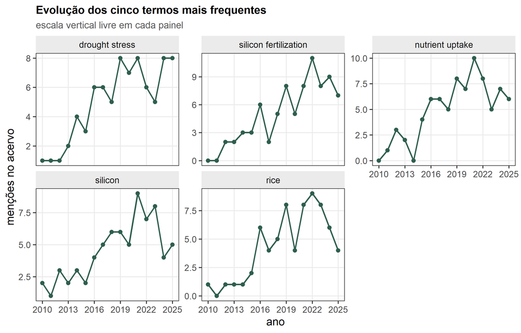

Figura 17: Evolução anual dos cinco termos de palavra-chave mais frequentes do acervo, em painéis separados, com escala livre por painel.

```r
# 5.13 Séries dos cinco termos, em painéis com escala livre
grade$keyword <- factor(grade$keyword, levels = top5)
ggplot(grade, aes(x = year, y = n)) +
  geom_line(colour = pal_agri[1], linewidth = .7) +
  geom_point(colour = pal_agri[1], size = 1.5) +
  facet_wrap(~ keyword, ncol = 3, scales = "free_y") +
  scale_x_continuous(breaks = seq(min(anos), max(anos), by = 3)) +
  labs(x = "ano", y = "menções no acervo",
       title = "Evolução dos cinco termos mais frequentes",
       subtitle = "escala vertical livre em cada painel")
```

A Figura mostra o que a contagem agregada esconde. Os cinco termos mais frequentes do acervo pertencem ao vocabulário da frente de silício e estresse abiótico, e todos crescem ao longo do período, mas o crescimento deles é irregular: em 2010 o acervo tem 4 menções entre os cinco termos, e em 2025 tem 30. A escala livre por painel é deliberada: sem ela, os cinco painéis ficariam na mesma escala e os termos menos frequentes virariam linhas retas no chão do gráfico. Com ela, cada painel mostra a *forma* de sua série, e a comparação entre painéis passa a ser sobre forma, não sobre nível — o que exige que a legenda diga isso, como diz.

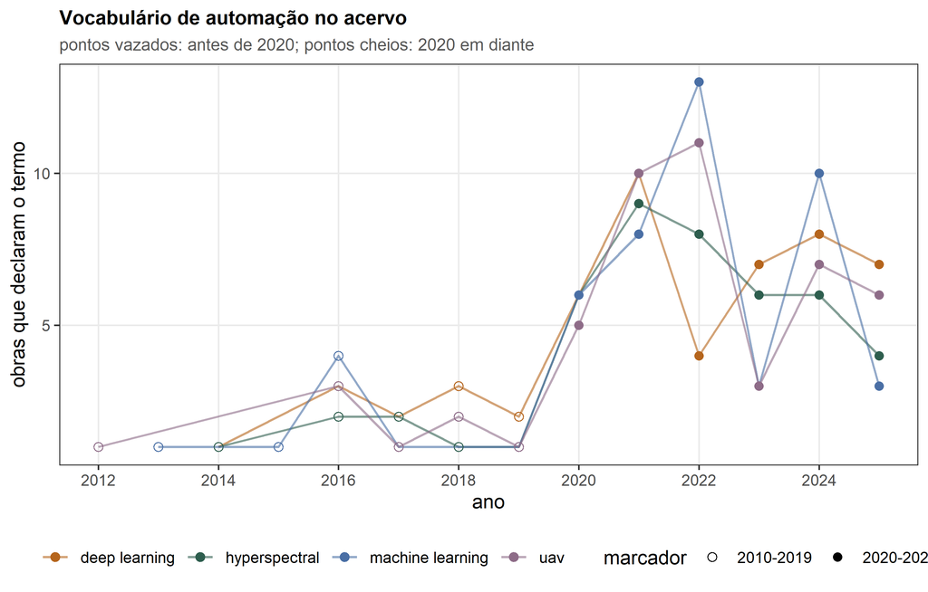

Figura 18: Chegada do vocabulário de automação ao acervo: menções anuais de aprendizado de máquina, aprendizado profundo, VANT e imageamento hiperespectral.

```r
# 5.14 Verdade plantada V4: vocabulário de automação por ano
termos_ia <- c("machine learning", "deep learning", "uav", "hyperspectral")
pal_ia <- c("machine learning" = pal_agri[3], "deep learning" = pal_agri[6],
            "uav" = pal_agri[4], "hyperspectral" = pal_agri[1])
ia <- tr[tr$keyword %in% termos_ia, ]
ia$fase <- ifelse(ia$year >= 2020L, "2020-2025", "2010-2019")

ggplot(ia, aes(x = year, y = n, colour = keyword)) +
  geom_line(linewidth = .6, alpha = .6) +
  geom_point(aes(shape = fase), size = 2.1, fill = "white") +
  scale_colour_manual(values = pal_ia, name = NULL) +
  scale_shape_manual(values = c("2010-2019" = 1, "2020-2025" = 16),
                     name = "marcador") +
  scale_x_continuous(breaks = seq(min(ia$year), max(ia$year), by = 2)) +
  labs(x = "ano", y = "obras que declaram o termo",
       title = "Vocabulário de automação no acervo",
       subtitle = "pontos vazados: antes de 2020; pontos cheios: 2020 em diante")
```

Essa diferença entre contar menções e contar obras não é detalhe de implementação, e é a razão de a verdade plantada precisar de duas leituras. Quando um acervo cresce, toda contagem absoluta cresce com ele; o que mede adoção de vocabulário é a fração de obras que adotam, e essa fração é comparável entre períodos de tamanhos diferentes. Em dado real, uma frente metodológica vizinha entra em cena exatamente assim: primeiro em um número pequeno de trabalhos, depois como vocabulário corrente, sem que ninguém anuncie a virada. É a contagem por obra, e não a contagem de menções, que mostra o momento.

```r
# 5.15 Frequência total contra número de anos: por que o termo mais frequente não discrimina
df_por_termo <- aggregate(df ~ term, ti, max)
tot_por_termo <- tf_limpo
comp_disc <- merge(tot_por_termo, df_por_termo, by.x = "term", by.y = "term",
                   all.x = TRUE)
comp_disc$tfidf_max <- vapply(comp_disc$term, function(t)
  max(ti$tfidf[ti$term == t]), numeric(1))
comp_disc <- comp_disc[order(-comp_disc$n), c("term", "n", "df", "tfidf_max")]
top_disc <- head(comp_disc, 3L)
top_disc_baixo <- head(comp_disc[order(comp_disc$df, -comp_disc$n), ], 3L)

knitr::kable(rbind(top_disc, top_disc_baixo), row.names = FALSE, digits = 3,
  caption = "Relação entre frequência e poder discriminante: os três termos mais frequentes do acervo, o número de anos em que ocorrem e o TF-IDF máximo.")
```

Tabela 28: Relação entre frequência e poder discriminante: os três termos mais frequentes do acervo, o número de anos em que ocorrem e o TF-IDF máximo.

Relação entre frequência e poder discriminante: os três termos mais frequentes do acervo, o número de anos em que ocorrem e o TF-IDF máximo.

| term | n | df | tfidf_max |
| --- | --- | --- | --- |
| abiótico | 139 | 16 | 0.000 |
| estresse | 139 | 16 | 0.000 |
| silício | 139 | 16 | 0.000 |
| pastagem | 38 | 11 | 2.248 |
| trigo | 41 | 12 | 1.726 |
| feijão | 40 | 13 | 1.246 |

A tabela fecha o argumento com os dois extremos lado a lado. Os três termos mais frequentes ocorrem em 16 dos 16 anos e têm TF-IDF máximo de 0: são onipresentes e, por construção do índice, não distinguem estrato algum. Os três termos mais concentrados ocorrem em 11, 12, 13 anos e chegam a TF-IDF de 2.248. Um artigo que precise justificar a escolha de um termo para representar um período tem aqui o critério: frequência alta com `df` alto descreve o acervo inteiro, frequência moderada com `df` baixo descreve uma fase dele. Vale registrar o que o índice **não** faz: ele não mede relevância agronômica nem qualidade científica, e um termo com TF-IDF zero pode ser o conceito central da frente, como é o caso aqui.

## 9.6 Tarefas do Módulo 5

**Tarefa 5.1 (aplicar).** Rode `term_frequency()` sobre o campo de títulos com e sem o argumento `stopwords`, informe quantos termos e quantas ocorrências cada versão devolve e explique em duas frases por que a diferença entre as duas versões precisa ser declarada no Material e Métodos do artigo. Depois rode `tfidf_terms()` com `group = "source"` e diga o que muda na interpretação em relação ao agrupamento por ano.

**Tarefa 5.2 (analisar).** Use `trend_topics()` para montar a série anual de um termo de automação da sua escolha, preencha as células ausentes com zero e escreva um parágrafo de Resultados com a mudança de nível entre os períodos. Em seguida, compare a série do termo escolhido com a série do termo mais frequente do acervo e explique por que a conclusão sobre “o que cresce” depende de qual dos dois números, frequência ou discriminação, você usou.

**DicaAntes de seguir**

Guarde o vetor `top5` e a grade completa em um objeto com nome próprio. O Módulo 6 agrupa o mesmo acervo por período e por tema, e a comparação entre os dois caminhos, contagem textual e teste de associação, é o que mostra a diferença entre descrever e testar.

# 10 Módulo 6. Comparação de grupos com inferência por permutação

## 10.1 O problema agronômico

Suponha que você fechou um levantamento sobre silício e estresse abiótico com 280 obras publicadas entre 2010 e 2025 e queira responder a uma pergunta que a descritiva não responde: **o vocabulário da área mudou depois de 2020?** A resposta importa para quem escreve a introdução de um projeto. Se os termos de automação e aprendizado de máquina aparecem mais nas obras recentes, o projeto precisa de uma frente de fenotipagem e análise de imagem; se aparecem igualmente nos dois períodos, essa frente é opcional. Note que a pergunta não é sobre contagem absoluta — os períodos nem têm o mesmo número de obras — e sim sobre o **padrão de associação** entre pertencer a um período e empregar um termo.

O obstáculo é que a inferência clássica sobre tabelas de contingência pressupõe casos independentes e frequências esperadas razoáveis em cada célula. Aqui as unidades não são independentes: uma obra traz quatro ou cinco palavras-chave ligadas ao mesmo tema, o mesmo autor assina várias obras, e os grupos que interessam ao agrônomo raramente são disjuntos. Um trabalho sobre silício aplicado por sensoriamento remoto pertence a dois temas ao mesmo tempo. O teste de qui-quadrado assintótico, além disso, não foi desenhado para um desenho de observação em que os rótulos dos grupos foram atribuídos pelo pesquisador e poderiam, em princípio, ter caído em qualquer outra obra do acervo.

A saída que o `biblioIntegrator` adota é a **inferência por permutação**. Em vez de comparar a estatística observada a uma distribuição teórica, o pacote reembaralha os rótulos de grupo entre as obras centenas de vezes, recalcula a estatística em cada reembaralhamento e mede com que frequência o acaso produz associação tão forte quanto a observada. Esse desenho não exige normalidade nem células grandes, e o p-valor passa a significar exatamente o que o agrônomo imagina que ele significa: a proporção de reordenamentos do acervo em que a associação seria tão forte quanto a encontrada. Este módulo ensina a construir os grupos, a rodar o teste, a interpretar os resíduos célula por célula e a medir o tamanho do efeito — porque p-valor pequeno não é sinônimo de achado importante.

## 10.2 Do rótulo de grupo à matriz de pertencimento

A função `form_groups()` não devolve uma lista: ela devolve uma **matriz de pertencimento** com uma linha por obra e uma coluna por grupo, valendo `1` quando a obra pertence ao grupo e `0` quando não pertence. É essa matriz que todas as funções do módulo recebem, e é ela que explica por que o pacote consegue lidar com grupos que se cruzam.

```r
# dplyr::between faz a mesma coisa, mas aqui basta comparar
g_per <- form_groups(x_analise, ifelse(x_analise$works$year >= 2020, "2020-2025", "2010-2019"))
tema_B <- ifelse(grepl("^Silício", x_analise$works$title), "silicio",
                 ifelse(grepl("^Carbono", x_analise$works$title), "carbono", "remoto"))
g_tema <- form_groups(x_analise, tema_B)

# a classe do objeto e a dimensao sao a primeira coisa a conferir
cat("classe de g_per:", paste(class(g_per), collapse = "/"), "\n")
```

```
#> classe de g_per: matrix/array
```

```r
cat("dimensoes:", paste(dim(g_per), collapse = " x "), "\n")
```

```
#> dimensoes: 280 x 2
```

```r
cat("dimensoes de g_tema:", paste(dim(g_tema), collapse = " x "), "\n")
```

```
#> dimensoes de g_tema: 280 x 3
```

```r
# rownames sao os identificadores das obras: a matriz fica amarrada ao acervo
cat("primeiras obras:", paste(head(rownames(g_per), 3), collapse = ", "), "\n")
```

```
#> primeiras obras: W000474d7, W0004d050, W0004d133
```

```r
# a soma de cada coluna e o tamanho do grupo
tamanhos <- data.frame(
  matriz = c(rep("periodo", ncol(g_per)), rep("tema", ncol(g_tema))),
  grupo = c(colnames(g_per), colnames(g_tema)),
  trabalhos = c(colSums(g_per), colSums(g_tema)))
knitr::kable(tamanhos, row.names = FALSE,
             caption = "Grupos construídos por form_groups() e o tamanho de cada um nos 280 trabalhos do acervo analítico.")
```

Grupos construídos por form_groups() e o tamanho de cada um nos 280 trabalhos do acervo analítico.

| matriz | grupo | trabalhos |
| --- | --- | --- |
| periodo | factor(groups)2010-2019 | 119 |
| periodo | factor(groups)2020-2025 | 161 |
| tema | factor(groups)carbono | 93 |
| tema | factor(groups)remoto | 48 |
| tema | factor(groups)silicio | 139 |

O objeto tem 280 linhas (uma por obra) e 2 colunas no caso do período e 3 colunas no caso do tema. Note os nomes das colunas: `form_groups()` gera `factor(groups)2010-2019` e `factor(groups)carbono` porque converte o vetor de rótulos em fator antes de montar a matriz. São nomes feios, e a partir daqui a convenção do tutorial é limpá-los na exibição e nunca reescrever a matriz, porque a ordem das colunas é a ordem em que as linhas das tabelas de saída aparecem. Os períodos ficaram desbalanceados — 119 obras antes de 2020 e 161 a partir de 2020 — e os temas mais ainda, com 139 obras de silício contra 48 de sensoriamento remoto. O desbalanceamento é a regra em levantamentos bibliográficos, e é uma das razões para não confiar apenas no teste assintótico.

**NotaPor que a matriz e não um vetor**

Um vetor de rótulos só admite grupos mutuamente exclusivos: cada obra pertence a um período ou a um tema. A matriz admite a obra de sensoriamento remoto que também é de silício. Todas as funções deste módulo aceitam as duas formas, e a diferença aparece no campo `$overlap` do resultado, que comentamos adiante.

## 10.3 O que está associado a quê: a tabela de contingência

Antes de testar, vale olhar a tabela. O objeto devolvido por `compare_groups()` guarda a matriz observada, a esperada sob independência e os resíduos, e o contraste entre as duas primeiras é toda a matéria-prima da inferência.

```r
cmp_per <- compare_groups(x_analise, g_per, entity = "keyword",
                          permutations = 499, seed = SEED)

# a matriz observada tem uma linha por grupo e uma coluna por termo
obs <- cmp_per$observed
# para caber na pagina, mostramos os oito termos mais frequentes
top8 <- names(sort(colSums(obs), decreasing = TRUE))[1:8]
tab_obs <- data.frame(grupo = rownames(obs), obs[, top8, drop = FALSE], check.names = FALSE)
tab_esp <- data.frame(grupo = rownames(obs), round(cmp_per$expected[, top8, drop = FALSE], 1),
                      check.names = FALSE)
knitr::kable(tab_obs, row.names = FALSE, digits = 0,
             caption = "Tabela de contingência observada: número de obras de cada período que empregam cada um dos oito termos mais frequentes.")
knitr::kable(tab_esp, row.names = FALSE, digits = 1,
             caption = "A mesma tabela sob independência: o que se esperaria se período e vocabulário nada tivessem a ver um com o outro.")
```

Tabela 29: A mesma tabela sob independência: o que se esperaria se período e vocabulário nada tivessem a ver um com o outro.

| grupo | nutrient uptake | drought stress | silicon fertilization | silicon | rice | abiotic stress | sorghum | salinity |
| --- | --- | --- | --- | --- | --- | --- | --- | --- |
| factor(groups)2010-2019 | 35 | 36 | 30 | 33 | 28 | 28 | 27 | 26 |
| factor(groups)2020-2025 | 42 | 40 | 46 | 36 | 37 | 36 | 37 | 35 |

| grupo | nutrient uptake | drought stress | silicon fertilization | silicon | rice | abiotic stress | sorghum | salinity |
| --- | --- | --- | --- | --- | --- | --- | --- | --- |
| factor(groups)2010-2019 | 29.7 | 29.3 | 29.3 | 26.6 | 25.1 | 24.7 | 24.7 | 23.5 |
| factor(groups)2020-2025 | 47.3 | 46.7 | 46.7 | 42.4 | 39.9 | 39.3 | 39.3 | 37.5 |

A obra analítica tem 280 registros, 24 termos distintos e 16 autores. A tabela observada soma 1228 pares obra-termo, e essa soma é o `n` de todos os cálculos que vêm a seguir. A leitura das duas tabelas lado a lado é a chave do módulo: onde o observado supera o esperado há associação positiva, onde fica abaixo há associação negativa, e a pergunta que a inferência responde é se essas diferenças são maiores do que o reembaralhamento produziria.

## 10.4 Inferência por permutação: dois contrastes, dois tamanhos de efeito

Agora rodamos o teste nos dois agrupamentos. O contraste entre os resultados é o ensinamento mais importante do módulo, e ele não aparece se você olhar apenas o p-valor.

```r
cmp_tema <- compare_groups(x_analise, g_tema, entity = "keyword",
                           permutations = 499, seed = SEED)
# 499 permutacoes fixam o menor p-valor possivel em 1/(499+1)
cat("p-valor minimo alcancavel com 499 permutacoes:", 1 / (499 + 1), "\n\n")
```

```
#> p-valor minimo alcancavel com 499 permutacoes: 0.002
```

```r
resumo <- data.frame(
  contraste = c("periodo (2 grupos)", "tema (3 grupos)"),
  grupos = c(nrow(cmp_per$observed), nrow(cmp_tema$observed)),
  qui_quadrado = round(c(cmp_per$chi_square, cmp_tema$chi_square), 1),
  graus_de_liberdade = c((nrow(cmp_per$observed) - 1) * (ncol(cmp_per$observed) - 1),
                         (nrow(cmp_tema$observed) - 1) * (ncol(cmp_tema$observed) - 1)),
  p_valor = c(cmp_per$p_value, cmp_tema$p_value),
  V_de_Cramer = round(c(cmp_per$cramers_v, cmp_tema$cramers_v), 3),
  sobrepostos = c(cmp_per$overlap, cmp_tema$overlap))
knitr::kable(resumo, row.names = FALSE,
             caption = "Resultado da inferência por permutação nos dois contrastes: mesmo número de permutações e mesma semente, tamanhos de efeito muito diferentes.")
```

Resultado da inferência por permutação nos dois contrastes: mesmo número de permutações e mesma semente, tamanhos de efeito muito diferentes.

| contraste | grupos | qui_quadrado | graus_de_liberdade | p_valor | V_de_Cramer | sobrepostos |
| --- | --- | --- | --- | --- | --- | --- |
| periodo (2 grupos) | 2 | 54.2 | 23 | 0.002 | 0.210 | FALSE |
| tema (3 grupos) | 3 | 1952.3 | 46 | 0.002 | 0.892 | FALSE |

O primeiro contraste compara os dois períodos. A estatística de qui-quadrado vale 54.2 e o p-valor é 0.002. Esse número não deve ser lido como “0,002 exato”: com 499 permutações, o p-valor é `(1 + número de permutações tão extremas quanto) / (permutações + 1)`, de modo que 0.002 é o menor valor alcançável. O que a saída diz é que **nenhum** dos 499 reembaralhamentos produziu associação tão forte quanto a observada. Para refinar, aumente `permutations` — a conclusão não muda, apenas a resolução do número.

O achado substantivo está no tamanho do efeito. O V de Cramér vale 0.21, que é associação **moderada e fraca**. Traduzindo para a pergunta agronômica: os termos de automação aparecem mais no período recente, e a diferença é grande demais para ser atribuída ao acaso, mas está longe de ser uma regra. A maioria das obras de qualquer período usa o vocabulário comum da área.

O segundo contraste compara os três temas derivados do título. O qui-quadrado salta para 1952.3 — cerca de 36 vezes o primeiro — e o V de Cramér vai a 0.892, associação muito forte. O que isso significa em termos de campo é quase trivial: cada frente de pesquisa usa o seu próprio vocabulário, e uma obra sobre carbono do solo fala de plantio direto e não de silício. É o resultado esperado e não é uma descoberta.

Vale medir essa diferença de um terceiro modo, porque o tamanho do efeito moderado merece uma noção de incerteza. O argumento `bootstrap` acrescenta um intervalo de confiança ao V de Cramér, obtido por reamostragem das obras.

```r
cmp_per_ic <- compare_groups(x_analise, g_per, entity = "keyword",
                             permutations = 499, bootstrap = 50, seed = SEED)
cmp_tema_ic <- compare_groups(x_analise, g_tema, entity = "keyword",
                              permutations = 499, bootstrap = 50, seed = SEED)
ic <- data.frame(
  contraste = c("periodo", "tema"),
  V = round(c(cmp_per_ic$cramers_v, cmp_tema_ic$cramers_v), 3),
  inferior = round(c(cmp_per_ic$cramers_v_ci[1], cmp_tema_ic$cramers_v_ci[1]), 3),
  superior = round(c(cmp_per_ic$cramers_v_ci[2], cmp_tema_ic$cramers_v_ci[2]), 3))
knitr::kable(ic, row.names = FALSE,
             caption = "V de Cramér com intervalo de confiança de 95% obtido por reamostragem das obras (bootstrap = 50), nos dois contrastes.")
```

V de Cramér com intervalo de confiança de 95% obtido por reamostragem das obras (bootstrap = 50), nos dois contrastes.

| contraste | V | inferior | superior |
| --- | --- | --- | --- |
| periodo | 0.210 | 0.201 | 0.305 |
| tema | 0.892 | 0.877 | 0.909 |

O contraste por período tem V de 0.21 com intervalo de 0.201 a 0.305; o contraste por tema, V de 0.892 com intervalo de 0.877 a 0.909. Os dois intervalos não se tocam, o que confirma em outra escala o que o V já dizia: são associações de ordens de grandeza diferentes. O intervalo do primeiro contraste não chega a zero: mesmo no limite inferior da reamostragem, a associação entre período e vocabulário é real, apenas modesta.

A lição metodológica é o contraste. Os dois contrastes têm p = 0.002 e p = 0.002: **o p-valor não distingue um achado de uma trivialidade**. Ele mede apenas se o acaso, sozinho, explicaria o padrão, e com 280 obras o acaso raramente explica qualquer coisa. Quem mede a importância é o V de Cramér, que varia de 0 a 1 e é comparável entre tabelas de tamanhos diferentes. Escrever “associação altamente significativa (p < 0,01)” para o contraste por período, sem informar o V, comunica ao leitor que existe um achado forte quando o que existe é um achado moderado.

## 10.5 Resíduos: quais células fogem do esperado

Saber que existe associação não diz **onde** ela está. A função `association_residuals()` devolve uma linha por célula da tabela, com o valor observado, o esperado e o resíduo padronizado de Pearson. A convenção de leitura é direta: sob independência, os resíduos têm desvio-padrão próximo de 1, de modo que valores além de `2` em módulo marcam células que fogem do esperado.

```r
res_per <- association_residuals(cmp_per)
res_tema <- association_residuals(cmp_tema)
cat("celulas na tabela de periodo:", nrow(res_per), "\n")
```

```
#> celulas na tabela de periodo: 48
```

```r
cat("celulas na tabela de tema:", nrow(res_tema), "\n")
```

```
#> celulas na tabela de tema: 72
```

```r
cat("residuos alem de 2 em modulo, periodo:", sum(abs(res_per$residual) > 2), "\n")
```

```
#> residuos alem de 2 em modulo, periodo: 8
```

```r
cat("residuos alem de 2 em modulo, tema:", sum(abs(res_tema$residual) > 2), "\n\n")
```

```
#> residuos alem de 2 em modulo, tema: 69
```

```r
# min_abs e um filtro de conveniencia: nao recalcula nada, so seleciona linhas
fortes <- association_residuals(cmp_per, min_abs = 2)
fortes <- fortes[order(-abs(fortes$residual)), ]
fortes$grupo <- sub("^factor\\(groups\\)", "", fortes$group)
knitr::kable(fortes[, c("grupo", "entity", "obs" = "observed", "esp" = "expected", "residuo" = "residual")],
             row.names = FALSE, digits = c(0, 0, 0, 1, 2),
             caption = "Células cujo resíduo padronizado de Pearson excede 2 em módulo no contraste por período: são estas, e não outras, que sustentam a associação.")
```

Tabela 30: Células cujo resíduo padronizado de Pearson excede 2 em módulo no contraste por período: são estas, e não outras, que sustentam a associação.

| grupo | entity | observed | expected | residual |
| --- | --- | --- | --- | --- |
| 2010-2019 | machine learning | 8 | 19.7 | -3.43 |
| 2020-2025 | machine learning | 43 | 31.3 | 3.43 |
| 2010-2019 | uav | 8 | 19.3 | -3.35 |
| 2020-2025 | uav | 42 | 30.7 | 3.35 |
| 2020-2025 | hyperspectral | 38 | 27.6 | 3.24 |
| 2010-2019 | hyperspectral | 7 | 17.4 | -3.24 |
| 2010-2019 | deep learning | 11 | 20.1 | -2.64 |
| 2020-2025 | deep learning | 41 | 31.9 | 2.64 |

No contraste por tema o quadro é outro: 69 das 72 células passam do limiar. Isso não significa que o segundo resultado seja mais confiável, e sim que a associação por tema é forte em quase todas as células, o que é exatamente o comportamento de um vocabulário que acompanha a frente de pesquisa.

A figura Figura 19 mostra os dois conjuntos de resíduos no mesmo painel, com as linhas de referência em ±2.

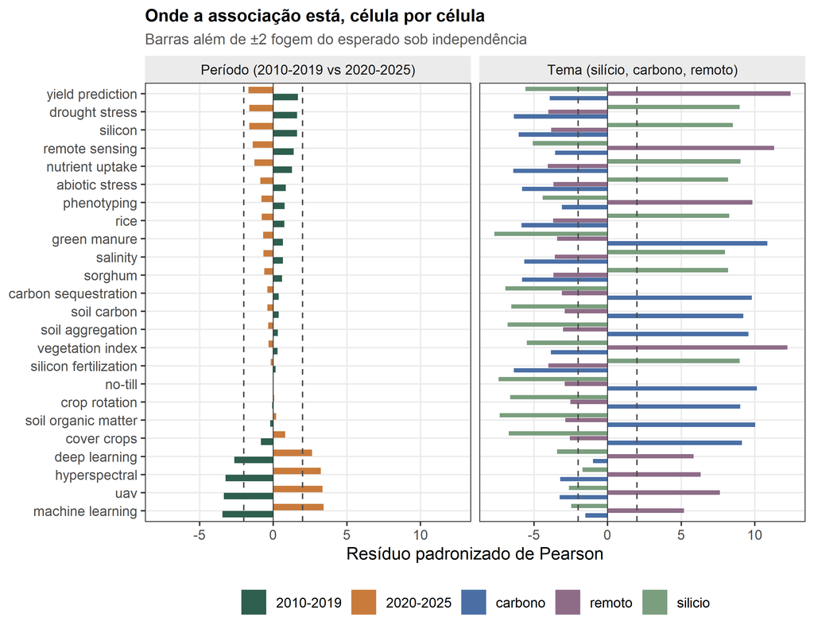

Figura 19: Resíduos padronizados de Pearson por termo, nos dois contrastes. As linhas tracejadas marcam ±2, o limiar convencional para uma célula que foge do esperado sob independência. Termos ordenados pelo resíduo do contraste por período.

```r
# junta os dois contrastes e escolhe a ordem dos termos pelo contraste por periodo
dr <- rbind(
  data.frame(contraste = "Período (2010-2019 vs 2020-2025)", res_per),
  data.frame(contraste = "Tema (silício, carbono, remoto)", res_tema))
dr$grupo <- sub("^factor\\(groups\\)", "", dr$group)
# ordem dos termos pelo residuo do primeiro periodo, para as barras ficarem legiveis
primeiro <- res_per$group[1]
ordem_termos <- res_per$entity[res_per$group == primeiro][order(res_per$residual[res_per$group == primeiro])]
dr$entity <- factor(dr$entity, levels = ordem_termos)
ggplot(dr, aes(x = entity, y = residual, fill = grupo)) +
  geom_col(position = position_dodge(width = .78), width = .72) +
  geom_hline(yintercept = c(-2, 2), linetype = "dashed", colour = "grey30") +
  geom_hline(yintercept = 0, colour = "grey20", linewidth = .3) +
  coord_flip() +
  facet_wrap(~ contraste, ncol = 2) +
  scale_fill_manual(values = pal_agri) +
  labs(x = NULL, y = "Resíduo padronizado de Pearson",
       title = "Onde a associação está, célula por célula",
       subtitle = "Barras além de ±2 fogem do esperado sob independência",
       fill = NULL) +
  theme(legend.position = "bottom")
```

## 10.6 Análise de correspondência: grupos e termos no mesmo plano

A tabela de resíduos responde “onde”, mas não responde “quão perto”. A análise de correspondência resolve isso projetando grupos e termos em um mesmo plano, de modo que a proximidade entre um grupo e um termo signifique que o termo é característico daquele grupo.

```r
ca <- group_ca(cmp_tema)
cat("linhas (grupos):", nrow(ca$rows), " colunas (termos):", nrow(ca$columns), "\n")
```

```
#> linhas (grupos): 3  colunas (termos): 24
```

```r
cat("valores singulares:", paste(round(ca$singular_values, 4), collapse = ", "), "\n")
```

```
#> valores singulares: 0.9491, 0.83, 0
```

```r
cat("inercia total:", round(sum(ca$singular_values^2), 4), "\n")
```

```
#> inercia total: 1.5898
```

```r
# projecao dos grupos: a posicao e o centroide das obras daquele grupo
proj_grupos <- data.frame(
  nome = sub("^factor\\(groups\\)", "", rownames(ca$rows)),
  dim1 = ca$rows[, 1], dim2 = ca$rows[, 2])
knitr::kable(proj_grupos, row.names = FALSE, digits = 3,
             caption = "Coordenadas dos três temas no plano da análise de correspondência (dimensões 1 e 2 da tabela de contingência tema por termo).")
```

Coordenadas dos três temas no plano da análise de correspondência (dimensões 1 e 2 da tabela de contingência tema por termo).

| nome | dim1 | dim2 |
| --- | --- | --- |
| carbono | -1.273 | 0.380 |
| remoto | -0.019 | -1.860 |
| silicio | 0.850 | 0.364 |

A figura Figura 20 projeta grupos e termos juntos. Como os valores singulares decrescem (0.949 e 0.83) mas o terceiro é praticamente nulo, dois eixos bastam para representar a estrutura: com três grupos, a tabela tem no máximo duas dimensões de associação genuína, e a terceira é ruído numérico.

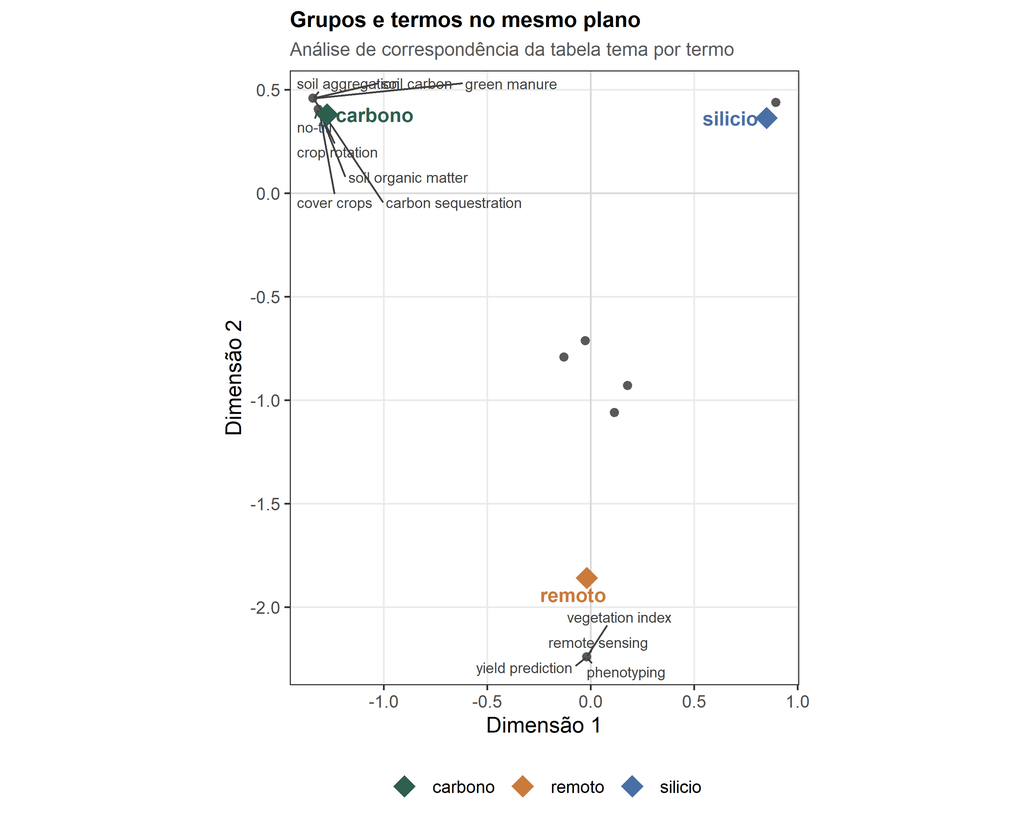

Figura 20: Mapa de correspondência do contraste por tema: os três grupos (losangos) e os 24 termos (círculos) no mesmo plano. Só os termos mais extremos estão rotulados, para não sobrecarregar a figura. A proximidade entre grupo e termo indica vocabulário característico.

```r
termos_plano <- data.frame(
  nome = rownames(ca$columns), dim1 = ca$columns[, 1], dim2 = ca$columns[, 2],
  dist = sqrt(ca$columns[, 1]^2 + ca$columns[, 2]^2))
# rotula os doze termos mais distantes da origem, que sao os que caracterizam os grupos
rotular <- termos_plano$nome[order(-termos_plano$dist)][1:12]
termos_plano$rotulo <- ifelse(termos_plano$nome %in% rotular, termos_plano$nome, NA)
ggplot() +
  geom_hline(yintercept = 0, colour = "grey85") +
  geom_vline(xintercept = 0, colour = "grey85") +
  geom_point(data = termos_plano, aes(x = dim1, y = dim2), colour = "grey35", size = 1.7) +
  ggrepel::geom_text_repel(data = termos_plano, aes(x = dim1, y = dim2, label = rotulo),
                           size = 2.6, colour = "grey25", na.rm = TRUE,
                           seed = SEED, max.overlaps = 30, min.segment.length = 0) +
  geom_point(data = proj_grupos, aes(x = dim1, y = dim2, colour = nome),
             shape = 18, size = 5) +
  ggrepel::geom_text_repel(data = proj_grupos, aes(x = dim1, y = dim2, label = nome, colour = nome),
                           size = 3.5, fontface = "bold", seed = SEED) +
  scale_colour_manual(values = pal_agri) +
  labs(x = "Dimensão 1", y = "Dimensão 2", colour = NULL,
       title = "Grupos e termos no mesmo plano",
       subtitle = "Análise de correspondência da tabela tema por termo") +
  coord_equal()
```

A leitura da figura Figura 20 é imediata e vale como teste visual do que os resíduos já disseram. Os três losangos formam um triângulo no plano, e cada um atrai os seus próprios termos: `soil carbon`, `soil organic matter` e `green manure` pousam à esquerda, junto do losango de carbono; `remote sensing`, `vegetation index` e `yield prediction` descem para a base do gráfico, junto do losango de remoto; e o losango de silício fica isolado à direita, com os seus termos. Note que o eixo vertical é que separa remoto dos demais: os termos de sensoriamento têm coordenada 2 fortemente negativa, e é essa a dimensão de contraste que o algoritmo encontrou. Os termos de silício e de carbono, por sua vez, separam-se na horizontal.

A distância entre os centros dos grupos é a versão gráfica do V de Cramér de 0.892: grupos distantes no plano produzem associação forte. Faça o mesmo exercício com `group_ca(cmp_per)` e você verá os dois períodos praticamente sobrepostos, com os termos de automação como a única estrutura visível — o V de 0.21 desenhado.

## 10.7 Quantas dimensões a estrutura tem: MCA e a leitura do scree

A análise de correspondência múltipla (MCA) generaliza o exercício anterior para várias variáveis ao mesmo tempo: em vez de uma tabela de grupos por termos, ela trata cada termo como uma variável binária e mede quanta estrutura existe em cada dimensão. O valor diagnóstico está na **distribuição** da variância, não no primeiro componente.

```r
mca_tema <- group_mca(x_analise, g_tema, entity = "keyword")
mca_per <- group_mca(x_analise, g_per, entity = "keyword", ncp = 3)
eig_tema <- as.data.frame(mca_tema$eig)
# os nomes das colunas vem do FactoMineR e tem espacos: guardamos os valores
# em vetores de nome simples para poder interpolar na prosa
mca_var   <- eig_tema[["percentage of variance"]]
mca_var_cum <- eig_tema[["cumulative percentage of variance"]]
eig_tema$dimensao <- rownames(mca_tema$eig)
knitr::kable(eig_tema[, c("dimensao", "eigenvalue", "percentage of variance", "cumulative percentage of variance")],
             row.names = FALSE, digits = 2,
             caption = "Autovalores da análise de correspondência múltipla do contraste por tema: variância explicada por dimensão e acumulada.")
cat("MCA do contraste por periodo, dimensoes 1 a", nrow(mca_per$eig), ":\n")
```

```
#> MCA do contraste por periodo, dimensoes 1 a 3 :
```

```r
print(round(as.data.frame(mca_per$eig)[, c("eigenvalue", "percentage of variance")], 3))
```

```
#>       eigenvalue percentage of variance
#> dim 1      0.198                 19.783
#> dim 2      0.141                 14.081
#> dim 3      0.087                  8.704
```

Tabela 31: Autovalores da análise de correspondência múltipla do contraste por tema: variância explicada por dimensão e acumulada.

| dimensao | eigenvalue | percentage of variance | cumulative percentage of variance |
| --- | --- | --- | --- |
| dim 1 | 0.25 | 25.22 | 25.22 |
| dim 2 | 0.18 | 18.05 | 43.26 |

A dimensão 1 explica 25.2% da variância e a dimensão 2, 18%, somando 43.3% nas duas primeiras. Esse número é o que surpreende quem espera encontrar muita estrutura num acervo de 280 obras: menos da metade da variância cabe em duas dimensões. A interpretação correta **não** é que a análise fracassou. Como todas as variáveis são termos raros (a maioria aparece em menos de 30% das obras), a MCA tem muitas dimensões com pouca variância cada uma, e isso é a assinatura de um conjunto de variáveis binárias esparsas. A estrutura real está na cauda curta: as primeiras dimensões concentram a associação entre temas e vocabulário, e a cauda longa é ruído de termos que aparecem em poucas obras.

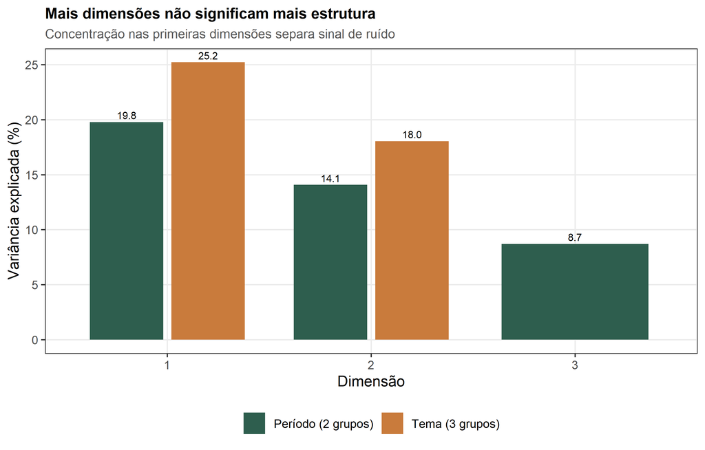

Figura 21: Percentual de variância explicada por dimensão na análise de correspondência múltipla, nos contrastes por tema e por período. A leitura correta é pela forma da distribuição, não pelo valor da primeira barra.

```r
dados_mca <- rbind(
  data.frame(contraste = "Tema (3 grupos)", dimensao = seq_len(nrow(mca_tema$eig)),
             variancia = mca_tema$eig[, "percentage of variance"]),
  data.frame(contraste = "Período (2 grupos)", dimensao = seq_len(nrow(mca_per$eig)),
             variancia = mca_per$eig[, "percentage of variance"]))
ggplot(dados_mca, aes(x = factor(dimensao), y = variancia, fill = contraste)) +
  geom_col(position = position_dodge(width = .8), width = .72) +
  geom_text(aes(label = sprintf("%.1f", variancia)),
            position = position_dodge(width = .8), vjust = -0.4, size = 2.6) +
  scale_fill_manual(values = pal_agri) +
  labs(x = "Dimensão", y = "Variância explicada (%)", fill = NULL,
       title = "Mais dimensões não significam mais estrutura",
       subtitle = "Concentração nas primeiras dimensões separa sinal de ruído") +
  theme(legend.position = "bottom")
```

A figura Figura 21 pede uma leitura em duas etapas. Primeiro, a concentração: a dimensão 1 do contraste por tema explica 25.2% contra 18% da última dimensão mostrada — há hierarquia clara. Segundo, a comparação entre contrastes: o contraste por período tem dimensões iniciais **mais fracas** que o contraste por tema, o que é a mesma informação do V de Cramér lida de outro ângulo. A armadilha que a figura previne é a leitura ingênua de “a análise só explicou 25%”, que levaria o leitor a descartar um resultado real: em MCA de variáveis binárias esparsas, 25% na primeira dimensão é bastante.

## 10.8 Sensibilidade: o resultado sobrevive a outras regras de corte

Um achado só merece crédito se não depender de uma decisão arbitrária do pesquisador. No vocabulário, a decisão arbitrária óbvia é **quanto um termo precisa ser frequente para entrar na análise**. `sensitivity_analysis()` repete a inferência com limiares crescentes e devolve, para cada limiar, quantos termos sobraram, o V de Cramér e o p-valor.

```r
sens <- sensitivity_analysis(x_analise, g_per, thresholds = 1:3,
                             permutations = 199, seed = SEED)
# limiar extremo: serve para medir o limite do proprio metodo de sensibilidade
sens_extremo <- sensitivity_analysis(x_analise, g_per, thresholds = 50,
                                     permutations = 199, seed = SEED)
# a mesma grade com mais permutacoes, para mostrar o que o p-valor faz quando
# ele deixa de empatar no minimo alcancavel
sens_499 <- sensitivity_analysis(x_analise, g_per, thresholds = 1:3,
                                 permutations = 499, seed = SEED)
knitr::kable(sens, row.names = FALSE, digits = 4,
             caption = "Sensibilidade do contraste por período ao limiar de frequência mínima do termo: número de termos restantes, V de Cramér e p-valor por permutação.")
```

Tabela 32: Sensibilidade do contraste por período ao limiar de frequência mínima do termo: número de termos restantes, V de Cramér e p-valor por permutação.

| threshold | entities | cramers_v | p_value |
| --- | --- | --- | --- |
| 1 | 24 | 0.2101 | 0.005 |
| 2 | 24 | 0.2101 | 0.005 |
| 3 | 24 | 0.2101 | 0.005 |

Os três limiares testados deixam 24 termos — ou seja, todos os 24 sobrevivem a um corte de três obras —, o V é exatamente 0.2101 nos três, e o p-valor também não se move: 0.005 em toda a grade. Como esse é justamente o menor p-valor alcançável com 199 permutações, a leitura correta é que o acaso não produziu, em nenhum dos três testes, associação tão forte quanto a observada. A **estabilidade** desses números é a informação que se procura: quando o resultado não se move ao longo de uma grade razoável de limiares, ele é uma propriedade do acervo, não do ponto de corte escolhido.

A instabilidade significaria o contrário, e vale saber reconhecê-la. Se o V oscilasse de 0,10 a 0,40 entre limiares, a conclusão dependeria de uma decisão que o autor tomou sem justificar, e o achado deveria ser rebaixado a “exploratório” até que uma regra fosse fixada **a priori**. Vale notar também um detalhe de leitura dos p-valores: eles são os mesmos nos três limiares porque o qui-quadrado observado é o mesmo e nenhum dos reembaralhamentos o alcançou. Repetindo a análise com mais permutações, os três p-valores deixam de ser idênticos — com `permutations = 499` eles passam a 0.002, 0.006, 0.008 —, e a diferença entre eles é ruído de reamostragem, não sinal.

O teste tem limites, e é honesto medi-los. Empurrando o limiar até o extremo, o número de termos cai: com `thresholds = 50` restam 14 termos e o V passa a 0.2091. Com um limiar alto demais o que se testa é outro contraste, sobre outro vocabulário, e a estabilidade deixa de ser uma notícia. A regra prática é varrer limiares que ainda preservem os termos substantivos da pergunta.

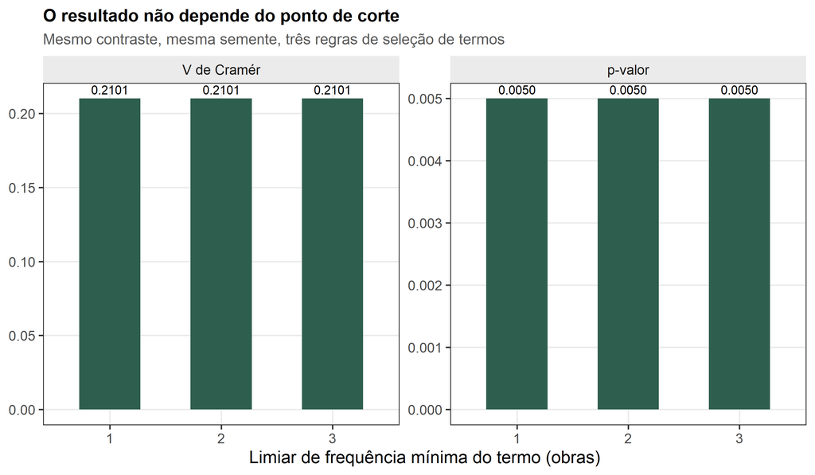

```r
sens_longo <- rbind(
  data.frame(limiar = sens$threshold, medida = "V de Cramér", valor = sens$cramers_v),
  data.frame(limiar = sens$threshold, medida = "p-valor", valor = sens$p_value))
sens_longo$medida <- factor(sens_longo$medida, levels = c("V de Cramér", "p-valor"))
ggplot(sens_longo, aes(x = factor(limiar), y = valor)) +
  geom_col(fill = pal_agri[1], width = .55) +
  geom_text(aes(label = sprintf("%.4f", valor)), vjust = -0.45, size = 2.8) +
  facet_wrap(~ medida, scales = "free_y") +
  labs(x = "Limiar de frequência mínima do termo (obras)",
       y = NULL,
       title = "O resultado não depende do ponto de corte",
       subtitle = "Mesmo contraste, mesma semente, três regras de seleção de termos")
```

A figura Figura 22 é o que se põe no material suplementar de um artigo. A leitura é que as três barras de cada painel são indistinguíveis entre si e também indistinguíveis do valor pontual do contraste completo. No caso do V, a precisão do método é o erro-padrão aproximado de 0.0285 calculado para 1228 pares obra-termo, e as três barras cabem dentro dessa precisão. Não há tendência sistemática de alta ou queda ao longo dos limiares, e é a ausência de tendência, e não a igualdade exata, que constitui a evidência de robustez — a igualdade exata das barras é consequência de o limiar não ter removido nenhum termo, como discutimos.

## 10.9 Cobertura e sobreposição entre bases

O último uso da comparação de grupos não é entre temas, e sim entre **fontes**. Quem faz revisão sistemática exporta o mesmo acervo de três bases diferentes e precisa responder quanto cada base cobre e quanto elas se sobrepõem, porque é desse número que sai a justificativa do esforço de busca.

```r
cs <- compare_sources(corpus_analitico = x_analise, acervo_didatico = x_did)
knitr::kable(cs$coverage, row.names = FALSE,
             caption = "Cobertura de cada base: total de registros e registros distintos segundo a chave de identificação do pacote.")
knitr::kable(cs$overlap, row.names = FALSE,
             caption = "Sobreposição entre as bases: número de obras presentes simultaneamente nas duas.")
```

Tabela 33: Sobreposição entre as bases: número de obras presentes simultaneamente nas duas.

| source | records | unique |
| --- | --- | --- |
| corpus_analitico | 280 | 280 |
| acervo_didatico | 12 | 12 |

| source1 | source2 | intersection |
| --- | --- | --- |
| corpus_analitico | acervo_didatico | 0 |

A tabela de cobertura mostra 280 registros na primeira base e 12 na segunda, todos distintos dentro de cada base (`unique` igual a `records`). A sobreposição é de 0 obra — as duas bases não compartilham nada, o que faz sentido aqui porque uma é simulada e a outra é o acervo didático do pacote. O exercício ganha sentido quando as bases vêm do mesmo domínio: rode `compare_sources(scopus = ..., wos = ..., openalex = ...)` com as suas exportações e a coluna `intersection` dirá quantas obras você encontraria buscando só numa delas. Para revisão sistemática, essa é a evidência de que a segunda base acrescenta material novo e não apenas trabalho de triagem.

O nome das bases vem do nome dos argumentos, e é por isso que a chamada acima usa nomes em vez de posições. Sem nomes, o pacote rotula as colunas como `source1` e `source2`, e a tabela deixa de ser autoexplicativa. Vale também registrar um comportamento que surpreende: a função foi escrita para comparar **pelo menos duas** bases, e a chamada com uma só falha.

```r
erro_mensagem <- function(expr) {
  # helper local: devolve a mensagem de erro como texto, para poder imprimi-la
  tryCatch({ force(expr); "(nenhum erro)" }, error = function(e) conditionMessage(e))
}
cat("compare_sources com uma base apenas:\n")
```

```
#> compare_sources com uma base apenas:
```

```r
cat("  ", erro_mensagem(compare_sources(apenas_uma = x_analise)), "\n")
```

```
#>    n < m
```

A mensagem `n < m` vem de dentro do `combn()` que enumera os pares, e não diz nada ao usuário sobre o que fazer. A consequência prática é pequena — comparar uma base com nada não é uma análise —, mas quem tenta usar a função para conferir a contagem de registros de um único acervo perde tempo até perceber. A conferência de um acervo só se faz por outras vias, como `nrow(x$works)`.

## 10.10 Grupos que se cruzam: o que `$overlap` significa

Toda a discussão anterior usou grupos disjuntos: cada obra pertence a um período e a um tema, e a nenhum outro. Mas os grupos que interessam em agronomia raramente são assim. Uma obra pode estar publicada em uma revista de solo **e** tratar de silício; um experimento pode ser de sequeiro **e** de cobertura morta. Construa dois grupos que se cruzam de fato, um definido pelo periódico e outro pelo tema do título.

```r
# grupo A: obras nas duas revistas que o corpus B trata com bonus de citacao
fonte_bonus <- x_analise$works$source %in%
  c("Field Crops Research", "Soil Biology & Biochemistry")
# grupo B: obras cujo titulo e da frente de silicio
silicio <- grepl("^Silício", x_analise$works$title)
g_cruz <- form_groups(x_analise, cbind(revista_bonus = fonte_bonus, silicio = silicio))

cat("obras nas revistas A:", sum(fonte_bonus), "\n")
```

```
#> obras nas revistas A: 66
```

```r
cat("obras no tema silicio:", sum(silicio), "\n")
```

```
#> obras no tema silicio: 139
```

```r
cat("obras nos DOIS grupos:", sum(fonte_bonus & silicio), "\n")
```

```
#> obras nos DOIS grupos: 35
```

```r
cat("obras so em A:", sum(fonte_bonus & !silicio), "| so em B:", sum(silicio & !fonte_bonus),
    "| em nenhum:", sum(!fonte_bonus & !silicio), "\n")
```

```
#> obras so em A: 31 | so em B: 104 | em nenhum: 110
```

```r
cat("linhas com mais de um grupo:", sum(rowSums(g_cruz) > 1), "\n\n")
```

```
#> linhas com mais de um grupo: 35
```

```r
cmp_cruz <- compare_groups(x_analise, g_cruz, entity = "keyword",
                           permutations = 499, seed = SEED)
cat("campo overlap do resultado:", cmp_cruz$overlap, "\n")
```

```
#> campo overlap do resultado: TRUE
```

```r
cat("qui-quadrado:", round(cmp_cruz$chi_square, 1), "| p:", cmp_cruz$p_value,
    "| V:", round(cmp_cruz$cramers_v, 3), "\n")
```

```
#> qui-quadrado: 282.5 | p: 0.002 | V: 0.557
```

```r
cat("linhas da tabela observada:", paste(rownames(cmp_cruz$observed), collapse = " | "), "\n")
```

```
#> linhas da tabela observada: revista_bonus | silicio
```

Aqui 35 obras pertencem aos dois grupos ao mesmo tempo: publicadas nas revistas de bônus e sobre silício. É esse o sentido do campo `$overlap = TRUE` — existe pelo menos uma obra com mais de um rótulo. Nos contrastes por período e por tema, o campo devolveu `FALSE` porque cada obra recebia exatamente um rótulo. Nem sempre é assim, e o pacote não trata a sobreposição como erro: trata como a situação normal.

O cruzamento não invalida a inferência, mas obriga a escolher a hipótese nula com cuidado. Se a obra que está nos dois grupos fosse contada duas vezes, ela entraria duas vezes na estatística e inflaria a associação. O pacote evita isso montando **uma linha por obra** com todas as suas colunas de pertencimento, de modo que cada obra pesa uma vez em cada grupo, e nunca duas vezes no total. A figura seguinte decompõe os grupos.

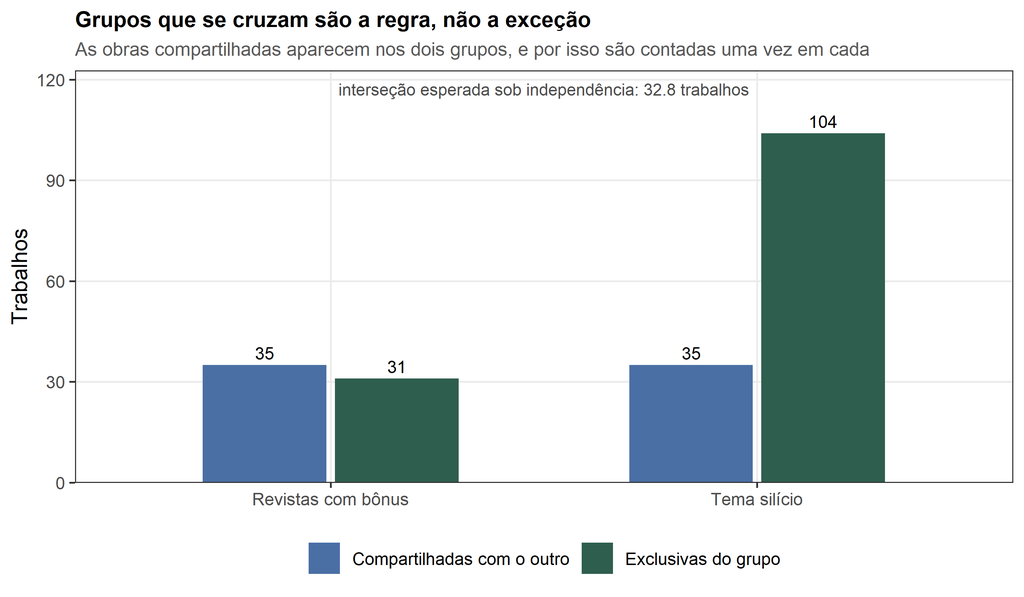

Figura 23: Decomposição dos dois grupos que se cruzam. Cada par de barras mostra quantas obras do grupo são exclusivas dele e quantas são compartilhadas com o outro grupo.

```r
# o que a independencia entre os dois rotulos preveria para a intersecao
esperado_cruz <- sum(fonte_bonus) * sum(silicio) / nrow(g_cruz)
estrutura <- data.frame(
  grupo = rep(c("Revistas com bônus", "Tema silício"), each = 2),
  parte = rep(c("Exclusivas do grupo", "Compartilhadas com o outro"), 2),
  trabalhos = c(sum(fonte_bonus & !silicio), sum(fonte_bonus & silicio),
                sum(silicio & !fonte_bonus), sum(silicio & fonte_bonus)))
ggplot(estrutura, aes(x = grupo, y = trabalhos, fill = parte)) +
  geom_col(position = position_dodge(width = .62), width = .58) +
  geom_text(aes(label = trabalhos), position = position_dodge(width = .62),
            vjust = -0.45, size = 3.1) +
  annotate("text", x = 1.5, y = Inf, vjust = 2, size = 3, colour = "grey30",
           label = sprintf("interseção esperada sob independência: %.1f trabalhos", esperado_cruz)) +
  scale_fill_manual(values = c(pal_agri[3], pal_agri[1])) +
  scale_y_continuous(expand = expansion(mult = c(0, .18))) +
  labs(x = NULL, y = "Trabalhos", fill = NULL,
       title = "Grupos que se cruzam são a regra, não a exceção",
       subtitle = "As obras compartilhadas aparecem nos dois grupos, e por isso são contadas uma vez em cada") +
  theme(legend.position = "bottom")
```

A figura Figura 23 fecha o argumento, e a leitura tem duas partes. A primeira é a existência da interseção: 35 obras aparecem nas duas barras, e é isso que o campo `$overlap` sinaliza. A segunda é a magnitude, e aqui o resultado desmente a expectativa. A razão entre a interseção observada e a esperada sob independência é de 1.07 — ou seja, **exatamente o que o azar produziria**. A conta fica evidente quando escrita como proporção: 23.6% do acervo está nas duas revistas com bônus e 49.6% é de silício; se os dois rótulos fossem independentes, a interseção esperada seria o produto dessas duas proporções, 11.7% do acervo, ou 32.8 obras. A interseção observada é de 12.5% do acervo. A figura mostra as duas barras de cada grupo lado a lado, e o valor de referência no alto do gráfico é o que a independência previria.

O que isso ensina é a separar três perguntas que se confundem com facilidade. A primeira, “os dois rótulos se cruzam?”, se responde com 35 obras e com o campo `$overlap`. A segunda, “o cruzamento é maior que o esperado?”, se responde comparando a interseção com 32.8 e, aqui, a resposta é não. A terceira, “o vocabulário depende dos grupos?”, se responde com o V de Cramér, que neste contraste vale 0.557 e é forte — e essa associação forte **não** vem do cruzamento, e sim da composição temática das duas revistas, que publicam sobretudo trabalho de solo. Um leitor apressado olharia o V de 0.557, veria `$overlap = TRUE` e escreveria que a sobreposição entre periódico e tema explica o vocabulário. A conferência da interseção contra o valor esperado mostra que a explicação está na composição de cada grupo, e não no cruzamento.

O ponto final é **o que o pacote faz com a sobreposição na hora de reembaralhar**, e a resposta está no código de `compare_groups()`: o reembaralhamento permuta **linhas inteiras** da matriz de pertencimento.

```r
# reconstruimos o mecanismo do pacote para ele ficar visivel
# a semente fixa garante que o passo a passo a seguir seja sempre o mesmo
set.seed(SEED)
# o numero de obras com os dois rotulos no acervo inteiro, antes de reembaralhar
cat("obras com os dois rotulos no acervo:", sum(rowSums(g_cruz) > 1), "\n\n")
```

```
#> obras com os dois rotulos no acervo: 35
```

```r
# um reembaralhamento unico, completo, como o pacote faz em cada permutacao
gp <- g_cruz[sample.int(nrow(g_cruz)), , drop = FALSE]
cat("obras com os dois rotulos depois de reembaralhar:", sum(rowSums(gp) > 1), "\n")
```

```
#> obras com os dois rotulos depois de reembaralhar: 35
```

```r
cat("tamanho dos grupos antes:", paste(colSums(g_cruz), collapse = " e "),
    "| depois:", paste(colSums(gp), collapse = " e "), "\n\n")
```

```
#> tamanho dos grupos antes: 66 e 139 | depois: 66 e 139
```

```r
# a assinatura do mecanismo esta na frequencia dos quatro padroes de pertencimento
padroes <- function(m) table(apply(m, 1, paste, collapse = ""))
cat("frequencia dos padroes de pertencimento (0/1 por grupo):\n")
```

```
#> frequencia dos padroes de pertencimento (0/1 por grupo):
```

```r
cat("antes do reembaralhamento:", paste(names(padroes(g_cruz)), padroes(g_cruz), sep = "=", collapse = "  "), "\n")
```

```
#> antes do reembaralhamento: 00=110  01=104  10=31  11=35
```

```r
cat("depois do reembaralhamento:", paste(names(padroes(gp)), padroes(gp), sep = "=", collapse = "  "), "\n\n")
```

```
#> depois do reembaralhamento: 00=110  01=104  10=31  11=35
```

```r
# e o detalhe que explica por que isso acontece: cada linha viaja inteira
cat("as seis primeiras posicoes do acervo, antes:\n")
```

```
#> as seis primeiras posicoes do acervo, antes:
```

```r
print(unname(g_cruz[1:6, , drop = FALSE]))
```

```
#>      [,1] [,2]
#> [1,]    0    0
#> [2,]    0    0
#> [3,]    0    1
#> [4,]    0    1
#> [5,]    1    0
#> [6,]    0    1
```

```r
cat("as mesmas seis posicoes, depois do reembaralhamento:\n")
```

```
#> as mesmas seis posicoes, depois do reembaralhamento:
```

```r
print(unname(gp[1:6, , drop = FALSE]))
```

```
#>      [,1] [,2]
#> [1,]    0    0
#> [2,]    1    1
#> [3,]    1    1
#> [4,]    0    0
#> [5,]    1    1
#> [6,]    1    1
```

A saída mostra a propriedade que a implementação preserva, e ela é exatamente a que se quer. A frequência dos quatro padrões de pertencimento é idêntica antes e depois: 00=110 01=104 10=31 11=35. O número de obras com os dois rótulos continua 35 depois de reembaralhar, e os tamanhos dos dois grupos também não mudam: 66 e 139 antes, os mesmos valores depois. Permutar linhas inteiras mantém cada obra com o seu **conjunto** de rótulos — a linha `1 1` continua sendo `1 1`, apenas atribuída a outra posição do acervo, e por isso o padrão de sobreposição sobrevive intacto.

A alternativa ingênua seria permutar cada coluna de forma independente. Duas coisas mudariam, e as duas são graves. Primeiro, o número de obras pertencentes aos dois grupos deixaria de ser 35 e passaria a variar a cada permutação, de modo que o mecanismo testado seria outro — não mais “reorganize estas obras entre os grupos que elas já formam”, e sim “sorteie rótulos do zero”. Segundo, e pior para a interpretação, a dependência entre os grupos seria destruída: o teste perderia poder justamente quando a sobreposição é a informação de interesse. Com linhas inteiras, a hipótese nula que se testa é precisa e defensável: **os grupos têm os tamanhos e as sobreposições que têm, e o que se reembaralha é a ligação entre pertencer a um grupo e empregar um vocabulário**. É essa ligação, e só ela, que a permutação coloca à prova.

## 10.11 Tarefas do Módulo 6

**Tarefa 6.1 (aplicar).** O acervo analítico traz obras em nove periódicos. Rode `table(x_analise$works$source)` para ver a distribuição e construa **dois** grupos de periódico cujos nomes contenham `"Soil"` e `"Agronomy"`, mantendo as demais obras fora dos dois grupos. Forme a matriz com `form_groups()`, rode `compare_groups()` com `entity = "keyword"`, `permutations = 499` e `seed = SEED` e informe o V de Cramér. Depois use `association_residuals()` com `min_abs = 2` e relate quais termos caracterizam cada grupo de periódico.

**Tarefa 6.2 (analisar).** Rode `sensitivity_analysis()` sobre o contraste por **tema** com `thresholds = c(1, 2, 5, 10)` e `permutations = 199`. Compare o comportamento das colunas `cramers_v`, `p_value` e `entities` com o que foi observado no contraste por período. Em um parágrafo, responda a duas perguntas: o limiar filtra **termos** ou filtra **obras**, e por que a coluna `entities` quase não se move neste acervo mesmo com o limiar em 10?

# 11 Módulo 7. Redes bibliográficas

## 11.1 O problema agronômico

Um programa de pós-graduação precisa decidir em que frente investir. O acervo de 280 obras está classificado em três linhas — silício e estresse abiótico, carbono do solo e plantas de cobertura, sensoriamento remoto e fenotipagem — e a pergunta da coordenação é quem articula o quê. Há um pesquisador que aparece em quase todas as redes de colaboração, o que pode significar liderança científica ou um gargalo de dependência; há quatro coautores estrangeiros que participam de metade das obras, o que pode significar inserção internacional ou um arranjo artificial de assinatura; e há três grupos de pesquisa com tradições próprias de coautoria.

Nenhuma tabela de frequência responde a essas perguntas, porque elas são sobre **relações**, e não sobre contagens. Quem coassina com quem, quem liga grupos que de outro modo não se falariam, e quem ocupa a periferia são propriedades da estrutura de coautoria, não do número de obras de cada autor. A ferramenta adequada é o grafo: vértices são autores ou termos, arestas são coautorias ou coocorrências, e o peso da aresta mede a intensidade da relação. Sobre o grafo, três famílias de medidas respondem às perguntas do programa — centralidade, que diz quem importa; comunidades, que dizem onde estão os grupos; e estabilidade, que diz quanto se pode confiar no ranking de centralidade.

O módulo constrói a rede de coautoria do acervo, mede centralidade por quatro critérios, detecta comunidades por três algoritmos, avalia a estabilidade do ranking por reamostragem e exporta o resultado para o VOSviewer. Ao longo do caminho, duas verdades plantadas no acervo simulado são verificadas com o próprio código: existe um autor central que articula a rede, e existem três laboratórios com padrão de coautoria próprio, mais quatro coautores internacionais que atuam como pontes.

## 11.2 Tipos de rede, motores e a primeira conferência

A função `bibliographic_network()` constrói três tipos de rede a partir do mesmo objeto: `"coauthor"` liga autores que assinam a mesma obra, `"keyword"` liga termos que aparecem na mesma obra e `"citation"` liga obras por citação. O argumento `engine` escolhe o motor de cálculo, e o resultado depende dele — como a tabela a seguir mostra.

```r
g_coauto <- bibliographic_network(x_analise, "coauthor")
g_nativa <- bibliographic_network(x_analise, "coauthor", engine = "native")
g_biblio <- bibliographic_network(x_analise, "coauthor", engine = "biblionetwork")

# o campo engine do objeto registra qual motor foi efetivamente usado
cat("motor efetivo com engine = 'auto':", attr(g_coauto, "engine"), "\n")
```

```
#> motor efetivo com engine = 'auto': biblionetwork
```

```r
cat("motor efetivo com engine = 'native':", attr(g_nativa, "engine"), "\n")
```

```
#> motor efetivo com engine = 'native': native
```

```r
cat("motor efetivo com engine = 'biblionetwork':", attr(g_biblio, "engine"), "\n")
```

```
#> motor efetivo com engine = 'biblionetwork': biblionetwork
```

```r
cat("auto e biblionetwork produzem a mesma rede?",
    identical(igraph::as_data_frame(g_coauto, "edges"),
              igraph::as_data_frame(g_biblio, "edges")), "\n\n")
```

```
#> auto e biblionetwork produzem a mesma rede? TRUE
```

```r
# o motor nativo repete pares de vertices nao ordenados: medimos quantos
pares_de_vertices <- function(g) {
  e <- igraph::as_data_frame(g, "edges")
  # o par (a, b) e o par (b, a) sao o mesmo par de coautores
  chave <- apply(e[, c("from", "to")], 1, function(z) paste(sort(z), collapse = "|"))
  c(arestas = nrow(e), pares_distintos = length(unique(chave)),
    pares_duplicados = nrow(e) - length(unique(chave)))
}
combinacoes_possiveis <- igraph::vcount(g_coauto) * (igraph::vcount(g_coauto) - 1) / 2
motor <- data.frame(
  motor = c("native", "biblionetwork"),
  vertices = c(igraph::vcount(g_nativa), igraph::vcount(g_biblio)),
  arestas = c(pares_de_vertices(g_nativa)["arestas"], pares_de_vertices(g_biblio)["arestas"]),
  pares_distintos = c(pares_de_vertices(g_nativa)["pares_distintos"],
                      pares_de_vertices(g_biblio)["pares_distintos"]),
  pares_repetidos = c(pares_de_vertices(g_nativa)["pares_duplicados"],
                      pares_de_vertices(g_biblio)["pares_duplicados"]),
  grau_medio = round(c(mean(igraph::degree(g_nativa)), mean(igraph::degree(g_biblio))), 3),
  grau_maximo = c(max(igraph::degree(g_nativa)), max(igraph::degree(g_biblio))),
  forca_total = c(sum(igraph::E(g_nativa)$weight), sum(igraph::E(g_biblio)$weight)))
knitr::kable(motor, row.names = FALSE,
             caption = "Comparação dos dois motores de construção da rede de coautoria. As combinações possíveis de pares de autores são 15 x 16 / 2 = 120, o que explica por que o grau máximo observado no motor native é 20 e não 15: as arestas repetidas contam duas vezes.")
```

Comparação dos dois motores de construção da rede de coautoria. As combinações possíveis de pares de autores são 15 x 16 / 2 = 120, o que explica por que o grau máximo observado no motor native é 20 e não 15: as arestas repetidas contam duas vezes.

| motor | vertices | arestas | pares_distintos | pares_repetidos | grau_medio | grau_maximo | forca_total |
| --- | --- | --- | --- | --- | --- | --- | --- |
| native | 16 | 120 | 91 | 29 | 15.000 | 20 | 1106 |
| biblionetwork | 16 | 91 | 91 | 0 | 11.375 | 15 | 1106 |

```r
cat("combinacoes possiveis de pares de autores:", combinacoes_possiveis, "\n")
```

```
#> combinacoes possiveis de pares de autores: 120
```

```r
# o grau calculado pelos dois motores, autor por autor, na mesma ordem de vertices
grau_nativo <- igraph::degree(g_nativa)
grau_limpo <- igraph::degree(g_biblio)[match(igraph::V(g_nativa)$name, igraph::V(g_biblio)$name)]
cat("grau nativo  :", paste(grau_nativo, collapse = ", "), "\n")
```

```
#> grau nativo  : 12, 20, 18, 18, 15, 11, 12, 13, 20, 12, 10, 15, 17, 15, 14, 18
```

```r
cat("grau limpo   :", paste(grau_limpo, collapse = ", "), "\n")
```

```
#> grau limpo   : 9, 15, 15, 15, 11, 8, 9, 11, 15, 9, 8, 10, 10, 11, 11, 15
```

```r
cat("autores cujo grau difere entre os motores:", sum(grau_nativo != grau_limpo), "de", length(grau_nativo), "\n")
```

```
#> autores cujo grau difere entre os motores: 16 de 16
```

```r
# quem lidera o grau em cada motor, para a comparacao da secao de centralidade
ordem_nativa <- order(-igraph::degree(g_nativa), -igraph::strength(g_nativa))
lider_nativo <- x_analise$authors$display_name[
  match(igraph::V(g_nativa)$name[ordem_nativa[1]], x_analise$authors$author_id)]
cat("lider de grau no motor nativo:", lider_nativo, "com grau", max(igraph::degree(g_nativa)), "\n")
```

```
#> lider de grau no motor nativo: Smith J com grau 20
```

A primeira coisa que a saída revela é o comportamento do motor padrão: `engine = "auto"` **não** usa o motor nativo quando o pacote `biblionetwork` está instalado. O objeto resultante registra `attr(g_coauto, "engine")` igual a biblionetwork, e as arestas são idênticas às de `engine = "biblionetwork"`. Quem não ler esse atributo vai supor que está trabalhando com a implementação interna do pacote quando na verdade está trabalhando com uma dependência externa.

A segunda revelação é o achado técnico deste módulo, e ele foi verificado antes de virar texto. O motor nativo devolve 120 arestas, mas apenas 91 **pares de autores distintos**: 29 pares aparecem duas vezes, uma em cada sentido. O próprio total denuncia o problema — há 120 pares possíveis de 16 autores, e o motor nativo usa exatamente esse número. O grafo é completo apenas porque cada par foi contado duas vezes.

A consequência é visível na coluna do grau. No motor nativo o grau médio é 15, e o grau **máximo** é 20, que é impossível em uma rede de 16 vértices: o máximo teórico é 15. Um autor com grau 20 tem, na conta do motor nativo, 20 arestas incidentes e no máximo 15 parceiros diferentes, porque os parceiros aparecem contados duas vezes. O motor `biblionetwork` devolve 91 arestas, 91 pares distintos e grau máximo 15, que é o número correto.

O ponto tranquilizador está nas duas últimas colunas: a **força total** da rede é 1106 nos dois motores, e a conferência autor por autor mostra que a força e o PageRank de cada vértice são **idênticos** entre os motores. O que muda é o grau, a densidade, a intermediação e o peso de cada aresta isolada — o grafo nativo tem 91 pares de coautores, mas distribui o peso de 29 pares entre duas linhas, e o peso de cada linha fica diferente do peso do par. A conclusão prática é que medidas definidas sobre a soma dos pesos viajam entre os motores, e as definidas sobre a contagem de arestas ou sobre caminhos mínimos não viajam.

**ImportanteQuais medidas mudam de motor**

Sempre que você comparar redes de coautoria construídas por `engine = "native"` com redes de `engine = "biblionetwork"`, verifique se a medida que você vai relatar sobrevive à troca. Neste acervo, **força** e **PageRank** de cada autor são idênticos nos dois motores, enquanto **grau**, **densidade**, **intermediação** e o **peso de cada aresta** diferem, porque a versão nativa repete 29 pares de autores em duas linhas. Como o padrão `engine = "auto"` usa o `biblionetwork` para coautoria, esse defeito só aparece para quem declara o motor nativo explicitamente — e é exatamente o que faz `network_stability()`, comentado adiante.

```r
# o efeito de min_weight na rede de palavras-chave, que nao tem pares repetidos
pesos <- do.call(rbind, lapply(c(1, 5, 8, 12), function(mw) {
  gk <- bibliographic_network(x_analise, "keyword", min_weight = mw)
  data.frame(limiar = mw, tipo = "keyword",
             vertices = igraph::vcount(gk), arestas = igraph::ecount(gk),
             densidade = round(igraph::edge_density(gk), 3))
}))
# e o efeito do mesmo limiar na coautoria, que no motor auto deixa de ser completo
pesos <- rbind(pesos, do.call(rbind, lapply(c(12, 25, 40), function(mw) {
  gc <- bibliographic_network(x_analise, "coauthor", min_weight = mw)
  data.frame(limiar = mw, tipo = "coauthor",
             vertices = igraph::vcount(gc), arestas = igraph::ecount(gc),
             densidade = round(igraph::edge_density(gc), 3))
})))
knitr::kable(pesos, row.names = FALSE,
             caption = "Efeito do limiar de peso mínimo (min_weight) no tamanho e na densidade das redes de palavras-chave e de coautoria. A rede de coautoria usa o motor biblionetwork.")
```

Tabela 34: Efeito do limiar de peso mínimo (min_weight) no tamanho e na densidade das redes de palavras-chave e de coautoria. A rede de coautoria usa o motor biblionetwork.

| limiar | tipo | vertices | arestas | densidade |
| --- | --- | --- | --- | --- |
| 1 | keyword | 24 | 234 | 0.848 |
| 5 | keyword | 24 | 197 | 0.714 |
| 8 | keyword | 24 | 135 | 0.489 |
| 12 | keyword | 18 | 68 | 0.444 |
| 12 | coauthor | 11 | 35 | 0.636 |
| 25 | coauthor | 11 | 13 | 0.236 |
| 40 | coauthor | 6 | 4 | 0.267 |

A tabela mostra o que o limiar faz, e as duas linhas de leitura são diferentes. Na rede de palavras-chave, que começa com 234 arestas e densidade 0.848, o limiar é a ferramenta de legibilidade: com `min_weight = 8` a densidade cai para 0.489 e a rede passa a mostrar apenas os pares de termos que realmente andam juntos. Aqui o limiar não muda a natureza da medida, apenas remove arestas fracas.

Na rede de coautoria acontece outra coisa, e é o segundo achado do módulo. Como o grafo é pequeno e a maioria dos pares tem peso baixo, subir o limiar **apaga vértices**: com `min_weight = 12` sobram 11 autores, com `min_weight = 25` sobram 11, e com `min_weight = 40` restam 6. A densidade de 0.267 no caso mais extremo não é uma propriedade do acervo, e sim um efeito do corte: a rede filtrada é um subgrafo com outros vértices, e as medidas calculadas sobre ela descrevem outro objeto. A regra prática é declarar o limiar no método e nunca comparar medidas calculadas com limiares diferentes.

**AvisoO tipo “citation” não roda neste acervo**

`bibliographic_network(x_analise, "citation")` falha com `arguments imply differing number of rows: 0, 1`. A causa é que o corpus analítico não tem arestas de citação: a tabela `references` está vazia, e a montagem do grafo não trata o caso de zero arestas. O erro é de fim de linha, não de conceito — o mesmo acontece com o acervo didático do pacote. Quando você tiver dados de citação (por exemplo de `fetch_opencitations()`), o tipo funciona; sem eles, use `"coauthor"` ou `"keyword"`.

## 11.3 Centralidade: o hub plantado e a diferença entre grau e intermediação

`network_centrality()` devolve quatro medidas por vértice. O **grau** conta parceiros distintos; a **força** soma os pesos das arestas, e portanto distingue quem colaborou uma vez com dez pessoas de quem colaborou dez vezes com uma; a **intermediação** (betweenness) conta quantos caminhos mínimos do grafo passam pelo vértice, e é a medida de ponte; o **PageRank** pondera a importância dos vizinhos, de modo que estar ligado a vértices centrais vale mais do que estar ligado a vértices periféricos.

Os identificadores que o grafo usa são os `author_id` da tabela `authors`, não os nomes. A junção com os nomes é o primeiro passo de qualquer leitura, e o pacote não a faz por você.

```r
centro <- network_centrality(g_coauto)
autores <- x_analise$authors[, c("author_id", "display_name")]
centro <- merge(centro, autores, by.x = "node", by.y = "author_id", all.x = TRUE)
# posicao em cada criterio, para comparar os rankings na mesma tabela
centro$posto_grau <- rank(-centro$degree, ties.method = "min")
centro$posto_forca <- rank(-centro$strength, ties.method = "min")
centro$posto_betweenness <- rank(-centro$betweenness, ties.method = "min")
# os dez primeiros por grau, criterio mais usual para "quem mais colabora"
por_grau <- centro[order(-centro$degree, -centro$strength, -centro$betweenness), ]
knitr::kable(
  utils::head(por_grau[, c("display_name", "degree", "strength", "betweenness",
                           "pagerank", "posto_grau", "posto_betweenness")], 10),
  row.names = FALSE, digits = c(0, 0, 0, 3, 4, 0, 0),
  col.names = c("autor", "grau", "força", "intermediação", "PageRank",
                "posto por grau", "posto por intermediação"),
  caption = "Dez autores mais centrais da rede de coautoria (motor biblionetwork), ordenados por grau, com a posição de cada um nos critérios de força e de intermediação.")

cat("maior grau:", max(centro$degree), "| maior força:", max(centro$strength),
    "| maior intermediação:", round(max(centro$betweenness), 4), "\n")
```

```
#> maior grau: 15 | maior força: 341 | maior intermediação: 0.4095
```

```r
cat("autores com o maior grau:", sum(centro$degree == max(centro$degree)), "\n")
```

```
#> autores com o maior grau: 5
```

```r
cat("autores com intermediação zero:", sum(centro$betweenness == 0), "de", nrow(centro), "\n")
```

```
#> autores com intermediação zero: 9 de 16
```

```r
cat("autor de maior grau, força e intermediação:",
    centro$display_name[which.max(centro$degree + centro$strength + centro$betweenness)], "\n")
```

```
#> autor de maior grau, força e intermediação: Silva AP
```

```r
# quantos autores trocam de posicao quando o criterio muda de grau para intermedicao
cat("autores cuja posicao difere entre grau e intermediação:",
    sum(centro$posto_grau != centro$posto_betweenness), "de", nrow(centro), "\n")
```

```
#> autores cuja posicao difere entre grau e intermediação: 15 de 16
```

```r
cat("maior diferenca de posto entre os dois criterios:",
    max(abs(centro$posto_grau - centro$posto_betweenness)), "posicoes\n")
```

```
#> maior diferenca de posto entre os dois criterios: 7 posicoes
```

Tabela 35: Dez autores mais centrais da rede de coautoria (motor biblionetwork), ordenados por grau, com a posição de cada um nos critérios de força e de intermediação.

| autor | grau | força | intermediação | PageRank | posto por grau | posto por intermediação |
| --- | --- | --- | --- | --- | --- | --- |
| Silva AP | 15 | 341 | 0.410 | 0.1348 | 1 | 1 |
| Smith J | 15 | 176 | 0.314 | 0.0786 | 1 | 2 |
| Rossi G | 15 | 165 | 0.000 | 0.0730 | 1 | 8 |
| Chen L | 15 | 159 | 0.067 | 0.0710 | 1 | 4 |
| Müller H | 15 | 148 | 0.000 | 0.0670 | 1 | 8 |
| Oliveira TN | 11 | 157 | 0.095 | 0.0684 | 6 | 3 |
| Nunes PR | 11 | 65 | 0.019 | 0.0394 | 6 | 5 |
| Barbosa KS | 11 | 64 | 0.019 | 0.0400 | 6 | 5 |
| Rocha MV | 11 | 59 | 0.010 | 0.0379 | 6 | 7 |
| Pereira WE | 10 | 187 | 0.000 | 0.0754 | 10 | 8 |

A Tabela confirma a verdade plantada. O autor plantado como hub no gerador do acervo lidera os três critérios ao mesmo tempo: 15 parceiros no grau máximo, 341 na força e 0.41 na intermediação, todos em **Silva AP**. Há uma sutileza que a leitura apressada perde: 5 autores empatam no grau máximo, e o desempate só acontece quando se olha a força ou a intermediação. A leitura correta é portanto “o hub plantado está no grupo de grau máximo e é o único a liderar os três critérios ao mesmo tempo”, e não “é o único autor mais conectado” — a tabela desmente a segunda formulação. Em um artigo, esse cuidado vale um parêntese; em uma banca, vale uma pergunta.

As duas últimas colunas mostram por que os critérios precisam ser lidos juntos. O posto por grau e o posto por intermediação diferem para 15 dos 16 autores, e a maior diferença de posição entre os dois critérios é de 7 lugares. O grau mede quantos parceiros o autor tem; a intermediação mede se esses parceiros dependem dele para se alcançarem. São perguntas diferentes sobre o mesmo grafo.